# SalesforEconomyDataAnalysis

Malay Raj

2023-09-19

## SALES FOR ECONOMY DATA ANALYSIS :

The dataset contains information about sales transactions, including details such as the customer’s age, gender, location, and the products sold.

## Loading Required Packages.

```r
library(tidyverse)
library(janitor)
```

```r
library(dplyr)
library(ggplot2)
library(skimr)
library(plyr)
library(lubridate)
library(scales)
library(plotly)
library(data.table)
```

## Displaying my current working directory.

```r
getwd()
```

```
## [1] "C:/Sales Data for Economy Data Analysis"
```

## Collecting the data.

```r
sales = read.csv("C:/Sales Data for Economy Data Analysis/salesforcourse-4fe2kehu.csv")
```

## Displaying the first six rows of dataset.

```r
head(sales)
```

```
##   index      Date Year    Month Customer.Age Customer.Gender       Country
## 1     0 2/19/2016 2016 February           29               F United States
## 2     1 2/20/2016 2016 February           29               F United States
## 3     2 2/27/2016 2016 February           29               F United States
## 4     3 3/12/2016 2016    March           29               F United States
## 5     4 3/12/2016 2016    March           29               F United States
## 6     5  4/8/2016 2016    April           29               F United States
##        State Product.Category    Sub.Category Quantity Unit.Cost Unit.Price
## 1 Washington      Accessories Tires and Tubes        1     80.00  109.00000
## 2 Washington         Clothing          Gloves        2     24.50   28.50000
## 3 Washington      Accessories Tires and Tubes        3      3.67    5.00000
## 4 Washington      Accessories Tires and Tubes        2     87.50  116.50000
## 5 Washington      Accessories Tires and Tubes        3     35.00   41.66667
## 6 Washington      Accessories Tires and Tubes        1     66.00   78.00000
##   Cost Revenue Column1
## 1   80     109      NA
## 2   49      57      NA
## 3   11      15      NA
## 4  175     233      NA
## 5  105     125      NA
## 6   66      78      NA
```

## Checking the dimension of the dataset.

```r
dim(sales)
```

```
## [1] 34867    16
```

## Displaying the column names of our dataframe.

```r
colnames(sales)
```

```
##  [1] "index"            "Date"             "Year"             "Month"
##  [5] "Customer.Age"     "Customer.Gender"  "Country"          "State"
##  [9] "Product.Category" "Sub.Category"     "Quantity"         "Unit.Cost"
## [13] "Unit.Price"       "Cost"             "Revenue"          "Column1"
```

## Inspecting the dataframe and look for inconguencies.

```r
str(sales)
```

```
## 'data.frame':    34867 obs. of  16 variables:
##  $ index           : int  0 1 2 3 4 5 6 7 8 9 ...
##  $ Date            : chr  "2/19/2016" "2/20/2016" "2/27/2016" "3/12/2016" ...
##  $ Year            : int  2016 2016 2016 2016 2016 2016 2016 2016 2016 2016 ...
##  $ Month           : chr  "February" "February" "February" "March" ...
##  $ Customer.Age    : int  29 29 29 29 29 29 29 29 29 29 ...
##  $ Customer.Gender : chr  "F" "F" "F" "F" ...
##  $ Country         : chr  "United States" "United States" "United States" "United States" ...
##  $ State           : chr  "Washington" "Washington" "Washington" "Washington" ...
##  $ Product.Category: chr  "Accessories" "Clothing" "Accessories" "Accessories" ...
##  $ Sub.Category    : chr  "Tires and Tubes" "Gloves" "Tires and Tubes" "Tires and Tubes" ...
##  $ Quantity        : int  1 2 3 2 3 1 2 1 2 2 ...
##  $ Unit.Cost       : num  80 24.5 3.67 87.5 35 66 52 60 8 2.5 ...
##  $ Unit.Price      : num  109 28.5 5 116.5 41.7 ...
##  $ Cost            : int  80 49 11 175 105 66 104 60 16 5 ...
##  $ Revenue         : num  109 57 15 233 125 78 120 68 20 6 ...
##  $ Column1         : num  NA NA NA NA NA NA NA NA NA NA ...
```

## Changing the datatypes.

```r
sales$Date <- as.Date(sales$Date, format = "%m/%d/%Y")
```

## Checking if it’s changed or not.

```r
str(sales)
```

```
## 'data.frame':    34867 obs. of  16 variables:
##  $ index           : int  0 1 2 3 4 5 6 7 8 9 ...
##  $ Date            : Date, format: "2016-02-19" "2016-02-20" ...
##  $ Year            : int  2016 2016 2016 2016 2016 2016 2016 2016 2016 2016 ...
##  $ Month           : chr  "February" "February" "February" "March" ...
##  $ Customer.Age    : int  29 29 29 29 29 29 29 29 29 29 ...
##  $ Customer.Gender : chr  "F" "F" "F" "F" ...
##  $ Country         : chr  "United States" "United States" "United States" "United States" ...
##  $ State           : chr  "Washington" "Washington" "Washington" "Washington" ...
##  $ Product.Category: chr  "Accessories" "Clothing" "Accessories" "Accessories" ...
##  $ Sub.Category    : chr  "Tires and Tubes" "Gloves" "Tires and Tubes" "Tires and Tubes" ...
##  $ Quantity        : int  1 2 3 2 3 1 2 1 2 2 ...
##  $ Unit.Cost       : num  80 24.5 3.67 87.5 35 66 52 60 8 2.5 ...
##  $ Unit.Price      : num  109 28.5 5 116.5 41.7 ...
##  $ Cost            : int  80 49 11 175 105 66 104 60 16 5 ...
##  $ Revenue         : num  109 57 15 233 125 78 120 68 20 6 ...
##  $ Column1         : num  NA NA NA NA NA NA NA NA NA NA ...
```

## Removing certain columns from each of the datasets because we don’t need them in our analysis.

```r
sales = subset(sales, select = -c(index, Year, Month, Column1))
```

## Checking the column names which are left for analysis.

```r
colnames(sales)
```

```
##  [1] "Date"             "Customer.Age"     "Customer.Gender"  "Country"
##  [5] "State"            "Product.Category" "Sub.Category"     "Quantity"
##  [9] "Unit.Cost"        "Unit.Price"       "Cost"             "Revenue"
```

## Creating a new column of Year_Month from Date column.

```r
sales$Year_Month <- as.Date(paste(year(sales$Date), month(sales$Date), "01", sep = "-"))
```

## Checking for null values in our dataset.

```r
null_sum <- colSums(is.na(sales))
null_sum
```

```
##             Date     Customer.Age  Customer.Gender          Country
##                1                1                0                0
##            State Product.Category     Sub.Category         Quantity
##                0                0                0                1
##        Unit.Cost       Unit.Price             Cost          Revenue
##                1                1                1                0
##       Year_Month
##                1
```

## Removing the null values.

```r
sales <- na.omit(sales)
```

## Checking if there is any null value left or not.

```r
sum(is.na(sales))
```

```
## [1] 0
```

## Creating four more columns that we need in our analysis.

```r
sales$Unit_Margin <- sales$Unit.Price - sales$Unit.Cost
sales$Unit_Margin_percent <- round((sales$Unit_Margin / sales$Unit.Price) * 100, 2)

sales$Margin <- sales$Revenue - sales$Cost
sales$Margin_percent <- round((sales$Margin / sales$Revenue) * 100, 2)
```

## Checking for any duplicate values in our dataset.

```r
anyDuplicated(sales)
```

```
## [1] 870
```

## Removing those duplicate values.

```r
sales <- unique(sales)
anyDuplicated(sales)
```

```
## [1] 0
```

## Checking for the current dimensions of our dataset.

```r
dim(sales)
```

```
## [1] 34865    17
```

## Seeing how many observations fall under each of these column.

```r
table(sales$Customer.Age)
```

```
##
##   17   18   19   20   21   22   23   24   25   26   27   28   29   30   31   32
##  357  451  605  596  690  722  810  926  919 1016 1034 1277 1234 1204 1307 1199
##   33   34   35   36   37   38   39   40   41   42   43   44   45   46   47   48
## 1156 1260 1139 1054 1070  954  983 1128  999  932  904  911  752  723  609  536
##   49   50   51   52   53   54   55   56   57   58   59   60   61   62   63   64
##  617  523  546  544  496  384  376  296  272  185  186  179  172  142  117  105
##   65   66   67   68   69   70   71   72   73   74   75   76   77   78   79   80
##   50   23   22   29   19   24   14   10    4    2   10    2    8   11    5    3
##   81   82   84   85   86   87
##    6    2    9    8    4    3
```

```r
table(sales$Quantity)
```

```
##
##     1     2     3
## 11505 11767 11593
```

```r
table(sales$Date)
```

```
##
## 2015-01-01 2015-01-02 2015-01-03 2015-01-04 2015-01-05 2015-01-07 2015-01-08
##          6          7          3          3          3          7          6
## 2015-01-09 2015-01-10 2015-01-11 2015-01-12 2015-01-13 2015-01-14 2015-01-15
##          6          4          4          5          8          4          5
## 2015-01-16 2015-01-17 2015-01-18 2015-01-19 2015-01-20 2015-01-21 2015-01-22
##          8          5          4          2          4          2          5
## 2015-01-23 2015-01-24 2015-01-25 2015-01-26 2015-01-27 2015-01-28 2015-01-29
##          8          6          3          4          2          2          5
## 2015-01-30 2015-01-31 2015-02-01 2015-02-02 2015-02-03 2015-02-04 2015-02-05
##          3          4          6          5          7          7          5
## 2015-02-06 2015-02-07 2015-02-08 2015-02-09 2015-02-10 2015-02-11 2015-02-12
##         10          1          7          7          3          2          4
## 2015-02-13 2015-02-14 2015-02-15 2015-02-16 2015-02-17 2015-02-18 2015-02-19
##          7          8          3          2          6          6          7
## 2015-02-20 2015-02-21 2015-02-22 2015-02-23 2015-02-24 2015-02-25 2015-02-26
##          4          9          7          1          8          9          6
## 2015-02-27 2015-02-28 2015-03-01 2015-03-02 2015-03-03 2015-03-04 2015-03-05
##          2          5          5          5          2          4          9
## 2015-03-06 2015-03-07 2015-03-08 2015-03-09 2015-03-10 2015-03-11 2015-03-12
##          5          8          6          2          2          4         10
## 2015-03-13 2015-03-14 2015-03-15 2015-03-16 2015-03-17 2015-03-18 2015-03-19
##          3          7          3          5          4          9          8
## 2015-03-20 2015-03-21 2015-03-22 2015-03-23 2015-03-24 2015-03-25 2015-03-26
##          7          2          5          2          3          2          4
## 2015-03-27 2015-03-28 2015-03-29 2015-03-30 2015-03-31 2015-04-01 2015-04-02
##          1          7          5          3          7         10          5
## 2015-04-03 2015-04-04 2015-04-05 2015-04-06 2015-04-07 2015-04-08 2015-04-09
##          3          8          7          3          2          8          6
## 2015-04-10 2015-04-11 2015-04-12 2015-04-13 2015-04-14 2015-04-15 2015-04-16
##          1         10          3         13          5          7          5
## 2015-04-17 2015-04-18 2015-04-19 2015-04-20 2015-04-21 2015-04-22 2015-04-23
##          7          5          5          6          5          4          4
## 2015-04-24 2015-04-25 2015-04-26 2015-04-27 2015-04-28 2015-04-29 2015-04-30
##         10          9          5          4          5          3          9
## 2015-05-01 2015-05-02 2015-05-03 2015-05-04 2015-05-05 2015-05-06 2015-05-07
##          8          7          9          5         10         10          5
## 2015-05-08 2015-05-09 2015-05-10 2015-05-11 2015-05-12 2015-05-13 2015-05-14
##         11          5          4          6          6          5          8
## 2015-05-15 2015-05-16 2015-05-17 2015-05-18 2015-05-19 2015-05-20 2015-05-21
```

[output cut: 112 more lines]

```
##        136         93         88        172        133         96        146
## 2016-06-18 2016-06-19 2016-06-20 2016-06-21 2016-06-22 2016-06-23 2016-06-24
##        109        138        114        136        146        100        120
## 2016-06-25 2016-06-26 2016-06-27 2016-06-28 2016-06-29 2016-06-30 2016-07-01
##        114        106        109        149        113         79         40
## 2016-07-02 2016-07-03 2016-07-04 2016-07-05 2016-07-06 2016-07-07 2016-07-08
##         47         39         30         41         37         39         72
## 2016-07-09 2016-07-10 2016-07-11 2016-07-12 2016-07-13 2016-07-14 2016-07-15
##         36         39         33         35         22         38         56
## 2016-07-16 2016-07-17 2016-07-18 2016-07-19 2016-07-20 2016-07-21 2016-07-22
##         32         58         42         59         55         23         49
## 2016-07-23 2016-07-24 2016-07-25 2016-07-26 2016-07-27 2016-07-28 2016-07-29
##         35         52         24         55         35         51         36
## 2016-07-30 2016-07-31
##         26         51
```

```r
table(sales$Year_Month)
```

```
##
## 2015-01-01 2015-02-01 2015-03-01 2015-04-01 2015-05-01 2015-06-01 2015-07-01
##        138        154        149        177        204        206        928
## 2015-08-01 2015-09-01 2015-10-01 2015-11-01 2015-12-01 2016-01-01 2016-02-01
##       2303       2303       2554       2488       3414       2769       2733
## 2016-03-01 2016-04-01 2016-05-01 2016-06-01 2016-07-01
##       3006       3106       3472       3474       1287
```

## CONDUCTNG DESCRIPTIVE ANALYSIS:

Descriptive analysis on few columns of our dataset.

```r
summary(sales$Quantity)
```

```
##    Min. 1st Qu.  Median    Mean 3rd Qu.    Max.
##   1.000   1.000   2.000   2.003   3.000   3.000
```

```r
summary(sales$Unit.Cost)
```

```
##    Min. 1st Qu.  Median    Mean 3rd Qu.    Max.
##    0.67   45.00  150.00  349.89  455.00 3240.00
```

```r
summary(sales$Unit.Price)
```

```
##     Min.  1st Qu.   Median     Mean  3rd Qu.     Max.
##    0.667   53.667  179.000  389.243  521.000 5082.000
```

```r
summary(sales$Unit_Margin)
```

```
##    Min. 1st Qu.  Median    Mean 3rd Qu.    Max.
## -937.00    3.00   14.50   39.35   53.00 1842.00
```

```r
summary(sales$Unit_Margin_percent)
```

```
##    Min. 1st Qu.  Median    Mean 3rd Qu.    Max.
##  -68.67    6.17   14.79   13.41   22.57   49.75
```

```r
summary(sales$Margin)
```

```
##    Min. 1st Qu.  Median    Mean 3rd Qu.    Max.
## -937.00    5.00   27.00   64.87   96.00 1842.00
```

```r
summary(sales$Margin_percent)
```

```
##    Min. 1st Qu.  Median    Mean 3rd Qu.    Max.
##  -68.67    6.17   14.80   13.41   22.57   50.00
```

Comparing different columns with each other from each of our dataset.

```r
aggregate(sales$Quantity ~ sales$Customer.Age, data = sales, FUN = mean)
```

```
##    sales$Customer.Age sales$Quantity
## 1                  17       2.047619
## 2                  18       1.966741
## 3                  19       2.000000
## 4                  20       1.951342
## 5                  21       1.988406
## 6                  22       2.013850
## 7                  23       1.972840
## 8                  24       1.987041
## 9                  25       1.991295
## 10                 26       2.048228
## 11                 27       1.998066
## 12                 28       1.992952
## 13                 29       2.033225
## 14                 30       1.990033
```

[output cut: 56 more lines]

```r
aggregate(sales$Quantity ~ sales$Customer.Age, data = sales, FUN = median)
```

```
##    sales$Customer.Age sales$Quantity
## 1                  17            2.0
## 2                  18            2.0
## 3                  19            2.0
## 4                  20            2.0
## 5                  21            2.0
## 6                  22            2.0
## 7                  23            2.0
## 8                  24            2.0
## 9                  25            2.0
## 10                 26            2.0
## 11                 27            2.0
## 12                 28            2.0
## 13                 29            2.0
## 14                 30            2.0
```

[output cut: 56 more lines]

```r
aggregate(sales$Quantity ~ sales$Customer.Age, data = sales, FUN = max)
```

```
##    sales$Customer.Age sales$Quantity
## 1                  17              3
## 2                  18              3
## 3                  19              3
## 4                  20              3
## 5                  21              3
## 6                  22              3
## 7                  23              3
## 8                  24              3
## 9                  25              3
## 10                 26              3
## 11                 27              3
## 12                 28              3
## 13                 29              3
## 14                 30              3
```

[output cut: 56 more lines]

```r
aggregate(sales$Quantity ~ sales$Customer.Age, data = sales, FUN = min)
```

```
##    sales$Customer.Age sales$Quantity
## 1                  17              1
## 2                  18              1
## 3                  19              1
## 4                  20              1
## 5                  21              1
## 6                  22              1
## 7                  23              1
## 8                  24              1
## 9                  25              1
## 10                 26              1
## 11                 27              1
## 12                 28              1
## 13                 29              1
## 14                 30              1
```

[output cut: 56 more lines]

```r
aggregate(sales$Unit.Cost ~ sales$Customer.Age, data = sales, FUN = mean)
```

```
##    sales$Customer.Age sales$Unit.Cost
## 1                  17       207.13829
## 2                  18       263.58089
## 3                  19       263.65169
## 4                  20       222.64819
## 5                  21       228.96787
## 6                  22       292.94273
## 7                  23       248.67567
## 8                  24       341.99419
## 9                  25       343.17820
## 10                 26       313.56961
## 11                 27       351.08079
## 12                 28       415.33204
## 13                 29       391.22041
## 14                 30       358.24129
```

[output cut: 56 more lines]

```r
aggregate(sales$Unit.Cost ~ sales$Customer.Age, data = sales, FUN = median)
```

```
##    sales$Customer.Age sales$Unit.Cost
## 1                  17          80.000
## 2                  18         114.670
## 3                  19         100.000
## 4                  20          84.500
## 5                  21          90.000
## 6                  22          99.000
## 7                  23         107.500
## 8                  24         145.000
## 9                  25         150.000
## 10                 26         127.665
## 11                 27         180.000
## 12                 28         200.670
## 13                 29         180.000
## 14                 30         180.000
```

[output cut: 56 more lines]

```r
aggregate(sales$Unit.Cost ~ sales$Customer.Age, data = sales, FUN = max)
```

```
##    sales$Customer.Age sales$Unit.Cost
## 1                  17         1701.00
## 2                  18         2295.00
## 3                  19         2443.00
## 4                  20         2443.00
## 5                  21         2384.00
## 6                  22         2443.00
## 7                  23         2443.00
## 8                  24         2443.00
## 9                  25         2443.00
## 10                 26         2760.00
## 11                 27         2443.00
## 12                 28         2443.00
## 13                 29         2443.00
## 14                 30         2443.00
```

[output cut: 56 more lines]

```r
aggregate(sales$Unit.Cost ~ sales$Customer.Age, data = sales, FUN = min)
```

```
##    sales$Customer.Age sales$Unit.Cost
## 1                  17            1.00
## 2                  18            0.67
## 3                  19            0.67
## 4                  20            1.67
## 5                  21            2.00
## 6                  22            1.67
## 7                  23            0.67
## 8                  24            0.67
## 9                  25            0.67
## 10                 26            0.67
## 11                 27            0.67
## 12                 28            1.67
## 13                 29            1.67
## 14                 30            1.00
```

[output cut: 56 more lines]

```r
aggregate(sales$Unit.Price ~ sales$Customer.Age, data = sales, FUN = mean)
```

```
##    sales$Customer.Age sales$Unit.Price
## 1                  17        234.87675
## 2                  18        302.82040
## 3                  19        294.68457
## 4                  20        255.90101
## 5                  21        265.70266
## 6                  22        329.25231
## 7                  23        277.84568
## 8                  24        384.91901
## 9                  25        385.90606
## 10                 26        348.50312
## 11                 27        390.62911
## 12                 28        451.23036
## 13                 29        426.32226
## 14                 30        396.22951
```

[output cut: 56 more lines]

```r
aggregate(sales$Unit.Price ~ sales$Customer.Age, data = sales, FUN = median)
```

```
##    sales$Customer.Age sales$Unit.Price
## 1                  17         95.66667
## 2                  18        135.00000
## 3                  19        122.00000
## 4                  20         98.50000
## 5                  21        104.75000
## 6                  22        120.00000
## 7                  23        123.00000
## 8                  24        174.50000
## 9                  25        189.00000
## 10                 26        153.25000
## 11                 27        213.33333
## 12                 28        239.00000
## 13                 29        225.33333
## 14                 30        211.00000
```

[output cut: 56 more lines]

```r
aggregate(sales$Unit.Price ~ sales$Customer.Age, data = sales, FUN = max)
```

```
##    sales$Customer.Age sales$Unit.Price
## 1                  17        1618.0000
## 2                  18        2379.0000
## 3                  19        2587.0000
## 4                  20        3397.0000
## 5                  21        2592.0000
## 6                  22        2837.0000
## 7                  23        3242.0000
## 8                  24        3423.0000
## 9                  25        3378.0000
## 10                 26        3428.0000
## 11                 27        3261.0000
## 12                 28        3163.0000
## 13                 29        2932.0000
## 14                 30        3081.0000
```

[output cut: 56 more lines]

```r
aggregate(sales$Unit.Price ~ sales$Customer.Age, data = sales, FUN = min)
```

```
##    sales$Customer.Age sales$Unit.Price
## 1                  17         1.500000
## 2                  18         0.666667
## 3                  19         0.666667
## 4                  20         2.000000
## 5                  21         2.000000
## 6                  22         1.666667
## 7                  23         1.000000
## 8                  24         1.000000
## 9                  25         1.000000
## 10                 26         1.000000
## 11                 27         1.000000
## 12                 28         2.000000
## 13                 29         1.666667
## 14                 30         1.333333
```

[output cut: 56 more lines]

```r
aggregate(sales$Cost ~ sales$Customer.Age, data = sales, FUN = mean)
```

```
##    sales$Customer.Age sales$Cost
## 1                  17   363.8207
## 2                  18   437.8337
## 3                  19   431.9785
## 4                  20   361.0134
## 5                  21   373.1159
## 6                  22   456.0042
## 7                  23   421.7617
## 8                  24   556.2538
## 9                  25   577.8988
## 10                 26   527.8701
## 11                 27   591.9139
## 12                 28   691.2827
## 13                 29   651.4408
## 14                 30   592.1852
```

[output cut: 56 more lines]

```r
aggregate(sales$Cost ~ sales$Customer.Age, data = sales, FUN = median)
```

```
##    sales$Customer.Age sales$Cost
## 1                  17      145.0
## 2                  18      171.0
## 3                  19      183.0
## 4                  20      135.0
## 5                  21      150.0
## 6                  22      162.0
## 7                  23      162.0
## 8                  24      245.0
## 9                  25      252.0
## 10                 26      225.0
## 11                 27      315.0
## 12                 28      365.0
## 13                 29      385.0
## 14                 30      300.0
```

[output cut: 56 more lines]

```r
aggregate(sales$Cost ~ sales$Customer.Age, data = sales, FUN = max)
```

```
##    sales$Customer.Age sales$Cost
## 1                  17       2443
## 2                  18       2443
## 3                  19       2443
## 4                  20       2443
## 5                  21       2443
## 6                  22       2443
## 7                  23       3120
## 8                  24       2443
## 9                  25       2443
## 10                 26       2760
## 11                 27       2443
## 12                 28       2443
## 13                 29       2443
## 14                 30       2443
```

[output cut: 56 more lines]

```r
aggregate(sales$Cost ~ sales$Customer.Age, data = sales, FUN = min)
```

```
##    sales$Customer.Age sales$Cost
## 1                  17          2
## 2                  18          2
## 3                  19          2
## 4                  20          2
## 5                  21          4
## 6                  22          4
## 7                  23          2
## 8                  24          2
## 9                  25          2
## 10                 26          2
## 11                 27          2
## 12                 28          5
## 13                 29          2
## 14                 30          2
```

[output cut: 56 more lines]

```r
aggregate(sales$Revenue ~ sales$Customer.Age, data = sales, FUN = mean)
```

```
##    sales$Customer.Age sales$Revenue
## 1                  17      410.1597
## 2                  18      503.9690
## 3                  19      482.2463
## 4                  20      415.0067
## 5                  21      431.6072
## 6                  22      515.3753
## 7                  23      468.6938
## 8                  24      628.2937
## 9                  25      649.5103
## 10                 26      588.4232
## 11                 27      653.8327
## 12                 28      753.3626
## 13                 29      712.0818
## 14                 30      658.4676
```

[output cut: 56 more lines]

```r
aggregate(sales$Revenue ~ sales$Customer.Age, data = sales, FUN = median)
```

```
##    sales$Customer.Age sales$Revenue
## 1                  17         165.0
## 2                  18         213.0
## 3                  19         235.0
## 4                  20         159.5
## 5                  21         190.5
## 6                  22         202.5
## 7                  23         191.0
## 8                  24         285.5
## 9                  25         317.0
## 10                 26         266.0
## 11                 27         398.5
## 12                 28         438.0
## 13                 29         457.5
## 14                 30         377.5
```

[output cut: 56 more lines]

```r
aggregate(sales$Revenue ~ sales$Customer.Age, data = sales, FUN = max)
```

```
##    sales$Customer.Age sales$Revenue
## 1                  17          3180
## 2                  18          3193
## 3                  19          2821
## 4                  20          3397
## 5                  21          2839
## 6                  22          3312
## 7                  23          4550
## 8                  24          3561
## 9                  25          3378
## 10                 26          3428
## 11                 27          3261
## 12                 28          3406
## 13                 29          3219
## 14                 30          3415
```

[output cut: 56 more lines]

```r
aggregate(sales$Revenue ~ sales$Customer.Age, data = sales, FUN = min)
```

```
##    sales$Customer.Age sales$Revenue
## 1                  17             3
## 2                  18             2
## 3                  19             2
## 4                  20             2
## 5                  21             4
## 6                  22             3
## 7                  23             3
## 8                  24             3
## 9                  25             3
## 10                 26             3
## 11                 27             3
## 12                 28             5
## 13                 29             3
## 14                 30             3
```

[output cut: 56 more lines]

```r
aggregate(sales$Unit_Margin ~ sales$Customer.Age, data = sales, FUN = mean)
```

```
##    sales$Customer.Age sales$Unit_Margin
## 1                  17          27.73846
## 2                  18          39.23951
## 3                  19          31.03289
## 4                  20          33.25282
## 5                  21          36.73479
## 6                  22          36.30958
## 7                  23          29.17001
## 8                  24          42.92482
## 9                  25          42.72785
## 10                 26          34.93351
## 11                 27          39.54832
## 12                 28          35.89831
## 13                 29          35.10184
## 14                 30          37.98823
```

[output cut: 56 more lines]

```r
aggregate(sales$Unit_Margin ~ sales$Customer.Age, data = sales, FUN = median)
```

```
##    sales$Customer.Age sales$Unit_Margin
## 1                  17         10.000000
## 2                  18         12.500000
## 3                  19         12.000000
## 4                  20         12.000000
## 5                  21         13.003333
## 6                  22         12.668333
## 7                  23         10.583334
## 8                  24         14.581667
## 9                  25         16.333333
## 10                 26         13.000000
## 11                 27         14.585000
## 12                 28         15.333333
## 13                 29         15.000000
## 14                 30         13.998333
```

[output cut: 56 more lines]

```r
aggregate(sales$Unit_Margin ~ sales$Customer.Age, data = sales, FUN = max)
```

```
##    sales$Customer.Age sales$Unit_Margin
## 1                  17         483.00000
## 2                  18         748.00000
## 3                  19         527.00000
## 4                  20         954.00000
## 5                  21        1026.00000
## 6                  22         828.00000
## 7                  23         922.00000
## 8                  24        1128.00000
## 9                  25        1058.00000
## 10                 26         951.00000
## 11                 27         941.00000
## 12                 28         779.00000
## 13                 29         750.00000
## 14                 30         892.00000
```

[output cut: 56 more lines]

```r
aggregate(sales$Unit_Margin ~ sales$Customer.Age, data = sales, FUN = min)
```

```
##    sales$Customer.Age sales$Unit_Margin
## 1                  17       -208.000000
## 2                  18       -190.000000
## 3                  19       -248.000000
## 4                  20       -411.000000
## 5                  21       -375.000000
## 6                  22       -319.000000
## 7                  23       -214.000000
## 8                  24       -293.000000
## 9                  25       -385.000000
## 10                 26       -424.000000
## 11                 27       -620.000000
## 12                 28       -777.000000
## 13                 29       -920.000000
## 14                 30       -932.000000
```

[output cut: 56 more lines]

```r
aggregate(sales$Unit_Margin_percent ~ sales$Customer.Age, data = sales, FUN = mean)
```

```
##    sales$Customer.Age sales$Unit_Margin_percent
## 1                  17                  14.44263
## 2                  18                  14.86441
## 3                  19                  13.82936
## 4                  20                  15.37810
## 5                  21                  14.96045
## 6                  22                  14.18071
## 7                  23                  13.27859
## 8                  24                  13.70026
## 9                  25                  14.42946
## 10                 26                  13.82957
## 11                 27                  13.05947
## 12                 28                  12.34609
## 13                 29                  11.97791
## 14                 30                  12.76331
```

[output cut: 56 more lines]

```r
aggregate(sales$Unit_Margin_percent ~ sales$Customer.Age, data = sales, FUN = median)
```

```
##    sales$Customer.Age sales$Unit_Margin_percent
## 1                  17                    15.530
## 2                  18                    15.560
## 3                  19                    14.290
## 4                  20                    15.660
## 5                  21                    14.575
## 6                  22                    15.120
## 7                  23                    13.810
## 8                  24                    14.875
## 9                  25                    15.660
## 10                 26                    15.260
## 11                 27                    15.460
## 12                 28                    14.290
## 13                 29                    13.660
## 14                 30                    14.630
```

[output cut: 56 more lines]

```r
aggregate(sales$Unit_Margin_percent ~ sales$Customer.Age, data = sales, FUN = max)
```

```
##    sales$Customer.Age sales$Unit_Margin_percent
## 1                  17                     44.00
## 2                  18                     41.18
## 3                  19                     41.67
## 4                  20                     40.85
## 5                  21                     43.82
## 6                  22                     43.32
## 7                  23                     42.86
## 8                  24                     42.86
## 9                  25                     43.73
## 10                 26                     44.77
## 11                 27                     42.08
## 12                 28                     43.22
## 13                 29                     44.79
## 14                 30                     45.72
```

[output cut: 56 more lines]

```r
aggregate(sales$Unit_Margin_percent ~ sales$Customer.Age, data = sales, FUN = min)
```

```
##    sales$Customer.Age sales$Unit_Margin_percent
## 1                  17                    -41.89
## 2                  18                    -34.94
## 3                  19                    -34.42
## 4                  20                    -30.14
## 5                  21                    -45.90
## 6                  22                    -38.86
## 7                  23                    -36.36
## 8                  24                    -56.86
## 9                  25                    -54.73
## 10                 26                    -55.63
## 11                 27                    -68.67
## 12                 28                    -60.71
## 13                 29                    -65.24
## 14                 30                    -61.80
```

[output cut: 56 more lines]

```r
aggregate(sales$Margin ~ sales$Customer.Age, data = sales, FUN = mean)
```

```
##    sales$Customer.Age sales$Margin
## 1                  17     46.33894
## 2                  18     66.13525
## 3                  19     50.26777
## 4                  20     53.99329
## 5                  21     58.49130
## 6                  22     59.37119
## 7                  23     46.93210
## 8                  24     72.03996
## 9                  25     71.61153
## 10                 26     60.55315
## 11                 27     61.91876
## 12                 28     62.07987
## 13                 29     60.64100
## 14                 30     66.28239
```

[output cut: 56 more lines]

```r
aggregate(sales$Margin ~ sales$Customer.Age, data = sales, FUN = median)
```

```
##    sales$Customer.Age sales$Margin
## 1                  17         21.0
## 2                  18         23.0
## 3                  19         22.0
## 4                  20         21.0
## 5                  21         25.0
## 6                  22         23.0
## 7                  23         20.0
## 8                  24         26.0
## 9                  25         27.0
## 10                 26         26.0
## 11                 27         27.5
## 12                 28         28.0
## 13                 29         28.0
## 14                 30         25.0
```

[output cut: 56 more lines]

```r
aggregate(sales$Margin ~ sales$Customer.Age, data = sales, FUN = max)
```

```
##    sales$Customer.Age sales$Margin
## 1                  17          796
## 2                  18          898
## 3                  19          527
## 4                  20          954
## 5                  21         1026
## 6                  22         1017
## 7                  23         1430
## 8                  24         1128
## 9                  25         1058
## 10                 26         1025
## 11                 27         1169
## 12                 28          963
## 13                 29          899
## 14                 30         1006
```

[output cut: 56 more lines]

```r
aggregate(sales$Margin ~ sales$Customer.Age, data = sales, FUN = min)
```

```
##    sales$Customer.Age sales$Margin
## 1                  17         -620
## 2                  18         -375
## 3                  19         -441
## 4                  20         -411
## 5                  21         -750
## 6                  22         -574
## 7                  23         -484
## 8                  24         -527
## 9                  25         -668
## 10                 26         -780
## 11                 27         -620
## 12                 28         -829
## 13                 29         -920
## 14                 30         -932
```

[output cut: 56 more lines]

```r
aggregate(sales$Margin_percent ~ sales$Customer.Age, data = sales, FUN = mean)
```

```
##    sales$Customer.Age sales$Margin_percent
## 1                  17             14.44406
## 2                  18             14.86576
## 3                  19             13.83058
## 4                  20             15.37809
## 5                  21             14.96025
## 6                  22             14.18147
## 7                  23             13.27925
## 8                  24             13.70090
## 9                  25             14.42983
## 10                 26             13.82973
## 11                 27             13.05992
## 12                 28             12.34667
## 13                 29             11.97816
## 14                 30             12.76309
```

[output cut: 56 more lines]

```r
aggregate(sales$Margin_percent ~ sales$Customer.Age, data = sales, FUN = median)
```

```
##    sales$Customer.Age sales$Margin_percent
## 1                  17               15.540
## 2                  18               15.560
## 3                  19               14.290
## 4                  20               15.660
## 5                  21               14.570
## 6                  22               15.120
## 7                  23               13.790
## 8                  24               14.875
## 9                  25               15.660
## 10                 26               15.260
## 11                 27               15.460
## 12                 28               14.290
## 13                 29               13.660
## 14                 30               14.630
```

[output cut: 56 more lines]

```r
aggregate(sales$Margin_percent ~ sales$Customer.Age, data = sales, FUN = max)
```

```
##    sales$Customer.Age sales$Margin_percent
## 1                  17                44.00
## 2                  18                41.18
## 3                  19                41.67
## 4                  20                40.85
## 5                  21                43.82
## 6                  22                43.33
## 7                  23                42.86
## 8                  24                42.86
## 9                  25                43.73
## 10                 26                44.77
## 11                 27                42.08
## 12                 28                43.22
## 13                 29                44.79
## 14                 30                45.72
```

[output cut: 56 more lines]

```r
aggregate(sales$Margin_percent ~ sales$Customer.Age, data = sales, FUN = min)
```

```
##    sales$Customer.Age sales$Margin_percent
## 1                  17               -41.89
## 2                  18               -34.94
## 3                  19               -34.42
## 4                  20               -30.14
## 5                  21               -45.90
## 6                  22               -38.86
## 7                  23               -36.36
## 8                  24               -56.86
## 9                  25               -54.73
## 10                 26               -55.63
## 11                 27               -68.67
## 12                 28               -60.71
## 13                 29               -65.24
## 14                 30               -61.80
```

[output cut: 56 more lines]

```r
aggregate(sales$Quantity ~ sales$Customer.Gender, data = sales, FUN = mean)
```

```
##   sales$Customer.Gender sales$Quantity
## 1                     F       2.012544
## 2                     M       1.992923
```

```r
aggregate(sales$Quantity ~ sales$Customer.Gender, data = sales, FUN = median)
```

```
##   sales$Customer.Gender sales$Quantity
## 1                     F              2
## 2                     M              2
```

```r
aggregate(sales$Quantity ~ sales$Customer.Gender, data = sales, FUN = max)
```

```
##   sales$Customer.Gender sales$Quantity
## 1                     F              3
## 2                     M              3
```

```r
aggregate(sales$Quantity ~ sales$Customer.Gender, data = sales, FUN = min)
```

```
##   sales$Customer.Gender sales$Quantity
## 1                     F              1
## 2                     M              1
```

```r
aggregate(sales$Unit.Cost ~ sales$Customer.Gender, data = sales, FUN = mean)
```

```
##   sales$Customer.Gender sales$Unit.Cost
## 1                     F        349.3329
## 2                     M        350.4244
```

```r
aggregate(sales$Unit.Cost ~ sales$Customer.Gender, data = sales, FUN = median)
```

```
##   sales$Customer.Gender sales$Unit.Cost
## 1                     F             145
## 2                     M             155
```

```r
aggregate(sales$Unit.Cost ~ sales$Customer.Gender, data = sales, FUN = max)
```

```
##   sales$Customer.Gender sales$Unit.Cost
## 1                     F            3120
## 2                     M            3240
```

```r
aggregate(sales$Unit.Cost ~ sales$Customer.Gender, data = sales, FUN = min)
```

```
##   sales$Customer.Gender sales$Unit.Cost
## 1                     F            0.67
## 2                     M            0.67
```

```r
aggregate(sales$Unit.Price ~ sales$Customer.Gender, data = sales, FUN = mean)
```

```
##   sales$Customer.Gender sales$Unit.Price
## 1                     F         388.1039
## 2                     M         390.3349
```

```r
aggregate(sales$Unit.Price ~ sales$Customer.Gender, data = sales, FUN = median)
```

```
##   sales$Customer.Gender sales$Unit.Price
## 1                     F              174
## 2                     M              184
```

```r
aggregate(sales$Unit.Price ~ sales$Customer.Gender, data = sales, FUN = max)
```

```
##   sales$Customer.Gender sales$Unit.Price
## 1                     F             4113
## 2                     M             5082
```

```r
aggregate(sales$Unit.Price ~ sales$Customer.Gender, data = sales, FUN = min)
```

```
##   sales$Customer.Gender sales$Unit.Price
## 1                     F         0.666667
## 2                     M         0.666667
```

```r
aggregate(sales$Cost ~ sales$Customer.Gender, data = sales, FUN = mean)
```

```
##   sales$Customer.Gender sales$Cost
## 1                     F   576.4516
## 2                     M   575.6074
```

```r
aggregate(sales$Cost ~ sales$Customer.Gender, data = sales, FUN = median)
```

```
##   sales$Customer.Gender sales$Cost
## 1                     F        252
## 2                     M        270
```

```r
aggregate(sales$Cost ~ sales$Customer.Gender, data = sales, FUN = max)
```

```
##   sales$Customer.Gender sales$Cost
## 1                     F       3600
## 2                     M       3600
```

```r
aggregate(sales$Cost ~ sales$Customer.Gender, data = sales, FUN = min)
```

```
##   sales$Customer.Gender sales$Cost
## 1                     F          2
## 2                     M          2
```

```r
aggregate(sales$Revenue ~ sales$Customer.Gender, data = sales, FUN = mean)
```

```
##   sales$Customer.Gender sales$Revenue
## 1                     F      640.8327
## 2                     M      640.9403
```

```r
aggregate(sales$Revenue ~ sales$Customer.Gender, data = sales, FUN = median)
```

```
##   sales$Customer.Gender sales$Revenue
## 1                     F           304
## 2                     M           329
```

```r
aggregate(sales$Revenue ~ sales$Customer.Gender, data = sales, FUN = max)
```

```
##   sales$Customer.Gender sales$Revenue
## 1                     F          4266
## 2                     M          5082
```

```r
aggregate(sales$Revenue ~ sales$Customer.Gender, data = sales, FUN = min)
```

```
##   sales$Customer.Gender sales$Revenue
## 1                     F             2
## 2                     M             2
```

```r
aggregate(sales$Unit_Margin ~ sales$Customer.Gender, data = sales, FUN = mean)
```

```
##   sales$Customer.Gender sales$Unit_Margin
## 1                     F          38.77097
## 2                     M          39.91054
```

```r
aggregate(sales$Unit_Margin ~ sales$Customer.Gender, data = sales, FUN = median)
```

```
##   sales$Customer.Gender sales$Unit_Margin
## 1                     F                14
## 2                     M                15
```

```r
aggregate(sales$Unit_Margin ~ sales$Customer.Gender, data = sales, FUN = max)
```

```
##   sales$Customer.Gender sales$Unit_Margin
## 1                     F              1167
## 2                     M              1842
```

```r
aggregate(sales$Unit_Margin ~ sales$Customer.Gender, data = sales, FUN = min)
```

```
##   sales$Customer.Gender sales$Unit_Margin
## 1                     F              -749
## 2                     M              -937
```

```r
aggregate(sales$Unit_Margin_percent ~ sales$Customer.Gender, data = sales, FUN = mean)
```

```
##   sales$Customer.Gender sales$Unit_Margin_percent
## 1                     F                  13.38132
## 2                     M                  13.43094
```

```r
aggregate(sales$Unit_Margin_percent ~ sales$Customer.Gender, data = sales, FUN = median)
```

```
##   sales$Customer.Gender sales$Unit_Margin_percent
## 1                     F                     14.63
## 2                     M                     14.95
```

```r
aggregate(sales$Unit_Margin_percent ~ sales$Customer.Gender, data = sales, FUN = max)
```

```
##   sales$Customer.Gender sales$Unit_Margin_percent
## 1                     F                     49.75
## 2                     M                     49.75
```

```r
aggregate(sales$Unit_Margin_percent ~ sales$Customer.Gender, data = sales, FUN = min)
```

```
##   sales$Customer.Gender sales$Unit_Margin_percent
## 1                     F                    -68.67
## 2                     M                    -67.49
```

```r
aggregate(sales$Margin ~ sales$Customer.Gender, data = sales, FUN = mean)
```

```
##   sales$Customer.Gender sales$Margin
## 1                     F     64.38113
## 2                     M     65.33288
```

```r
aggregate(sales$Margin ~ sales$Customer.Gender, data = sales, FUN = median)
```

```
##   sales$Customer.Gender sales$Margin
## 1                     F           26
## 2                     M           28
```

```r
aggregate(sales$Margin ~ sales$Customer.Gender, data = sales, FUN = max)
```

```
##   sales$Customer.Gender sales$Margin
## 1                     F         1459
## 2                     M         1842
```

```r
aggregate(sales$Margin ~ sales$Customer.Gender, data = sales, FUN = min)
```

```
##   sales$Customer.Gender sales$Margin
## 1                     F         -829
## 2                     M         -937
```

```r
aggregate(sales$Margin_percent ~ sales$Customer.Gender, data = sales, FUN = mean)
```

```
##   sales$Customer.Gender sales$Margin_percent
## 1                     F             13.38174
## 2                     M             13.43144
```

```r
aggregate(sales$Margin_percent ~ sales$Customer.Gender, data = sales, FUN = median)
```

```
##   sales$Customer.Gender sales$Margin_percent
## 1                     F                14.63
## 2                     M                14.95
```

```r
aggregate(sales$Margin_percent ~ sales$Customer.Gender, data = sales, FUN = max)
```

```
##   sales$Customer.Gender sales$Margin_percent
## 1                     F                   50
## 2                     M                   50
```

```r
aggregate(sales$Margin_percent ~ sales$Customer.Gender, data = sales, FUN = min)
```

```
##   sales$Customer.Gender sales$Margin_percent
## 1                     F               -68.67
## 2                     M               -67.49
```

```r
aggregate(sales$Customer.Age ~ sales$Country, data = sales, FUN = mean)
```

```
##    sales$Country sales$Customer.Age
## 1         France           35.22426
## 2        Germany           34.86288
## 3 United Kingdom           35.58200
## 4  United States           37.43555
```

```r
aggregate(sales$Customer.Age ~ sales$Country, data = sales, FUN = median)
```

```
##    sales$Country sales$Customer.Age
## 1         France                 33
## 2        Germany                 33
## 3 United Kingdom                 34
## 4  United States                 37
```

```r
aggregate(sales$Customer.Age ~ sales$Country, data = sales, FUN = max)
```

```
##    sales$Country sales$Customer.Age
## 1         France                 86
## 2        Germany                 87
## 3 United Kingdom                 85
## 4  United States                 79
```

```r
aggregate(sales$Customer.Age ~ sales$Country, data = sales, FUN = min)
```

```
##    sales$Country sales$Customer.Age
## 1         France                 17
## 2        Germany                 17
## 3 United Kingdom                 17
## 4  United States                 17
```

```r
aggregate(sales$Quantity ~ sales$Country, data = sales, FUN = mean)
```

```
##    sales$Country sales$Quantity
## 1         France       2.007159
## 2        Germany       1.996923
## 3 United Kingdom       1.996885
## 4  United States       2.004813
```

```r
aggregate(sales$Quantity ~ sales$Country, data = sales, FUN = median)
```

```
##    sales$Country sales$Quantity
## 1         France              2
## 2        Germany              2
## 3 United Kingdom              2
## 4  United States              2
```

```r
aggregate(sales$Quantity ~ sales$Country, data = sales, FUN = max)
```

```
##    sales$Country sales$Quantity
## 1         France              3
## 2        Germany              3
## 3 United Kingdom              3
## 4  United States              3
```

```r
aggregate(sales$Quantity ~ sales$Country, data = sales, FUN = min)
```

```
##    sales$Country sales$Quantity
## 1         France              1
## 2        Germany              1
## 3 United Kingdom              1
## 4  United States              1
```

```r
aggregate(sales$Unit.Cost ~ sales$Country, data = sales, FUN = mean)
```

```
##    sales$Country sales$Unit.Cost
## 1         France        374.4496
## 2        Germany        386.9667
## 3 United Kingdom        371.7177
## 4  United States        324.4492
```

```r
aggregate(sales$Unit.Cost ~ sales$Country, data = sales, FUN = median)
```

```
##    sales$Country sales$Unit.Cost
## 1         France           171.0
## 2        Germany           180.0
## 3 United Kingdom           170.0
## 4  United States           137.5
```

```r
aggregate(sales$Unit.Cost ~ sales$Country, data = sales, FUN = max)
```

```
##    sales$Country sales$Unit.Cost
## 1         France            2443
## 2        Germany            3240
## 3 United Kingdom            3120
## 4  United States            3120
```

```r
aggregate(sales$Unit.Cost ~ sales$Country, data = sales, FUN = min)
```

```
##    sales$Country sales$Unit.Cost
## 1         France            0.67
## 2        Germany            0.67
## 3 United Kingdom            0.67
## 4  United States            0.67
```

```r
aggregate(sales$Unit.Price ~ sales$Country, data = sales, FUN = mean)
```

```
##    sales$Country sales$Unit.Price
## 1         France         404.8099
## 2        Germany         500.1085
## 3 United Kingdom         402.6917
## 4  United States         348.1224
```

```r
aggregate(sales$Unit.Price ~ sales$Country, data = sales, FUN = median)
```

```
##    sales$Country sales$Unit.Price
## 1         France         192.3333
## 2        Germany         245.0000
## 3 United Kingdom         190.3333
## 4  United States         158.4167
```

```r
aggregate(sales$Unit.Price ~ sales$Country, data = sales, FUN = max)
```

```
##    sales$Country sales$Unit.Price
## 1         France             3495
## 2        Germany             5082
## 3 United Kingdom             4113
## 4  United States             3887
```

```r
aggregate(sales$Unit.Price ~ sales$Country, data = sales, FUN = min)
```

```
##    sales$Country sales$Unit.Price
## 1         France         0.666667
## 2        Germany         1.000000
## 3 United Kingdom         0.666667
## 4  United States         0.666667
```

```r
aggregate(sales$Cost ~ sales$Country, data = sales, FUN = mean)
```

```
##    sales$Country sales$Cost
## 1         France   614.0571
## 2        Germany   631.8587
## 3 United Kingdom   614.7430
## 4  United States   535.3273
```

```r
aggregate(sales$Cost ~ sales$Country, data = sales, FUN = median)
```

```
##    sales$Country sales$Cost
## 1         France        301
## 2        Germany        318
## 3 United Kingdom        293
## 4  United States        234
```

```r
aggregate(sales$Cost ~ sales$Country, data = sales, FUN = max)
```

```
##    sales$Country sales$Cost
## 1         France       2443
## 2        Germany       3240
## 3 United Kingdom       3120
## 4  United States       3600
```

```r
aggregate(sales$Cost ~ sales$Country, data = sales, FUN = min)
```

```
##    sales$Country sales$Cost
## 1         France          2
## 2        Germany          2
## 3 United Kingdom          2
## 4  United States          2
```

```r
aggregate(sales$Revenue ~ sales$Country, data = sales, FUN = mean)
```

```
##    sales$Country sales$Revenue
## 1         France      666.8158
## 2        Germany      816.2465
## 3 United Kingdom      665.9741
## 4  United States      574.1172
```

```r
aggregate(sales$Revenue ~ sales$Country, data = sales, FUN = median)
```

```
##    sales$Country sales$Revenue
## 1         France         361.0
## 2        Germany         462.0
## 3 United Kingdom         355.0
## 4  United States         271.5
```

```r
aggregate(sales$Revenue ~ sales$Country, data = sales, FUN = max)
```

```
##    sales$Country sales$Revenue
## 1         France          3681
## 2        Germany          5082
## 3 United Kingdom          4113
## 4  United States          4923
```

```r
aggregate(sales$Revenue ~ sales$Country, data = sales, FUN = min)
```

```
##    sales$Country sales$Revenue
## 1         France             2
## 2        Germany             3
## 3 United Kingdom             2
## 4  United States             2
```

```r
aggregate(sales$Unit_Margin ~ sales$Country, data = sales, FUN = mean)
```

```
##    sales$Country sales$Unit_Margin
## 1         France          30.36028
## 2        Germany         113.14183
## 3 United Kingdom          30.97398
## 4  United States          23.67319
```

```r
aggregate(sales$Unit_Margin ~ sales$Country, data = sales, FUN = median)
```

```
##    sales$Country sales$Unit_Margin
## 1         France           9.50000
## 2        Germany          58.00333
## 3 United Kingdom          14.00000
## 4  United States          10.50000
```

```r
aggregate(sales$Unit_Margin ~ sales$Country, data = sales, FUN = max)
```

```
##    sales$Country sales$Unit_Margin
## 1         France              1167
## 2        Germany              1842
## 3 United Kingdom               993
## 4  United States               845
```

```r
aggregate(sales$Unit_Margin ~ sales$Country, data = sales, FUN = min)
```

```
##    sales$Country sales$Unit_Margin
## 1         France              -937
## 2        Germany               -31
## 3 United Kingdom              -376
## 4  United States              -472
```

```r
aggregate(sales$Unit_Margin_percent ~ sales$Country, data = sales, FUN = mean)
```

```
##    sales$Country sales$Unit_Margin_percent
## 1         France                  9.288651
## 2        Germany                 26.618885
## 3 United Kingdom                 12.415432
## 4  United States                 11.135300
```

```r
aggregate(sales$Unit_Margin_percent ~ sales$Country, data = sales, FUN = median)
```

```
##    sales$Country sales$Unit_Margin_percent
## 1         France                    13.375
## 2        Germany                    27.840
## 3 United Kingdom                    13.750
## 4  United States                    12.500
```

```r
aggregate(sales$Unit_Margin_percent ~ sales$Country, data = sales, FUN = max)
```

```
##    sales$Country sales$Unit_Margin_percent
## 1         France                     49.75
## 2        Germany                     49.75
## 3 United Kingdom                     34.15
## 4  United States                     33.52
```

```r
aggregate(sales$Unit_Margin_percent ~ sales$Country, data = sales, FUN = min)
```

```
##    sales$Country sales$Unit_Margin_percent
## 1         France                    -68.67
## 2        Germany                     -2.85
## 3 United Kingdom                    -23.45
## 4  United States                    -29.93
```

```r
aggregate(sales$Margin ~ sales$Country, data = sales, FUN = mean)
```

```
##    sales$Country sales$Margin
## 1         France     52.75871
## 2        Germany    184.38788
## 3 United Kingdom     51.23112
## 4  United States     38.78983
```

```r
aggregate(sales$Margin ~ sales$Country, data = sales, FUN = median)
```

```
##    sales$Country sales$Margin
## 1         France           18
## 2        Germany          107
## 3 United Kingdom           26
## 4  United States           20
```

```r
aggregate(sales$Margin ~ sales$Country, data = sales, FUN = max)
```

```
##    sales$Country sales$Margin
## 1         France         1297
## 2        Germany         1842
## 3 United Kingdom          993
## 4  United States         1323
```

```r
aggregate(sales$Margin ~ sales$Country, data = sales, FUN = min)
```

```
##    sales$Country sales$Margin
## 1         France         -937
## 2        Germany          -31
## 3 United Kingdom         -464
## 4  United States         -496
```

```r
aggregate(sales$Margin_percent ~ sales$Country, data = sales, FUN = mean)
```

```
##    sales$Country sales$Margin_percent
## 1         France             9.289137
## 2        Germany            26.619106
## 3 United Kingdom            12.416180
## 4  United States            11.135726
```

```r
aggregate(sales$Margin_percent ~ sales$Country, data = sales, FUN = median)
```

```
##    sales$Country sales$Margin_percent
## 1         France               13.375
## 2        Germany               27.840
## 3 United Kingdom               13.750
## 4  United States               12.500
```

```r
aggregate(sales$Margin_percent ~ sales$Country, data = sales, FUN = max)
```

```
##    sales$Country sales$Margin_percent
## 1         France                50.00
## 2        Germany                50.00
## 3 United Kingdom                34.15
## 4  United States                33.52
```

```r
aggregate(sales$Margin_percent ~ sales$Country, data = sales, FUN = min)
```

```
##    sales$Country sales$Margin_percent
## 1         France               -68.67
## 2        Germany                -2.85
## 3 United Kingdom               -23.45
## 4  United States               -29.93
```

```r
aggregate(sales$Customer.Age ~ sales$State, data = sales, FUN = mean)
```

```
##            sales$State sales$Customer.Age
## 1              Alabama           40.00000
## 2              Arizona           28.00000
## 3               Bayern           33.84258
## 4          Brandenburg           36.07447
## 5           California           37.45828
## 6    Charente-Maritime           31.78571
## 7              England           35.58200
## 8              Essonne           35.64086
## 9              Florida           34.71429
## 10     Garonne (Haute)           34.08000
## 11             Georgia           30.00000
## 12             Hamburg           34.50403
## 13      Hauts de Seine           37.29862
## 14              Hessen           34.88849
```

[output cut: 31 more lines]

```r
aggregate(sales$Customer.Age ~ sales$State, data = sales, FUN = median)
```

```
##            sales$State sales$Customer.Age
## 1              Alabama               40.0
## 2              Arizona               28.0
## 3               Bayern               32.0
## 4          Brandenburg               35.5
## 5           California               36.0
## 6    Charente-Maritime               28.0
## 7              England               34.0
## 8              Essonne               35.0
## 9              Florida               29.0
## 10     Garonne (Haute)               31.0
## 11             Georgia               30.0
## 12             Hamburg               33.0
## 13      Hauts de Seine               35.0
## 14              Hessen               33.0
```

[output cut: 31 more lines]

```r
aggregate(sales$Customer.Age ~ sales$State, data = sales, FUN = max)
```

```
##            sales$State sales$Customer.Age
## 1              Alabama                 40
## 2              Arizona                 32
## 3               Bayern                 64
## 4          Brandenburg                 56
## 5           California                 79
## 6    Charente-Maritime                 54
## 7              England                 85
## 8              Essonne                 72
## 9              Florida                 49
## 10     Garonne (Haute)                 60
## 11             Georgia                 35
## 12             Hamburg                 67
## 13      Hauts de Seine                 64
## 14              Hessen                 81
```

[output cut: 31 more lines]

```r
aggregate(sales$Customer.Age ~ sales$State, data = sales, FUN = min)
```

```
##            sales$State sales$Customer.Age
## 1              Alabama                 40
## 2              Arizona                 24
## 3               Bayern                 17
## 4          Brandenburg                 17
## 5           California                 17
## 6    Charente-Maritime                 23
## 7              England                 17
## 8              Essonne                 17
## 9              Florida                 29
## 10     Garonne (Haute)                 17
## 11             Georgia                 25
## 12             Hamburg                 17
## 13      Hauts de Seine                 17
## 14              Hessen                 17
```

[output cut: 31 more lines]

```r
aggregate(sales$Quantity ~ sales$State, data = sales, FUN = mean)
```

```
##            sales$State sales$Quantity
## 1              Alabama       3.000000
## 2              Arizona       2.500000
## 3               Bayern       2.007496
## 4          Brandenburg       2.063830
## 5           California       2.005614
## 6    Charente-Maritime       2.128571
## 7              England       1.996885
## 8              Essonne       2.006452
## 9              Florida       2.000000
## 10     Garonne (Haute)       1.980000
## 11             Georgia       2.000000
## 12             Hamburg       1.996548
## 13      Hauts de Seine       1.990177
## 14              Hessen       1.987410
```

[output cut: 31 more lines]

```r
aggregate(sales$Quantity ~ sales$State, data = sales, FUN = median)
```

```
##            sales$State sales$Quantity
## 1              Alabama            3.0
## 2              Arizona            2.5
## 3               Bayern            2.0
## 4          Brandenburg            2.0
## 5           California            2.0
## 6    Charente-Maritime            2.0
## 7              England            2.0
## 8              Essonne            2.0
## 9              Florida            2.0
## 10     Garonne (Haute)            2.0
## 11             Georgia            2.0
## 12             Hamburg            2.0
## 13      Hauts de Seine            2.0
## 14              Hessen            2.0
```

[output cut: 31 more lines]

```r
aggregate(sales$Quantity ~ sales$State, data = sales, FUN = max)
```

```
##            sales$State sales$Quantity
## 1              Alabama              3
## 2              Arizona              3
## 3               Bayern              3
## 4          Brandenburg              3
## 5           California              3
## 6    Charente-Maritime              3
## 7              England              3
## 8              Essonne              3
## 9              Florida              3
## 10     Garonne (Haute)              3
## 11             Georgia              2
## 12             Hamburg              3
## 13      Hauts de Seine              3
## 14              Hessen              3
```

[output cut: 31 more lines]

```r
aggregate(sales$Quantity ~ sales$State, data = sales, FUN = min)
```

```
##            sales$State sales$Quantity
## 1              Alabama              3
## 2              Arizona              2
## 3               Bayern              1
## 4          Brandenburg              1
## 5           California              1
## 6    Charente-Maritime              1
## 7              England              1
## 8              Essonne              1
## 9              Florida              1
## 10     Garonne (Haute)              1
## 11             Georgia              2
## 12             Hamburg              1
## 13      Hauts de Seine              1
## 14              Hessen              1
```

[output cut: 31 more lines]

```r
aggregate(sales$Unit.Cost ~ sales$State, data = sales, FUN = mean)
```

```
##            sales$State sales$Unit.Cost
## 1              Alabama        167.0000
## 2              Arizona        361.4150
## 3               Bayern        373.5070
## 4          Brandenburg        418.3190
## 5           California        333.6559
## 6    Charente-Maritime        345.5521
## 7              England        371.7177
## 8              Essonne        412.1802
## 9              Florida        218.7614
## 10     Garonne (Haute)        417.6051
## 11             Georgia         43.7500
## 12             Hamburg        392.3321
## 13      Hauts de Seine        391.3077
## 14              Hessen        385.0130
```

[output cut: 31 more lines]

```r
aggregate(sales$Unit.Cost ~ sales$State, data = sales, FUN = median)
```

```
##            sales$State sales$Unit.Cost
## 1              Alabama         167.000
## 2              Arizona         361.415
## 3               Bayern         180.000
## 4          Brandenburg         198.165
## 5           California         140.665
## 6    Charente-Maritime         157.500
## 7              England         170.000
## 8              Essonne         191.670
## 9              Florida         140.000
## 10     Garonne (Haute)         167.000
## 11             Georgia          43.750
## 12             Hamburg         180.000
## 13      Hauts de Seine         176.000
## 14              Hessen         178.000
```

[output cut: 31 more lines]

```r
aggregate(sales$Unit.Cost ~ sales$State, data = sales, FUN = max)
```

```
##            sales$State sales$Unit.Cost
## 1              Alabama          315.00
## 2              Arizona          690.33
## 3               Bayern         2640.00
## 4          Brandenburg         2443.00
## 5           California         3120.00
## 6    Charente-Maritime         2384.00
## 7              England         3120.00
## 8              Essonne         2443.00
## 9              Florida          690.33
## 10     Garonne (Haute)         2443.00
## 11             Georgia           45.00
## 12             Hamburg         2443.00
## 13      Hauts de Seine         2443.00
## 14              Hessen         3240.00
```

[output cut: 31 more lines]

```r
aggregate(sales$Unit.Cost ~ sales$State, data = sales, FUN = min)
```

```
##            sales$State sales$Unit.Cost
## 1              Alabama           19.00
## 2              Arizona           32.50
## 3               Bayern            1.67
## 4          Brandenburg            5.00
## 5           California            0.67
## 6    Charente-Maritime            1.67
## 7              England            0.67
## 8              Essonne            4.00
## 9              Florida           30.00
## 10     Garonne (Haute)            3.33
## 11             Georgia           42.50
## 12             Hamburg            0.67
## 13      Hauts de Seine            0.67
## 14              Hessen            1.00
```

[output cut: 31 more lines]

```r
aggregate(sales$Unit.Price ~ sales$State, data = sales, FUN = mean)
```

```
##            sales$State sales$Unit.Price
## 1              Alabama        202.33333
## 2              Arizona        342.58333
## 3               Bayern        487.63768
## 4          Brandenburg        541.75709
## 5           California        357.18217
## 6    Charente-Maritime        322.10476
## 7              England        402.69166
## 8              Essonne        450.15986
## 9              Florida        224.30952
## 10     Garonne (Haute)        459.17167
## 11             Georgia         51.00000
## 12             Hamburg        499.57192
## 13      Hauts de Seine        424.36509
## 14              Hessen        498.44619
```

[output cut: 31 more lines]

```r
aggregate(sales$Unit.Price ~ sales$State, data = sales, FUN = median)
```

```
##            sales$State sales$Unit.Price
## 1              Alabama        202.33333
## 2              Arizona        342.58333
## 3               Bayern        259.00000
## 4          Brandenburg        283.58333
## 5           California        166.00000
## 6    Charente-Maritime        150.83333
## 7              England        190.33333
## 8              Essonne        217.00000
## 9              Florida        185.50000
## 10     Garonne (Haute)        181.33333
## 11             Georgia         51.00000
## 12             Hamburg        242.50000
## 13      Hauts de Seine        199.33333
## 14              Hessen        242.25000
```

[output cut: 31 more lines]

```r
aggregate(sales$Unit.Price ~ sales$State, data = sales, FUN = max)
```

```
##            sales$State sales$Unit.Price
## 1              Alabama         385.0000
## 2              Arizona         649.6667
## 3               Bayern        4008.0000
## 4          Brandenburg        3264.0000
## 5           California        3887.0000
## 6    Charente-Maritime        2083.0000
## 7              England        4113.0000
## 8              Essonne        3423.0000
## 9              Florida         636.0000
## 10     Garonne (Haute)        3307.0000
## 11             Georgia          52.0000
## 12             Hamburg        3397.0000
## 13      Hauts de Seine        3095.0000
## 14              Hessen        5082.0000
```

[output cut: 31 more lines]

```r
aggregate(sales$Unit.Price ~ sales$State, data = sales, FUN = min)
```

```
##            sales$State sales$Unit.Price
## 1              Alabama        19.666667
## 2              Arizona        35.500000
## 3               Bayern         2.000000
## 4          Brandenburg         8.000000
## 5           California         0.666667
## 6    Charente-Maritime         2.000000
## 7              England         0.666667
## 8              Essonne         3.333333
## 9              Florida        36.000000
## 10     Garonne (Haute)         4.666667
## 11             Georgia        50.000000
## 12             Hamburg         1.000000
## 13      Hauts de Seine         1.000000
## 14              Hessen         1.500000
```

[output cut: 31 more lines]

```r
aggregate(sales$Cost ~ sales$State, data = sales, FUN = mean)
```

```
##            sales$State sales$Cost
## 1              Alabama   501.0000
## 2              Arizona  1068.0000
## 3               Bayern   619.2504
## 4          Brandenburg   730.5213
## 5           California   550.1227
## 6    Charente-Maritime   559.8429
## 7              England   614.7430
## 8              Essonne   676.5032
## 9              Florida   519.1429
## 10     Garonne (Haute)   631.9400
## 11             Georgia    87.5000
## 12             Hamburg   643.9333
## 13      Hauts de Seine   624.9862
## 14              Hessen   639.1781
```

[output cut: 31 more lines]

```r
aggregate(sales$Cost ~ sales$State, data = sales, FUN = median)
```

```
##            sales$State sales$Cost
## 1              Alabama      501.0
## 2              Arizona     1068.0
## 3               Bayern      315.0
## 4          Brandenburg      474.0
## 5           California      245.0
## 6    Charente-Maritime      233.5
## 7              England      293.0
## 8              Essonne      330.0
## 9              Florida      210.0
## 10     Garonne (Haute)      315.0
## 11             Georgia       87.5
## 12             Hamburg      350.0
## 13      Hauts de Seine      294.0
## 14              Hessen      300.0
```

[output cut: 31 more lines]

```r
aggregate(sales$Cost ~ sales$State, data = sales, FUN = max)
```

```
##            sales$State sales$Cost
## 1              Alabama        945
## 2              Arizona       2071
## 3               Bayern       2640
## 4          Brandenburg       2443
## 5           California       3600
## 6    Charente-Maritime       2384
## 7              England       3120
## 8              Essonne       2443
## 9              Florida       2071
## 10     Garonne (Haute)       2443
## 11             Georgia         90
## 12             Hamburg       2443
## 13      Hauts de Seine       2443
## 14              Hessen       3240
```

[output cut: 31 more lines]

```r
aggregate(sales$Cost ~ sales$State, data = sales, FUN = min)
```

```
##            sales$State sales$Cost
## 1              Alabama         57
## 2              Arizona         65
## 3               Bayern          4
## 4          Brandenburg          5
## 5           California          2
## 6    Charente-Maritime          5
## 7              England          2
## 8              Essonne          8
## 9              Florida         60
## 10     Garonne (Haute)         10
## 11             Georgia         85
## 12             Hamburg          2
## 13      Hauts de Seine          2
## 14              Hessen          2
```

[output cut: 31 more lines]

```r
aggregate(sales$Revenue ~ sales$State, data = sales, FUN = mean)
```

```
##            sales$State sales$Revenue
## 1              Alabama      607.0000
## 2              Arizona     1010.0000
## 3               Bayern      805.6672
## 4          Brandenburg      940.8298
## 5           California      588.1645
## 6    Charente-Maritime      540.9571
## 7              England      665.9741
## 8              Essonne      725.9505
## 9              Florida      508.7143
## 10     Garonne (Haute)      696.8700
## 11             Georgia      102.0000
## 12             Hamburg      821.6755
## 13      Hauts de Seine      687.7505
## 14              Hessen      824.7365
```

[output cut: 31 more lines]

```r
aggregate(sales$Revenue ~ sales$State, data = sales, FUN = median)
```

```
##            sales$State sales$Revenue
## 1              Alabama         607.0
## 2              Arizona        1010.0
## 3               Bayern         454.0
## 4          Brandenburg         615.5
## 5           California         285.5
## 6    Charente-Maritime         258.5
## 7              England         355.0
## 8              Essonne         385.0
## 9              Florida         250.0
## 10     Garonne (Haute)         370.5
## 11             Georgia         102.0
## 12             Hamburg         493.0
## 13      Hauts de Seine         381.0
## 14              Hessen         443.0
```

[output cut: 31 more lines]

```r
aggregate(sales$Revenue ~ sales$State, data = sales, FUN = max)
```

```
##            sales$State sales$Revenue
## 1              Alabama          1155
## 2              Arizona          1949
## 3               Bayern          4008
## 4          Brandenburg          3264
## 5           California          4923
## 6    Charente-Maritime          2625
## 7              England          4113
## 8              Essonne          3423
## 9              Florida          1908
## 10     Garonne (Haute)          3307
## 11             Georgia           104
## 12             Hamburg          3561
## 13      Hauts de Seine          3681
## 14              Hessen          5082
```

[output cut: 31 more lines]

```r
aggregate(sales$Revenue ~ sales$State, data = sales, FUN = min)
```

```
##            sales$State sales$Revenue
## 1              Alabama            59
## 2              Arizona            71
## 3               Bayern             6
## 4          Brandenburg             8
## 5           California             2
## 6    Charente-Maritime             4
## 7              England             2
## 8              Essonne             9
## 9              Florida            64
## 10     Garonne (Haute)            14
## 11             Georgia           100
## 12             Hamburg             3
## 13      Hauts de Seine             2
## 14              Hessen             3
```

[output cut: 31 more lines]

```r
aggregate(sales$Unit_Margin ~ sales$State, data = sales, FUN = mean)
```

```
##            sales$State sales$Unit_Margin
## 1              Alabama         35.333334
## 2              Arizona        -18.831667
## 3               Bayern        114.130635
## 4          Brandenburg        123.438050
## 5           California         23.526271
## 6    Charente-Maritime        -23.447381
## 7              England         30.973983
## 8              Essonne         37.979620
## 9              Florida          5.548095
## 10     Garonne (Haute)         41.566567
## 11             Georgia          7.250000
## 12             Hamburg        107.239804
## 13      Hauts de Seine         33.057413
## 14              Hessen        113.433234
```

[output cut: 31 more lines]

```r
aggregate(sales$Unit_Margin ~ sales$State, data = sales, FUN = median)
```

```
##            sales$State sales$Unit_Margin
## 1              Alabama        35.3333335
## 2              Arizona       -18.8316665
## 3               Bayern        60.6633330
## 4          Brandenburg        56.9166665
## 5           California        10.5000000
## 6    Charente-Maritime         0.6683335
## 7              England        14.0000000
## 8              Essonne        11.0000000
## 9              Florida         6.0000000
## 10     Garonne (Haute)         8.2500000
## 11             Georgia         7.2500000
## 12             Hamburg        56.0000000
## 13      Hauts de Seine         9.6666670
## 14              Hessen        59.5000000
```

[output cut: 31 more lines]

```r
aggregate(sales$Unit_Margin ~ sales$State, data = sales, FUN = max)
```

```
##            sales$State sales$Unit_Margin
## 1              Alabama          70.00000
## 2              Arizona           3.00000
## 3               Bayern        1368.00000
## 4          Brandenburg         880.00000
## 5           California         845.00000
## 6    Charente-Maritime         191.66667
## 7              England         993.00000
## 8              Essonne        1128.00000
## 9              Florida          45.50000
## 10     Garonne (Haute)         864.00000
## 11             Georgia           9.50000
## 12             Hamburg         954.00000
## 13      Hauts de Seine         692.00000
## 14              Hessen        1842.00000
```

[output cut: 31 more lines]

```r
aggregate(sales$Unit_Margin ~ sales$State, data = sales, FUN = min)
```

```
##            sales$State sales$Unit_Margin
## 1              Alabama          0.666667
## 2              Arizona        -40.663333
## 3               Bayern          0.000000
## 4          Brandenburg          3.000000
## 5           California       -472.000000
## 6    Charente-Maritime       -562.000000
## 7              England       -376.000000
## 8              Essonne       -550.000000
## 9              Florida        -54.330000
## 10     Garonne (Haute)       -742.000000
## 11             Georgia          5.000000
## 12             Hamburg          0.330000
## 13      Hauts de Seine       -752.000000
## 14              Hessen        -31.000000
```

[output cut: 31 more lines]

```r
aggregate(sales$Unit_Margin_percent ~ sales$State, data = sales, FUN = mean)
```

```
##            sales$State sales$Unit_Margin_percent
## 1              Alabama                 10.785000
## 2              Arizona                  1.095000
## 3               Bayern                 26.833733
## 4          Brandenburg                 25.895426
## 5           California                 10.948117
## 6    Charente-Maritime                  2.076714
## 7              England                 12.415432
## 8              Essonne                  9.641699
## 9              Florida                  8.347143
## 10     Garonne (Haute)                  7.720000
## 11             Georgia                 14.135000
## 12             Hamburg                 26.169586
## 13      Hauts de Seine                  9.974951
## 14              Hessen                 26.766187
```

[output cut: 31 more lines]

```r
aggregate(sales$Unit_Margin_percent ~ sales$State, data = sales, FUN = median)
```

```
##            sales$State sales$Unit_Margin_percent
## 1              Alabama                    10.785
## 2              Arizona                     1.095
## 3               Bayern                    28.170
## 4          Brandenburg                    27.110
## 5           California                    12.340
## 6    Charente-Maritime                     3.910
## 7              England                    13.750
## 8              Essonne                    14.290
## 9              Florida                    16.000
## 10     Garonne (Haute)                    14.195
## 11             Georgia                    14.135
## 12             Hamburg                    27.260
## 13      Hauts de Seine                    14.610
## 14              Hessen                    27.860
```

[output cut: 31 more lines]

```r
aggregate(sales$Unit_Margin_percent ~ sales$State, data = sales, FUN = max)
```

```
##            sales$State sales$Unit_Margin_percent
## 1              Alabama                     18.18
## 2              Arizona                      8.45
## 3               Bayern                     41.52
## 4          Brandenburg                     38.90
## 5           California                     33.33
## 6    Charente-Maritime                     41.39
## 7              England                     34.15
## 8              Essonne                     43.51
## 9              Florida                     24.53
## 10     Garonne (Haute)                     38.78
## 11             Georgia                     18.27
## 12             Hamburg                     49.75
## 13      Hauts de Seine                     46.11
## 14              Hessen                     41.72
```

[output cut: 31 more lines]

```r
aggregate(sales$Unit_Margin_percent ~ sales$State, data = sales, FUN = min)
```

```
##            sales$State sales$Unit_Margin_percent
## 1              Alabama                      3.39
## 2              Arizona                     -6.26
## 3               Bayern                      0.00
## 4          Brandenburg                      1.02
## 5           California                    -29.89
## 6    Charente-Maritime                    -55.63
## 7              England                    -23.45
## 8              Essonne                    -60.71
## 9              Florida                    -13.15
## 10     Garonne (Haute)                    -56.77
## 11             Georgia                     10.00
## 12             Hamburg                      0.41
## 13      Hauts de Seine                    -53.52
## 14              Hessen                     -2.85
```

[output cut: 31 more lines]

```r
aggregate(sales$Margin ~ sales$State, data = sales, FUN = mean)
```

```
##            sales$State sales$Margin
## 1              Alabama    106.00000
## 2              Arizona    -58.00000
## 3               Bayern    186.41679
## 4          Brandenburg    210.30851
## 5           California     38.04181
## 6    Charente-Maritime    -18.88571
## 7              England     51.23112
## 8              Essonne     49.44731
## 9              Florida    -10.42857
## 10     Garonne (Haute)     64.93000
## 11             Georgia     14.50000
## 12             Hamburg    177.74223
## 13      Hauts de Seine     62.76424
## 14              Hessen    185.55845
```

[output cut: 31 more lines]

```r
aggregate(sales$Margin ~ sales$State, data = sales, FUN = median)
```

```
##            sales$State sales$Margin
## 1              Alabama        106.0
## 2              Arizona        -58.0
## 3               Bayern        116.0
## 4          Brandenburg        125.0
## 5           California         20.0
## 6    Charente-Maritime          2.0
## 7              England         26.0
## 8              Essonne         20.0
## 9              Florida         18.0
## 10     Garonne (Haute)         15.0
## 11             Georgia         14.5
## 12             Hamburg        103.0
## 13      Hauts de Seine         22.0
## 14              Hessen        106.0
```

[output cut: 31 more lines]

```r
aggregate(sales$Margin ~ sales$State, data = sales, FUN = max)
```

```
##            sales$State sales$Margin
## 1              Alabama          210
## 2              Arizona            6
## 3               Bayern         1368
## 4          Brandenburg          899
## 5           California         1323
## 6    Charente-Maritime          575
## 7              England          993
## 8              Essonne         1128
## 9              Florida           91
## 10     Garonne (Haute)          899
## 11             Georgia           19
## 12             Hamburg         1169
## 13      Hauts de Seine         1297
## 14              Hessen         1842
```

[output cut: 31 more lines]

```r
aggregate(sales$Margin ~ sales$State, data = sales, FUN = min)
```

```
##            sales$State sales$Margin
## 1              Alabama            2
## 2              Arizona         -122
## 3               Bayern            0
## 4          Brandenburg            3
## 5           California         -496
## 6    Charente-Maritime         -780
## 7              England         -464
## 8              Essonne         -836
## 9              Florida         -163
## 10     Garonne (Haute)         -787
## 11             Georgia           10
## 12             Hamburg            1
## 13      Hauts de Seine         -752
## 14              Hessen          -31
```

[output cut: 31 more lines]

```r
aggregate(sales$Margin_percent ~ sales$State, data = sales, FUN = mean)
```

```
##            sales$State sales$Margin_percent
## 1              Alabama            10.785000
## 2              Arizona             1.095000
## 3               Bayern            26.833913
## 4          Brandenburg            25.895957
## 5           California            10.948445
## 6    Charente-Maritime             2.079143
## 7              England            12.416180
## 8              Essonne             9.641634
## 9              Florida             8.347143
## 10     Garonne (Haute)             7.720200
## 11             Georgia            14.135000
## 12             Hamburg            26.170127
## 13      Hauts de Seine             9.976621
## 14              Hessen            26.766466
```

[output cut: 31 more lines]

```r
aggregate(sales$Margin_percent ~ sales$State, data = sales, FUN = median)
```

```
##            sales$State sales$Margin_percent
## 1              Alabama               10.785
## 2              Arizona                1.095
## 3               Bayern               28.170
## 4          Brandenburg               27.110
## 5           California               12.340
## 6    Charente-Maritime                3.920
## 7              England               13.750
## 8              Essonne               14.290
## 9              Florida               16.000
## 10     Garonne (Haute)               14.195
## 11             Georgia               14.135
## 12             Hamburg               27.260
## 13      Hauts de Seine               14.610
## 14              Hessen               27.865
```

[output cut: 31 more lines]

```r
aggregate(sales$Margin_percent ~ sales$State, data = sales, FUN = max)
```

```
##            sales$State sales$Margin_percent
## 1              Alabama                18.18
## 2              Arizona                 8.45
## 3               Bayern                41.52
## 4          Brandenburg                38.90
## 5           California                33.33
## 6    Charente-Maritime                41.38
## 7              England                34.15
## 8              Essonne                43.51
## 9              Florida                24.53
## 10     Garonne (Haute)                38.78
## 11             Georgia                18.27
## 12             Hamburg                50.00
## 13      Hauts de Seine                46.11
## 14              Hessen                41.72
```

[output cut: 31 more lines]

```r
aggregate(sales$Margin_percent ~ sales$State, data = sales, FUN = min)
```

```
##            sales$State sales$Margin_percent
## 1              Alabama                 3.39
## 2              Arizona                -6.26
## 3               Bayern                 0.00
## 4          Brandenburg                 1.02
## 5           California               -29.89
## 6    Charente-Maritime               -55.63
## 7              England               -23.45
## 8              Essonne               -60.71
## 9              Florida               -13.15
## 10     Garonne (Haute)               -56.77
## 11             Georgia                10.00
## 12             Hamburg                 0.41
## 13      Hauts de Seine               -53.52
## 14              Hessen                -2.85
```

[output cut: 31 more lines]

```r
aggregate(sales$Customer.Age ~ sales$Product.Category, data = sales, FUN = mean)
```

```
##   sales$Product.Category sales$Customer.Age
## 1            Accessories           36.56859
## 2                  Bikes           35.82109
## 3               Clothing           36.34358
```

```r
aggregate(sales$Customer.Age ~ sales$Product.Category, data = sales, FUN = median)
```

```
##   sales$Product.Category sales$Customer.Age
## 1            Accessories                 35
## 2                  Bikes                 34
## 3               Clothing                 35
```

```r
aggregate(sales$Customer.Age ~ sales$Product.Category, data = sales, FUN = max)
```

```
##   sales$Product.Category sales$Customer.Age
## 1            Accessories                 87
## 2                  Bikes                 75
## 3               Clothing                 86
```

```r
aggregate(sales$Customer.Age ~ sales$Product.Category, data = sales, FUN = min)
```

```
##   sales$Product.Category sales$Customer.Age
## 1            Accessories                 17
## 2                  Bikes                 17
## 3               Clothing                 17
```

```r
aggregate(sales$Quantity ~ sales$Product.Category, data = sales, FUN = mean)
```

```
##   sales$Product.Category sales$Quantity
## 1            Accessories       1.999112
## 2                  Bikes       2.014803
## 3               Clothing       2.000573
```

```r
aggregate(sales$Quantity ~ sales$Product.Category, data = sales, FUN = median)
```

```
##   sales$Product.Category sales$Quantity
## 1            Accessories              2
## 2                  Bikes              2
## 3               Clothing              2
```

```r
aggregate(sales$Quantity ~ sales$Product.Category, data = sales, FUN = max)
```

```
##   sales$Product.Category sales$Quantity
## 1            Accessories              3
## 2                  Bikes              3
## 3               Clothing              3
```

```r
aggregate(sales$Quantity ~ sales$Product.Category, data = sales, FUN = min)
```

```
##   sales$Product.Category sales$Quantity
## 1            Accessories              1
## 2                  Bikes              1
## 3               Clothing              1
```

```r
aggregate(sales$Unit.Cost ~ sales$Product.Category, data = sales, FUN = mean)
```

```
##   sales$Product.Category sales$Unit.Cost
## 1            Accessories        163.2153
## 2                  Bikes        952.9479
## 3               Clothing        336.3117
```

```r
aggregate(sales$Unit.Cost ~ sales$Product.Category, data = sales, FUN = median)
```

```
##   sales$Product.Category sales$Unit.Cost
## 1            Accessories           75.00
## 2                  Bikes          773.33
## 3               Clothing          198.00
```

```r
aggregate(sales$Unit.Cost ~ sales$Product.Category, data = sales, FUN = max)
```

```
##   sales$Product.Category sales$Unit.Cost
## 1            Accessories            3240
## 2                  Bikes            2443
## 3               Clothing            2100
```

```r
aggregate(sales$Unit.Cost ~ sales$Product.Category, data = sales, FUN = min)
```

```
##   sales$Product.Category sales$Unit.Cost
## 1            Accessories            0.67
## 2                  Bikes          180.00
## 3               Clothing            3.00
```

```r
aggregate(sales$Unit.Price ~ sales$Product.Category, data = sales, FUN = mean)
```

```
##   sales$Product.Category sales$Unit.Price
## 1            Accessories         200.4656
## 2                  Bikes         981.5082
## 3               Clothing         399.3197
```

```r
aggregate(sales$Unit.Price ~ sales$Product.Category, data = sales, FUN = median)
```

```
##   sales$Product.Category sales$Unit.Price
## 1            Accessories             90.0
## 2                  Bikes            780.0
## 3               Clothing            231.5
```

```r
aggregate(sales$Unit.Price ~ sales$Product.Category, data = sales, FUN = max)
```

```
##   sales$Product.Category sales$Unit.Price
## 1            Accessories             5082
## 2                  Bikes             3495
## 3               Clothing             3339
```

```r
aggregate(sales$Unit.Price ~ sales$Product.Category, data = sales, FUN = min)
```

```
##   sales$Product.Category sales$Unit.Price
## 1            Accessories         0.666667
## 2                  Bikes       125.000000
## 3               Clothing         2.666667
```

```r
aggregate(sales$Cost ~ sales$Product.Category, data = sales, FUN = mean)
```

```
##   sales$Product.Category sales$Cost
## 1            Accessories   268.1345
## 2                  Bikes  1571.7967
## 3               Clothing   552.0758
```

```r
aggregate(sales$Cost ~ sales$Product.Category, data = sales, FUN = median)
```

```
##   sales$Product.Category sales$Cost
## 1            Accessories        130
## 2                  Bikes       1701
## 3               Clothing        300
```

```r
aggregate(sales$Cost ~ sales$Product.Category, data = sales, FUN = max)
```

```
##   sales$Product.Category sales$Cost
## 1            Accessories       3600
## 2                  Bikes       2443
## 3               Clothing       2100
```

```r
aggregate(sales$Cost ~ sales$Product.Category, data = sales, FUN = min)
```

```
##   sales$Product.Category sales$Cost
## 1            Accessories          2
## 2                  Bikes        540
## 3               Clothing          9
```

```r
aggregate(sales$Revenue ~ sales$Product.Category, data = sales, FUN = mean)
```

```
##   sales$Product.Category sales$Revenue
## 1            Accessories      329.3230
## 2                  Bikes     1619.3931
## 3               Clothing      656.1475
```

```r
aggregate(sales$Revenue ~ sales$Product.Category, data = sales, FUN = median)
```

```
##   sales$Product.Category sales$Revenue
## 1            Accessories           159
## 2                  Bikes          1732
## 3               Clothing           376
```

```r
aggregate(sales$Revenue ~ sales$Product.Category, data = sales, FUN = max)
```

```
##   sales$Product.Category sales$Revenue
## 1            Accessories          5082
## 2                  Bikes          3681
## 3               Clothing          3339
```

```r
aggregate(sales$Revenue ~ sales$Product.Category, data = sales, FUN = min)
```

```
##   sales$Product.Category sales$Revenue
## 1            Accessories             2
## 2                  Bikes           335
## 3               Clothing             8
```

```r
aggregate(sales$Unit_Margin ~ sales$Product.Category, data = sales, FUN = mean)
```

```
##   sales$Product.Category sales$Unit_Margin
## 1            Accessories          37.25038
## 2                  Bikes          28.56034
## 3               Clothing          63.00796
```

```r
aggregate(sales$Unit_Margin ~ sales$Product.Category, data = sales, FUN = median)
```

```
##   sales$Product.Category sales$Unit_Margin
## 1            Accessories              13.5
## 2                  Bikes               7.5
## 3               Clothing              26.0
```

```r
aggregate(sales$Unit_Margin ~ sales$Product.Category, data = sales, FUN = max)
```

```
##   sales$Product.Category sales$Unit_Margin
## 1            Accessories              1842
## 2                  Bikes              1167
## 3               Clothing              1309
```

```r
aggregate(sales$Unit_Margin ~ sales$Product.Category, data = sales, FUN = min)
```

```
##   sales$Product.Category sales$Unit_Margin
## 1            Accessories              -208
## 2                  Bikes              -937
## 3               Clothing              -426
```

```r
aggregate(sales$Unit_Margin_percent ~ sales$Product.Category, data = sales, FUN = mean)
```

```
##   sales$Product.Category sales$Unit_Margin_percent
## 1            Accessories                 16.978851
## 2                  Bikes                  1.030368
## 3               Clothing                 14.798675
```

```r
aggregate(sales$Unit_Margin_percent ~ sales$Product.Category, data = sales, FUN = median)
```

```
##   sales$Product.Category sales$Unit_Margin_percent
## 1            Accessories                     17.24
## 2                  Bikes                      1.28
## 3               Clothing                     15.62
```

```r
aggregate(sales$Unit_Margin_percent ~ sales$Product.Category, data = sales, FUN = max)
```

```
##   sales$Product.Category sales$Unit_Margin_percent
## 1            Accessories                     49.75
## 2                  Bikes                     37.02
## 3               Clothing                     46.11
```

```r
aggregate(sales$Unit_Margin_percent ~ sales$Product.Category, data = sales, FUN = min)
```

```
##   sales$Product.Category sales$Unit_Margin_percent
## 1            Accessories                    -40.66
## 2                  Bikes                    -68.67
## 3               Clothing                    -50.00
```

```r
aggregate(sales$Margin ~ sales$Product.Category, data = sales, FUN = mean)
```

```
##   sales$Product.Category sales$Margin
## 1            Accessories     61.18852
## 2                  Bikes     47.59636
## 3               Clothing    104.07177
```

```r
aggregate(sales$Margin ~ sales$Product.Category, data = sales, FUN = median)
```

```
##   sales$Product.Category sales$Margin
## 1            Accessories           25
## 2                  Bikes           15
## 3               Clothing           48
```

```r
aggregate(sales$Margin ~ sales$Product.Category, data = sales, FUN = max)
```

```
##   sales$Product.Category sales$Margin
## 1            Accessories         1842
## 2                  Bikes         1297
## 3               Clothing         1309
```

```r
aggregate(sales$Margin ~ sales$Product.Category, data = sales, FUN = min)
```

```
##   sales$Product.Category sales$Margin
## 1            Accessories         -255
## 2                  Bikes         -937
## 3               Clothing         -620
```

```r
aggregate(sales$Margin_percent ~ sales$Product.Category, data = sales, FUN = mean)
```

```
##   sales$Product.Category sales$Margin_percent
## 1            Accessories            16.979606
## 2                  Bikes             1.030275
## 3               Clothing            14.798643
```

```r
aggregate(sales$Margin_percent ~ sales$Product.Category, data = sales, FUN = median)
```

```
##   sales$Product.Category sales$Margin_percent
## 1            Accessories                17.24
## 2                  Bikes                 1.28
## 3               Clothing                15.62
```

```r
aggregate(sales$Margin_percent ~ sales$Product.Category, data = sales, FUN = max)
```

```
##   sales$Product.Category sales$Margin_percent
## 1            Accessories                50.00
## 2                  Bikes                37.02
## 3               Clothing                46.11
```

```r
aggregate(sales$Margin_percent ~ sales$Product.Category, data = sales, FUN = min)
```

```
##   sales$Product.Category sales$Margin_percent
## 1            Accessories               -40.66
## 2                  Bikes               -68.67
## 3               Clothing               -50.00
```

```r
aggregate(sales$Customer.Age ~ sales$Sub.Category, data = sales, FUN = mean)
```

```
##    sales$Sub.Category sales$Customer.Age
## 1          Bike Racks           38.67961
## 2         Bike Stands           36.77241
## 3   Bottles and Cages           36.50340
## 4                Caps           35.75214
## 5            Cleaners           37.23119
## 6             Fenders           37.90289
## 7              Gloves           37.16042
## 8             Helmets           36.44780
## 9     Hydration Packs           37.26010
## 10            Jerseys           36.13500
## 11     Mountain Bikes           36.66496
## 12         Road Bikes           34.99570
## 13             Shorts           37.23498
## 14              Socks           36.67582
## 15    Tires and Tubes           36.47417
## 16      Touring Bikes           35.95952
## 17              Vests           37.29487
```

```r
aggregate(sales$Customer.Age ~ sales$Sub.Category, data = sales, FUN = median)
```

```
##    sales$Sub.Category sales$Customer.Age
## 1          Bike Racks               38.0
## 2         Bike Stands               35.0
## 3   Bottles and Cages               36.0
## 4                Caps               35.0
## 5            Cleaners               37.0
## 6             Fenders               37.0
## 7              Gloves               36.0
## 8             Helmets               35.0
## 9     Hydration Packs               37.0
## 10            Jerseys               34.0
## 11     Mountain Bikes               35.0
## 12         Road Bikes               33.0
## 13             Shorts               36.5
## 14              Socks               35.0
## 15    Tires and Tubes               35.0
## 16      Touring Bikes               35.0
## 17              Vests               36.0
```

```r
aggregate(sales$Customer.Age ~ sales$Sub.Category, data = sales, FUN = max)
```

```
##    sales$Sub.Category sales$Customer.Age
## 1          Bike Racks                 87
## 2         Bike Stands                 84
## 3   Bottles and Cages                 78
## 4                Caps                 82
## 5            Cleaners                 78
## 6             Fenders                 86
## 7              Gloves                 84
## 8             Helmets                 85
## 9     Hydration Packs                 75
## 10            Jerseys                 75
## 11     Mountain Bikes                 75
## 12         Road Bikes                 65
## 13             Shorts                 82
## 14              Socks                 78
## 15    Tires and Tubes                 87
## 16      Touring Bikes                 72
## 17              Vests                 86
```

```r
aggregate(sales$Customer.Age ~ sales$Sub.Category, data = sales, FUN = min)
```

```
##    sales$Sub.Category sales$Customer.Age
## 1          Bike Racks                 17
## 2         Bike Stands                 18
## 3   Bottles and Cages                 17
## 4                Caps                 17
## 5            Cleaners                 17
## 6             Fenders                 17
## 7              Gloves                 17
## 8             Helmets                 17
## 9     Hydration Packs                 17
## 10            Jerseys                 17
## 11     Mountain Bikes                 17
## 12         Road Bikes                 17
## 13             Shorts                 17
## 14              Socks                 17
## 15    Tires and Tubes                 17
## 16      Touring Bikes                 17
## 17              Vests                 17
```

```r
aggregate(sales$Quantity ~ sales$Sub.Category, data = sales, FUN = mean)
```

```
##    sales$Sub.Category sales$Quantity
## 1          Bike Racks       1.980583
## 2         Bike Stands       2.096552
## 3   Bottles and Cages       1.993955
## 4                Caps       1.990771
## 5            Cleaners       2.022018
## 6             Fenders       1.960630
## 7              Gloves       1.902083
## 8             Helmets       2.008381
## 9     Hydration Packs       1.984848
## 10            Jerseys       2.016500
## 11     Mountain Bikes       2.009134
## 12         Road Bikes       2.024818
## 13             Shorts       1.994700
## 14              Socks       2.060440
## 15    Tires and Tubes       1.999010
## 16      Touring Bikes       2.003748
## 17              Vests       2.038462
```

```r
aggregate(sales$Quantity ~ sales$Sub.Category, data = sales, FUN = median)
```

```
##    sales$Sub.Category sales$Quantity
## 1          Bike Racks              2
## 2         Bike Stands              2
## 3   Bottles and Cages              2
## 4                Caps              2
## 5            Cleaners              2
## 6             Fenders              2
## 7              Gloves              2
## 8             Helmets              2
## 9     Hydration Packs              2
## 10            Jerseys              2
## 11     Mountain Bikes              2
## 12         Road Bikes              2
## 13             Shorts              2
## 14              Socks              2
## 15    Tires and Tubes              2
## 16      Touring Bikes              2
## 17              Vests              2
```

```r
aggregate(sales$Quantity ~ sales$Sub.Category, data = sales, FUN = max)
```

```
##    sales$Sub.Category sales$Quantity
## 1          Bike Racks              3
## 2         Bike Stands              3
## 3   Bottles and Cages              3
## 4                Caps              3
## 5            Cleaners              3
## 6             Fenders              3
## 7              Gloves              3
## 8             Helmets              3
## 9     Hydration Packs              3
## 10            Jerseys              3
## 11     Mountain Bikes              3
## 12         Road Bikes              3
## 13             Shorts              3
## 14              Socks              3
## 15    Tires and Tubes              3
## 16      Touring Bikes              3
## 17              Vests              3
```

```r
aggregate(sales$Quantity ~ sales$Sub.Category, data = sales, FUN = min)
```

```
##    sales$Sub.Category sales$Quantity
## 1          Bike Racks              1
## 2         Bike Stands              1
## 3   Bottles and Cages              1
## 4                Caps              1
## 5            Cleaners              1
## 6             Fenders              1
## 7              Gloves              1
## 8             Helmets              1
## 9     Hydration Packs              1
## 10            Jerseys              1
## 11     Mountain Bikes              1
## 12         Road Bikes              1
## 13             Shorts              1
## 14              Socks              1
## 15    Tires and Tubes              1
## 16      Touring Bikes              1
## 17              Vests              1
```

```r
aggregate(sales$Unit.Cost ~ sales$Sub.Category, data = sales, FUN = mean)
```

```
##    sales$Sub.Category sales$Unit.Cost
## 1          Bike Racks       666.79612
## 2         Bike Stands       511.35862
## 3   Bottles and Cages        67.02736
## 4                Caps        86.65689
## 5            Cleaners        76.18905
## 6             Fenders       216.06008
## 7              Gloves       239.73892
## 8             Helmets       320.99821
## 9     Hydration Packs       513.40283
## 10            Jerseys       462.68964
## 11     Mountain Bikes      1116.13306
## 12         Road Bikes       762.72682
## 13             Shorts       658.48645
## 14              Socks        82.45467
## 15    Tires and Tubes       128.69896
## 16      Touring Bikes      1049.05750
## 17              Vests       600.34513
```

```r
aggregate(sales$Unit.Cost ~ sales$Sub.Category, data = sales, FUN = median)
```

```
##    sales$Sub.Category sales$Unit.Cost
## 1          Bike Racks          360.00
## 2         Bike Stands          397.50
## 3   Bottles and Cages           50.00
## 4                Caps           72.00
## 5            Cleaners           63.67
## 6             Fenders          176.00
## 7              Gloves          208.00
## 8             Helmets          262.50
## 9     Hydration Packs          403.33
## 10            Jerseys          378.00
## 11     Mountain Bikes          773.33
## 12         Road Bikes          560.00
## 13             Shorts          525.00
## 14              Socks           70.50
## 15    Tires and Tubes           52.00
## 16      Touring Bikes          794.67
## 17              Vests          487.00
```

```r
aggregate(sales$Unit.Cost ~ sales$Sub.Category, data = sales, FUN = max)
```

```
##    sales$Sub.Category sales$Unit.Cost
## 1          Bike Racks            3240
## 2         Bike Stands            1590
## 3   Bottles and Cages             300
## 4                Caps             270
## 5            Cleaners             239
## 6             Fenders             659
## 7              Gloves             735
## 8             Helmets            1050
## 9     Hydration Packs            1650
## 10            Jerseys            1620
## 11     Mountain Bikes            2320
## 12         Road Bikes            2443
## 13             Shorts            2100
## 14              Socks             270
## 15    Tires and Tubes            1050
## 16      Touring Bikes            2384
## 17              Vests            1905
```

```r
aggregate(sales$Unit.Cost ~ sales$Sub.Category, data = sales, FUN = min)
```

```
##    sales$Sub.Category sales$Unit.Cost
## 1          Bike Racks           40.00
## 2         Bike Stands           53.00
## 3   Bottles and Cages            1.67
## 4                Caps            3.00
## 5            Cleaners            2.67
## 6             Fenders            7.33
## 7              Gloves            8.00
## 8             Helmets           11.67
## 9     Hydration Packs           18.33
## 10            Jerseys           16.67
## 11     Mountain Bikes          180.00
## 12         Road Bikes          180.00
## 13             Shorts           23.33
## 14              Socks            3.00
## 15    Tires and Tubes            0.67
## 16      Touring Bikes          247.33
## 17              Vests           21.33
```

```r
aggregate(sales$Unit.Price ~ sales$Sub.Category, data = sales, FUN = mean)
```

```
##    sales$Sub.Category sales$Unit.Price
## 1          Bike Racks        885.83981
## 2         Bike Stands        612.24368
## 3   Bottles and Cages         81.95715
## 4                Caps        104.15140
## 5            Cleaners         92.45229
## 6             Fenders        276.91689
## 7              Gloves        299.73299
## 8             Helmets        395.60065
## 9     Hydration Packs        630.19024
## 10            Jerseys        553.08033
## 11     Mountain Bikes       1149.45707
## 12         Road Bikes        781.17158
## 13             Shorts        753.05860
## 14              Socks         97.61493
## 15    Tires and Tubes        156.60669
## 16      Touring Bikes       1090.75962
## 17              Vests        712.31571
```

```r
aggregate(sales$Unit.Price ~ sales$Sub.Category, data = sales, FUN = median)
```

```
##    sales$Sub.Category sales$Unit.Price
## 1          Bike Racks        469.50000
## 2         Bike Stands        467.00000
## 3   Bottles and Cages         61.00000
## 4                Caps         83.00000
## 5            Cleaners         74.33333
## 6             Fenders        225.33333
## 7              Gloves        260.75000
## 8             Helmets        322.00000
## 9     Hydration Packs        486.08333
## 10            Jerseys        440.83333
## 11     Mountain Bikes        921.00000
## 12         Road Bikes        592.50000
## 13             Shorts        599.66667
## 14              Socks         81.50000
## 15    Tires and Tubes         64.00000
## 16      Touring Bikes        859.33333
## 17              Vests        581.25000
```

```r
aggregate(sales$Unit.Price ~ sales$Sub.Category, data = sales, FUN = max)
```

```
##    sales$Sub.Category sales$Unit.Price
## 1          Bike Racks             5082
## 2         Bike Stands             2144
## 3   Bottles and Cages              465
## 4                Caps              478
## 5            Cleaners              351
## 6             Fenders             1007
## 7              Gloves             1084
## 8             Helmets             1637
## 9     Hydration Packs             2412
## 10            Jerseys             2592
## 11     Mountain Bikes             3487
## 12         Road Bikes             3397
## 13             Shorts             3339
## 14              Socks              415
## 15    Tires and Tubes             1640
## 16      Touring Bikes             3495
## 17              Vests             3103
```

```r
aggregate(sales$Unit.Price ~ sales$Sub.Category, data = sales, FUN = min)
```

```
##    sales$Sub.Category sales$Unit.Price
## 1          Bike Racks        46.000000
## 2         Bike Stands        56.000000
## 3   Bottles and Cages         1.666667
## 4                Caps         2.666667
## 5            Cleaners         3.000000
## 6             Fenders         6.333333
## 7              Gloves         8.000000
## 8             Helmets         9.333333
## 9     Hydration Packs        16.000000
## 10            Jerseys        16.333333
## 11     Mountain Bikes       133.666667
## 12         Road Bikes       125.000000
## 13             Shorts        26.000000
## 14              Socks         3.000000
## 15    Tires and Tubes         0.666667
## 16      Touring Bikes       186.000000
## 17              Vests        22.333333
```

```r
aggregate(sales$Cost ~ sales$Sub.Category, data = sales, FUN = mean)
```

```
##    sales$Sub.Category sales$Cost
## 1          Bike Racks  1028.7379
## 2         Bike Stands   866.2759
## 3   Bottles and Cages   109.5240
## 4                Caps   140.0013
## 5            Cleaners   125.1798
## 6             Fenders   338.3215
## 7              Gloves   380.2833
## 8             Helmets   531.5457
## 9     Hydration Packs   835.6944
## 10            Jerseys   766.6170
## 11     Mountain Bikes  1838.4468
## 12         Road Bikes  1265.3286
## 13             Shorts  1063.8516
## 14              Socks   142.0220
## 15    Tires and Tubes   211.8242
## 16      Touring Bikes  1718.9670
## 17              Vests   994.6699
```

```r
aggregate(sales$Cost ~ sales$Sub.Category, data = sales, FUN = median)
```

```
##    sales$Sub.Category sales$Cost
## 1          Bike Racks        720
## 2         Bike Stands        954
## 3   Bottles and Cages        100
## 4                Caps        144
## 5            Cleaners        127
## 6             Fenders        330
## 7              Gloves        392
## 8             Helmets        525
## 9     Hydration Packs        825
## 10            Jerseys        750
## 11     Mountain Bikes       2295
## 12         Road Bikes       1120
## 13             Shorts       1050
## 14              Socks        144
## 15    Tires and Tubes         95
## 16      Touring Bikes       2384
## 17              Vests       1016
```

```r
aggregate(sales$Cost ~ sales$Sub.Category, data = sales, FUN = max)
```

```
##    sales$Sub.Category sales$Cost
## 1          Bike Racks       3600
## 2         Bike Stands       1590
## 3   Bottles and Cages        300
## 4                Caps        270
## 5            Cleaners        239
## 6             Fenders        659
## 7              Gloves        735
## 8             Helmets       1050
## 9     Hydration Packs       1650
## 10            Jerseys       1620
## 11     Mountain Bikes       2320
## 12         Road Bikes       2443
## 13             Shorts       2100
## 14              Socks        270
## 15    Tires and Tubes       1050
## 16      Touring Bikes       2384
## 17              Vests       1905
```

```r
aggregate(sales$Cost ~ sales$Sub.Category, data = sales, FUN = min)
```

```
##    sales$Sub.Category sales$Cost
## 1          Bike Racks        120
## 2         Bike Stands        159
## 3   Bottles and Cages          5
## 4                Caps          9
## 5            Cleaners          8
## 6             Fenders         22
## 7              Gloves         24
## 8             Helmets         35
## 9     Hydration Packs         55
## 10            Jerseys         50
## 11     Mountain Bikes        540
## 12         Road Bikes        540
## 13             Shorts         70
## 14              Socks          9
## 15    Tires and Tubes          2
## 16      Touring Bikes        742
## 17              Vests         64
```

```r
aggregate(sales$Revenue ~ sales$Sub.Category, data = sales, FUN = mean)
```

```
##    sales$Sub.Category sales$Revenue
## 1          Bike Racks     1367.5146
## 2         Bike Stands     1040.7655
## 3   Bottles and Cages      133.9968
## 4                Caps      168.7488
## 5            Cleaners      152.0862
## 6             Fenders      432.0262
## 7              Gloves      475.7354
## 8             Helmets      655.7016
## 9     Hydration Packs     1018.3737
## 10            Jerseys      917.0550
## 11     Mountain Bikes     1891.2883
## 12         Road Bikes     1297.8124
## 13             Shorts     1217.6396
## 14              Socks      168.2335
## 15    Tires and Tubes      257.9117
## 16      Touring Bikes     1790.0375
## 17              Vests     1181.6699
```

```r
aggregate(sales$Revenue ~ sales$Sub.Category, data = sales, FUN = median)
```

```
##    sales$Sub.Category sales$Revenue
## 1          Bike Racks         906.0
## 2         Bike Stands        1041.0
## 3   Bottles and Cages         119.0
## 4                Caps         169.0
## 5            Cleaners         155.0
## 6             Fenders         429.0
## 7              Gloves         467.5
## 8             Helmets         639.0
## 9     Hydration Packs        1011.0
## 10            Jerseys         878.0
## 11     Mountain Bikes        2137.0
## 12         Road Bikes        1099.5
## 13             Shorts        1178.0
## 14              Socks         163.5
## 15    Tires and Tubes         114.0
## 16      Touring Bikes        2050.0
## 17              Vests        1196.0
```

```r
aggregate(sales$Revenue ~ sales$Sub.Category, data = sales, FUN = max)
```

```
##    sales$Sub.Category sales$Revenue
## 1          Bike Racks          5082
## 2         Bike Stands          2153
## 3   Bottles and Cages           465
## 4                Caps           478
## 5            Cleaners           367
## 6             Fenders          1078
## 7              Gloves          1256
## 8             Helmets          1826
## 9     Hydration Packs          2555
## 10            Jerseys          2631
## 11     Mountain Bikes          3487
## 12         Road Bikes          3616
## 13             Shorts          3339
## 14              Socks           465
## 15    Tires and Tubes          1641
## 16      Touring Bikes          3681
## 17              Vests          3179
```

```r
aggregate(sales$Revenue ~ sales$Sub.Category, data = sales, FUN = min)
```

```
##    sales$Sub.Category sales$Revenue
## 1          Bike Racks           134
## 2         Bike Stands           168
## 3   Bottles and Cages             4
## 4                Caps             8
## 5            Cleaners             8
## 6             Fenders            19
## 7              Gloves            24
## 8             Helmets            28
## 9     Hydration Packs            48
## 10            Jerseys            34
## 11     Mountain Bikes           335
## 12         Road Bikes           336
## 13             Shorts            60
## 14              Socks             9
## 15    Tires and Tubes             2
## 16      Touring Bikes           443
## 17              Vests            57
```

```r
aggregate(sales$Unit_Margin ~ sales$Sub.Category, data = sales, FUN = mean)
```

```
##    sales$Sub.Category sales$Unit_Margin
## 1          Bike Racks         219.04369
## 2         Bike Stands         100.88506
## 3   Bottles and Cages          14.92979
## 4                Caps          17.49451
## 5            Cleaners          16.26325
## 6             Fenders          60.85681
## 7              Gloves          59.99407
## 8             Helmets          74.60244
## 9     Hydration Packs         116.78741
## 10            Jerseys          90.39069
## 11     Mountain Bikes          33.32401
## 12         Road Bikes          18.44476
## 13             Shorts          94.57215
## 14              Socks          15.16026
## 15    Tires and Tubes          27.90773
## 16      Touring Bikes          41.70212
## 17              Vests         111.97058
```

```r
aggregate(sales$Unit_Margin ~ sales$Sub.Category, data = sales, FUN = median)
```

```
##    sales$Sub.Category sales$Unit_Margin
## 1          Bike Racks         90.000000
## 2         Bike Stands         62.666667
## 3   Bottles and Cages          9.000000
## 4                Caps         11.000000
## 5            Cleaners         10.666667
## 6             Fenders         41.500000
## 7              Gloves         43.500000
## 8             Helmets         47.500000
## 9     Hydration Packs         71.001667
## 10            Jerseys         50.000000
## 11     Mountain Bikes          7.500000
## 12         Road Bikes          2.583333
## 13             Shorts         56.001666
## 14              Socks          8.500000
## 15    Tires and Tubes          9.330000
## 16      Touring Bikes         20.333334
## 17              Vests         68.585000
```

```r
aggregate(sales$Unit_Margin ~ sales$Sub.Category, data = sales, FUN = max)
```

```
##    sales$Sub.Category sales$Unit_Margin
## 1          Bike Racks              1842
## 2         Bike Stands               554
## 3   Bottles and Cages               180
## 4                Caps               208
## 5            Cleaners               128
## 6             Fenders               396
## 7              Gloves               433
## 8             Helmets               692
## 9     Hydration Packs              1037
## 10            Jerseys              1026
## 11     Mountain Bikes              1167
## 12         Road Bikes               954
## 13             Shorts              1309
## 14              Socks               145
## 15    Tires and Tubes               590
## 16      Touring Bikes              1111
## 17              Vests              1261
```

```r
aggregate(sales$Unit_Margin ~ sales$Sub.Category, data = sales, FUN = min)
```

```
##    sales$Sub.Category sales$Unit_Margin
## 1          Bike Racks         -47.00000
## 2         Bike Stands         -70.00000
## 3   Bottles and Cages         -72.00000
## 4                Caps         -87.00000
## 5            Cleaners         -47.00000
## 6             Fenders         -32.66333
## 7              Gloves        -102.00000
## 8             Helmets        -208.00000
## 9     Hydration Packs         -68.99667
## 10            Jerseys        -337.00000
## 11     Mountain Bikes        -822.00000
## 12         Road Bikes        -932.00000
## 13             Shorts        -373.00000
## 14              Socks         -20.00000
## 15    Tires and Tubes        -190.00000
## 16      Touring Bikes        -937.00000
## 17              Vests        -426.00000
```

```r
aggregate(sales$Unit_Margin_percent ~ sales$Sub.Category, data = sales, FUN = mean)
```

```
##    sales$Sub.Category sales$Unit_Margin_percent
## 1          Bike Racks                22.7316505
## 2         Bike Stands                16.2435172
## 3   Bottles and Cages                16.9778258
## 4                Caps                15.4679038
## 5            Cleaners                16.5853211
## 6             Fenders                20.7420866
## 7              Gloves                18.9316667
## 8             Helmets                17.2872079
## 9     Hydration Packs                16.3340404
## 10            Jerseys                14.5194600
## 11     Mountain Bikes                 1.0430581
## 12         Road Bikes                 0.5469788
## 13             Shorts                11.4514488
## 14              Socks                13.6212363
## 15    Tires and Tubes                16.6039462
## 16      Touring Bikes                 2.0993853
## 17              Vests                14.4220513
```

```r
aggregate(sales$Unit_Margin_percent ~ sales$Sub.Category, data = sales, FUN = median)
```

```
##    sales$Sub.Category sales$Unit_Margin_percent
## 1          Bike Racks                    22.550
## 2         Bike Stands                    15.430
## 3   Bottles and Cages                    17.140
## 4                Caps                    16.810
## 5            Cleaners                    17.030
## 6             Fenders                    20.525
## 7              Gloves                    18.800
## 8             Helmets                    17.750
## 9     Hydration Packs                    16.395
## 10            Jerseys                    15.445
## 11     Mountain Bikes                     1.030
## 12         Road Bikes                     0.550
## 13             Shorts                    11.480
## 14              Socks                    14.290
## 15    Tires and Tubes                    16.670
## 16      Touring Bikes                     2.770
## 17              Vests                    14.585
```

```r
aggregate(sales$Unit_Margin_percent ~ sales$Sub.Category, data = sales, FUN = max)
```

```
##    sales$Sub.Category sales$Unit_Margin_percent
## 1          Bike Racks                     43.07
## 2         Bike Stands                     40.75
## 3   Bottles and Cages                     44.77
## 4                Caps                     46.00
## 5            Cleaners                     41.72
## 6             Fenders                     43.73
## 7              Gloves                     45.72
## 8             Helmets                     45.10
## 9     Hydration Packs                     42.99
## 10            Jerseys                     44.71
## 11     Mountain Bikes                     37.02
## 12         Road Bikes                     34.40
## 13             Shorts                     39.20
## 14              Socks                     46.11
## 15    Tires and Tubes                     49.75
## 16      Touring Bikes                     35.23
## 17              Vests                     40.64
```

```r
aggregate(sales$Unit_Margin_percent ~ sales$Sub.Category, data = sales, FUN = min)
```

```
##    sales$Sub.Category sales$Unit_Margin_percent
## 1          Bike Racks                    -10.85
## 2         Bike Stands                     -7.72
## 3   Bottles and Cages                    -40.23
## 4                Caps                    -50.00
## 5            Cleaners                    -39.55
## 6             Fenders                    -27.68
## 7              Gloves                    -23.74
## 8             Helmets                    -39.11
## 9     Hydration Packs                    -30.76
## 10            Jerseys                    -47.06
## 11     Mountain Bikes                    -66.99
## 12         Road Bikes                    -68.67
## 13             Shorts                    -41.89
## 14              Socks                    -35.48
## 15    Tires and Tubes                    -40.66
## 16      Touring Bikes                    -67.49
## 17              Vests                    -34.78
```

```r
aggregate(sales$Margin ~ sales$Sub.Category, data = sales, FUN = mean)
```

```
##    sales$Sub.Category sales$Margin
## 1          Bike Racks    338.77670
## 2         Bike Stands    174.48966
## 3   Bottles and Cages     24.47280
## 4                Caps     28.74753
## 5            Cleaners     26.90642
## 6             Fenders     93.70472
## 7              Gloves     95.45208
## 8             Helmets    124.15589
## 9     Hydration Packs    182.67929
## 10            Jerseys    150.43800
## 11     Mountain Bikes     52.84143
## 12         Road Bikes     32.48379
## 13             Shorts    153.78799
## 14              Socks     26.21154
## 15    Tires and Tubes     46.08747
## 16      Touring Bikes     71.07046
## 17              Vests    187.00000
```

```r
aggregate(sales$Margin ~ sales$Sub.Category, data = sales, FUN = median)
```

```
##    sales$Sub.Category sales$Margin
## 1          Bike Racks        186.0
## 2         Bike Stands        123.0
## 3   Bottles and Cages         17.0
## 4                Caps         21.0
## 5            Cleaners         21.0
## 6             Fenders         77.0
## 7              Gloves         76.0
## 8             Helmets         90.0
## 9     Hydration Packs        138.5
## 10            Jerseys         99.0
## 11     Mountain Bikes         15.0
## 12         Road Bikes          4.0
## 13             Shorts        116.0
## 14              Socks         17.0
## 15    Tires and Tubes         17.0
## 16      Touring Bikes         40.0
## 17              Vests        134.0
```

```r
aggregate(sales$Margin ~ sales$Sub.Category, data = sales, FUN = max)
```

```
##    sales$Sub.Category sales$Margin
## 1          Bike Racks         1842
## 2         Bike Stands          722
## 3   Bottles and Cages          192
## 4                Caps          208
## 5            Cleaners          128
## 6             Fenders          441
## 7              Gloves          521
## 8             Helmets          776
## 9     Hydration Packs         1037
## 10            Jerseys         1026
## 11     Mountain Bikes         1167
## 12         Road Bikes         1173
## 13             Shorts         1309
## 14              Socks          195
## 15    Tires and Tubes          657
## 16      Touring Bikes         1297
## 17              Vests         1274
```

```r
aggregate(sales$Margin ~ sales$Sub.Category, data = sales, FUN = min)
```

```
##    sales$Sub.Category sales$Margin
## 1          Bike Racks          -47
## 2         Bike Stands          -70
## 3   Bottles and Cages          -72
## 4                Caps          -87
## 5            Cleaners          -47
## 6             Fenders          -98
## 7              Gloves         -102
## 8             Helmets         -255
## 9     Hydration Packs         -207
## 10            Jerseys         -337
## 11     Mountain Bikes         -916
## 12         Road Bikes         -932
## 13             Shorts         -620
## 14              Socks          -33
## 15    Tires and Tubes         -214
## 16      Touring Bikes         -937
## 17              Vests         -426
```

```r
aggregate(sales$Margin_percent ~ sales$Sub.Category, data = sales, FUN = mean)
```

```
##    sales$Sub.Category sales$Margin_percent
## 1          Bike Racks           22.7316505
## 2         Bike Stands           16.2435172
## 3   Bottles and Cages           16.9785342
## 4                Caps           15.4678972
## 5            Cleaners           16.5852844
## 6             Fenders           20.7418504
## 7              Gloves           18.9316667
## 8             Helmets           17.2874066
## 9     Hydration Packs           16.3341414
## 10            Jerseys           14.5194700
## 11     Mountain Bikes            1.0429448
## 12         Road Bikes            0.5468961
## 13             Shorts           11.4512191
## 14              Socks           13.6212363
## 15    Tires and Tubes           16.6050783
## 16      Touring Bikes            2.0993103
## 17              Vests           14.4218910
```

```r
aggregate(sales$Margin_percent ~ sales$Sub.Category, data = sales, FUN = median)
```

```
##    sales$Sub.Category sales$Margin_percent
## 1          Bike Racks               22.550
## 2         Bike Stands               15.430
## 3   Bottles and Cages               17.140
## 4                Caps               16.810
## 5            Cleaners               17.030
## 6             Fenders               20.525
## 7              Gloves               18.800
## 8             Helmets               17.750
## 9     Hydration Packs               16.400
## 10            Jerseys               15.445
## 11     Mountain Bikes                1.030
## 12         Road Bikes                0.550
## 13             Shorts               11.480
## 14              Socks               14.290
## 15    Tires and Tubes               16.670
## 16      Touring Bikes                2.770
## 17              Vests               14.585
```

```r
aggregate(sales$Margin_percent ~ sales$Sub.Category, data = sales, FUN = max)
```

```
##    sales$Sub.Category sales$Margin_percent
## 1          Bike Racks                43.07
## 2         Bike Stands                40.75
## 3   Bottles and Cages                44.77
## 4                Caps                46.00
## 5            Cleaners                41.72
## 6             Fenders                43.73
## 7              Gloves                45.72
## 8             Helmets                45.10
## 9     Hydration Packs                42.99
## 10            Jerseys                44.71
## 11     Mountain Bikes                37.02
## 12         Road Bikes                34.40
## 13             Shorts                39.20
## 14              Socks                46.11
## 15    Tires and Tubes                50.00
## 16      Touring Bikes                35.23
## 17              Vests                40.64
```

```r
aggregate(sales$Margin_percent ~ sales$Sub.Category, data = sales, FUN = min)
```

```
##    sales$Sub.Category sales$Margin_percent
## 1          Bike Racks               -10.85
## 2         Bike Stands                -7.72
## 3   Bottles and Cages               -40.24
## 4                Caps               -50.00
## 5            Cleaners               -39.56
## 6             Fenders               -27.68
## 7              Gloves               -23.74
## 8             Helmets               -39.11
## 9     Hydration Packs               -30.76
## 10            Jerseys               -47.06
## 11     Mountain Bikes               -66.99
## 12         Road Bikes               -68.67
## 13             Shorts               -41.89
## 14              Socks               -35.48
## 15    Tires and Tubes               -40.66
## 16      Touring Bikes               -67.49
## 17              Vests               -34.78
```

```r
aggregate(sales$Quantity ~ sales$Year_Month, data = sales, FUN = mean)
```

```
##    sales$Year_Month sales$Quantity
## 1        2015-01-01       1.942029
## 2        2015-02-01       1.922078
## 3        2015-03-01       2.006711
## 4        2015-04-01       1.949153
## 5        2015-05-01       2.063725
## 6        2015-06-01       1.995146
## 7        2015-07-01       1.980603
## 8        2015-08-01       2.020408
## 9        2015-09-01       2.000000
## 10       2015-10-01       2.017619
## 11       2015-11-01       1.999598
## 12       2015-12-01       1.990627
## 13       2016-01-01       1.985554
## 14       2016-02-01       2.033663
## 15       2016-03-01       2.007984
## 16       2016-04-01       2.009015
## 17       2016-05-01       1.984447
## 18       2016-06-01       1.995107
## 19       2016-07-01       2.023310
```

```r
aggregate(sales$Quantity ~ sales$Year_Month, data = sales, FUN = median)
```

```
##    sales$Year_Month sales$Quantity
## 1        2015-01-01              2
## 2        2015-02-01              2
## 3        2015-03-01              2
## 4        2015-04-01              2
## 5        2015-05-01              2
## 6        2015-06-01              2
## 7        2015-07-01              2
## 8        2015-08-01              2
## 9        2015-09-01              2
## 10       2015-10-01              2
## 11       2015-11-01              2
## 12       2015-12-01              2
## 13       2016-01-01              2
## 14       2016-02-01              2
## 15       2016-03-01              2
## 16       2016-04-01              2
## 17       2016-05-01              2
## 18       2016-06-01              2
## 19       2016-07-01              2
```

```r
aggregate(sales$Quantity ~ sales$Year_Month, data = sales, FUN = max)
```

```
##    sales$Year_Month sales$Quantity
## 1        2015-01-01              3
## 2        2015-02-01              3
## 3        2015-03-01              3
## 4        2015-04-01              3
## 5        2015-05-01              3
## 6        2015-06-01              3
## 7        2015-07-01              3
## 8        2015-08-01              3
## 9        2015-09-01              3
## 10       2015-10-01              3
## 11       2015-11-01              3
## 12       2015-12-01              3
## 13       2016-01-01              3
## 14       2016-02-01              3
## 15       2016-03-01              3
## 16       2016-04-01              3
## 17       2016-05-01              3
## 18       2016-06-01              3
## 19       2016-07-01              3
```

```r
aggregate(sales$Quantity ~ sales$Year_Month, data = sales, FUN = min)
```

```
##    sales$Year_Month sales$Quantity
## 1        2015-01-01              1
## 2        2015-02-01              1
## 3        2015-03-01              1
## 4        2015-04-01              1
## 5        2015-05-01              1
## 6        2015-06-01              1
## 7        2015-07-01              1
## 8        2015-08-01              1
## 9        2015-09-01              1
## 10       2015-10-01              1
## 11       2015-11-01              1
## 12       2015-12-01              1
## 13       2016-01-01              1
## 14       2016-02-01              1
## 15       2016-03-01              1
## 16       2016-04-01              1
## 17       2016-05-01              1
## 18       2016-06-01              1
## 19       2016-07-01              1
```

```r
aggregate(sales$Unit.Cost ~ sales$Year_Month, data = sales, FUN = mean)
```

```
##    sales$Year_Month sales$Unit.Cost
## 1        2015-01-01       1051.3594
## 2        2015-02-01       1077.3684
## 3        2015-03-01       1058.6615
## 4        2015-04-01       1040.9053
## 5        2015-05-01        963.6790
## 6        2015-06-01       1033.2695
## 7        2015-07-01        521.9190
## 8        2015-08-01        312.2016
## 9        2015-09-01        324.8164
## 10       2015-10-01        303.5263
## 11       2015-11-01        339.0641
## 12       2015-12-01        363.7626
## 13       2016-01-01        318.9688
## 14       2016-02-01        322.9112
## 15       2016-03-01        319.3851
## 16       2016-04-01        310.1116
## 17       2016-05-01        345.8606
## 18       2016-06-01        345.7589
## 19       2016-07-01        181.3588
```

```r
aggregate(sales$Unit.Cost ~ sales$Year_Month, data = sales, FUN = median)
```

```
##    sales$Year_Month sales$Unit.Cost
## 1        2015-01-01        1000.000
## 2        2015-02-01        1000.000
## 3        2015-03-01         814.330
## 4        2015-04-01         783.000
## 5        2015-05-01         727.330
## 6        2015-06-01         783.000
## 7        2015-07-01         262.500
## 8        2015-08-01         130.000
## 9        2015-09-01         140.000
## 10       2015-10-01         126.000
## 11       2015-11-01         140.000
## 12       2015-12-01         163.000
## 13       2016-01-01         133.330
## 14       2016-02-01         140.000
## 15       2016-03-01         135.665
## 16       2016-04-01         139.665
## 17       2016-05-01         150.000
## 18       2016-06-01         150.000
## 19       2016-07-01          81.670
```

```r
aggregate(sales$Unit.Cost ~ sales$Year_Month, data = sales, FUN = max)
```

```
##    sales$Year_Month sales$Unit.Cost
## 1        2015-01-01            2443
## 2        2015-02-01            2443
## 3        2015-03-01            2443
## 4        2015-04-01            2443
## 5        2015-05-01            2443
## 6        2015-06-01            2443
## 7        2015-07-01            2443
## 8        2015-08-01            2443
## 9        2015-09-01            2443
## 10       2015-10-01            2443
## 11       2015-11-01            2443
## 12       2015-12-01            2443
## 13       2016-01-01            3120
## 14       2016-02-01            2443
## 15       2016-03-01            2443
## 16       2016-04-01            2760
## 17       2016-05-01            3120
## 18       2016-06-01            3000
## 19       2016-07-01            3240
```

```r
aggregate(sales$Unit.Cost ~ sales$Year_Month, data = sales, FUN = min)
```

```
##    sales$Year_Month sales$Unit.Cost
## 1        2015-01-01          261.00
## 2        2015-02-01          261.00
## 3        2015-03-01          261.00
## 4        2015-04-01          261.00
## 5        2015-05-01          261.00
## 6        2015-06-01          261.00
## 7        2015-07-01            1.67
## 8        2015-08-01            0.67
## 9        2015-09-01            1.00
## 10       2015-10-01            0.67
## 11       2015-11-01            0.67
## 12       2015-12-01            1.00
## 13       2016-01-01            0.67
## 14       2016-02-01            0.67
## 15       2016-03-01            0.67
## 16       2016-04-01            0.67
## 17       2016-05-01            0.67
## 18       2016-06-01            1.00
## 19       2016-07-01            0.67
```

```r
aggregate(sales$Unit.Price ~ sales$Year_Month, data = sales, FUN = mean)
```

```
##    sales$Year_Month sales$Unit.Price
## 1        2015-01-01        1031.8925
## 2        2015-02-01        1060.8485
## 3        2015-03-01        1031.9642
## 4        2015-04-01        1022.9972
## 5        2015-05-01         944.2492
## 6        2015-06-01        1019.4256
## 7        2015-07-01         531.0392
## 8        2015-08-01         328.8168
## 9        2015-09-01         339.7708
## 10       2015-10-01         319.4170
## 11       2015-11-01         351.9415
## 12       2015-12-01         376.0639
## 13       2016-01-01         380.4615
## 14       2016-02-01         380.1641
## 15       2016-03-01         380.6658
## 16       2016-04-01         369.3159
## 17       2016-05-01         408.9048
## 18       2016-06-01         407.5579
## 19       2016-07-01         233.4349
```

```r
aggregate(sales$Unit.Price ~ sales$Year_Month, data = sales, FUN = median)
```

```
##    sales$Year_Month sales$Unit.Price
## 1        2015-01-01         896.0000
## 2        2015-02-01         908.0000
## 3        2015-03-01         848.0000
## 4        2015-04-01         826.3333
## 5        2015-05-01         745.6667
## 6        2015-06-01         779.8333
## 7        2015-07-01         284.6667
## 8        2015-08-01         142.3333
## 9        2015-09-01         158.0000
## 10       2015-10-01         145.0833
## 11       2015-11-01         157.0000
## 12       2015-12-01         175.0000
## 13       2016-01-01         168.0000
## 14       2016-02-01         178.0000
## 15       2016-03-01         171.0000
## 16       2016-04-01         173.6667
## 17       2016-05-01         189.0000
## 18       2016-06-01         189.0000
## 19       2016-07-01         100.0000
```

```r
aggregate(sales$Unit.Price ~ sales$Year_Month, data = sales, FUN = max)
```

```
##    sales$Year_Month sales$Unit.Price
## 1        2015-01-01             2683
## 2        2015-02-01             2805
## 3        2015-03-01             2808
## 4        2015-04-01             2932
## 5        2015-05-01             3009
## 6        2015-06-01             3224
## 7        2015-07-01             3095
## 8        2015-08-01             3215
## 9        2015-09-01             3014
## 10       2015-10-01             3068
## 11       2015-11-01             2984
## 12       2015-12-01             3182
## 13       2016-01-01             4113
## 14       2016-02-01             3397
## 15       2016-03-01             3256
## 16       2016-04-01             3463
## 17       2016-05-01             3887
## 18       2016-06-01             4008
## 19       2016-07-01             5082
```

```r
aggregate(sales$Unit.Price ~ sales$Year_Month, data = sales, FUN = min)
```

```
##    sales$Year_Month sales$Unit.Price
## 1        2015-01-01       223.000000
## 2        2015-02-01       174.666667
## 3        2015-03-01       216.000000
## 4        2015-04-01       219.000000
## 5        2015-05-01       168.333333
## 6        2015-06-01       169.000000
## 7        2015-07-01         1.666667
## 8        2015-08-01         0.666667
## 9        2015-09-01         1.500000
## 10       2015-10-01         0.666667
## 11       2015-11-01         1.000000
## 12       2015-12-01         1.000000
## 13       2016-01-01         1.000000
## 14       2016-02-01         0.666667
## 15       2016-03-01         1.000000
## 16       2016-04-01         1.000000
## 17       2016-05-01         1.000000
## 18       2016-06-01         1.500000
## 19       2016-07-01         1.000000
```

```r
aggregate(sales$Cost ~ sales$Year_Month, data = sales, FUN = mean)
```

```
##    sales$Year_Month sales$Cost
## 1        2015-01-01  1712.5217
## 2        2015-02-01  1713.8766
## 3        2015-03-01  1735.0470
## 4        2015-04-01  1633.2712
## 5        2015-05-01  1609.9559
## 6        2015-06-01  1681.7816
## 7        2015-07-01   833.9978
## 8        2015-08-01   513.3474
## 9        2015-09-01   535.4208
## 10       2015-10-01   514.4941
## 11       2015-11-01   556.4498
## 12       2015-12-01   600.0729
## 13       2016-01-01   519.9957
## 14       2016-02-01   538.1398
## 15       2016-03-01   527.3456
## 16       2016-04-01   517.9012
## 17       2016-05-01   561.1397
## 18       2016-06-01   571.8710
## 19       2016-07-01   298.7257
```

```r
aggregate(sales$Cost ~ sales$Year_Month, data = sales, FUN = median)
```

```
##    sales$Year_Month sales$Cost
## 1        2015-01-01       2049
## 2        2015-02-01       2049
## 3        2015-03-01       2049
## 4        2015-04-01       2049
## 5        2015-05-01       2049
## 6        2015-06-01       2049
## 7        2015-07-01        540
## 8        2015-08-01        220
## 9        2015-09-01        250
## 10       2015-10-01        207
## 11       2015-11-01        250
## 12       2015-12-01        261
## 13       2016-01-01        234
## 14       2016-02-01        245
## 15       2016-03-01        230
## 16       2016-04-01        245
## 17       2016-05-01        252
## 18       2016-06-01        261
## 19       2016-07-01        140
```

```r
aggregate(sales$Cost ~ sales$Year_Month, data = sales, FUN = max)
```

```
##    sales$Year_Month sales$Cost
## 1        2015-01-01       2443
## 2        2015-02-01       2443
## 3        2015-03-01       2443
## 4        2015-04-01       2443
## 5        2015-05-01       2443
## 6        2015-06-01       2443
## 7        2015-07-01       2443
## 8        2015-08-01       2443
## 9        2015-09-01       2443
## 10       2015-10-01       2443
## 11       2015-11-01       2443
## 12       2015-12-01       2443
## 13       2016-01-01       3600
## 14       2016-02-01       3600
## 15       2016-03-01       2443
## 16       2016-04-01       2760
## 17       2016-05-01       3120
## 18       2016-06-01       3240
## 19       2016-07-01       3240
```

```r
aggregate(sales$Cost ~ sales$Year_Month, data = sales, FUN = min)
```

```
##    sales$Year_Month sales$Cost
## 1        2015-01-01        783
## 2        2015-02-01        783
## 3        2015-03-01        783
## 4        2015-04-01        783
## 5        2015-05-01        783
## 6        2015-06-01        783
## 7        2015-07-01          2
## 8        2015-08-01          2
## 9        2015-09-01          2
## 10       2015-10-01          2
## 11       2015-11-01          2
## 12       2015-12-01          2
## 13       2016-01-01          2
## 14       2016-02-01          2
## 15       2016-03-01          2
## 16       2016-04-01          2
## 17       2016-05-01          2
## 18       2016-06-01          2
## 19       2016-07-01          2
```

```r
aggregate(sales$Revenue ~ sales$Year_Month, data = sales, FUN = mean)
```

```
##    sales$Year_Month sales$Revenue
## 1        2015-01-01     1670.6449
## 2        2015-02-01     1687.3831
## 3        2015-03-01     1680.2550
## 4        2015-04-01     1605.3277
## 5        2015-05-01     1571.7108
## 6        2015-06-01     1639.5922
## 7        2015-07-01      850.2737
## 8        2015-08-01      541.9700
## 9        2015-09-01      562.4168
## 10       2015-10-01      539.1421
## 11       2015-11-01      578.3473
## 12       2015-12-01      619.8292
## 13       2016-01-01      621.1889
## 14       2016-02-01      634.6052
## 15       2016-03-01      627.0719
## 16       2016-04-01      616.9823
## 17       2016-05-01      663.9375
## 18       2016-06-01      674.7925
## 19       2016-07-01      381.9829
```

```r
aggregate(sales$Revenue ~ sales$Year_Month, data = sales, FUN = median)
```

```
##    sales$Year_Month sales$Revenue
## 1        2015-01-01        1886.0
## 2        2015-02-01        1906.0
## 3        2015-03-01        1883.0
## 4        2015-04-01        1790.0
## 5        2015-05-01        1799.5
## 6        2015-06-01        1869.0
## 7        2015-07-01         545.0
## 8        2015-08-01         245.0
## 9        2015-09-01         273.0
## 10       2015-10-01         231.5
## 11       2015-11-01         272.0
## 12       2015-12-01         304.0
## 13       2016-01-01         298.0
## 14       2016-02-01         309.0
## 15       2016-03-01         296.0
## 16       2016-04-01         313.0
## 17       2016-05-01         331.0
## 18       2016-06-01         330.0
## 19       2016-07-01         181.0
```

```r
aggregate(sales$Revenue ~ sales$Year_Month, data = sales, FUN = max)
```

```
##    sales$Year_Month sales$Revenue
## 1        2015-01-01          3173
## 2        2015-02-01          2879
## 3        2015-03-01          2820
## 4        2015-04-01          2932
## 5        2015-05-01          3009
## 6        2015-06-01          3224
## 7        2015-07-01          3095
## 8        2015-08-01          3215
## 9        2015-09-01          3014
## 10       2015-10-01          3068
## 11       2015-11-01          3089
## 12       2015-12-01          3182
## 13       2016-01-01          4266
## 14       2016-02-01          4923
## 15       2016-03-01          3681
## 16       2016-04-01          3537
## 17       2016-05-01          3887
## 18       2016-06-01          4219
## 19       2016-07-01          5082
```

```r
aggregate(sales$Revenue ~ sales$Year_Month, data = sales, FUN = min)
```

```
##    sales$Year_Month sales$Revenue
## 1        2015-01-01           669
## 2        2015-02-01           524
## 3        2015-03-01           581
## 4        2015-04-01           636
## 5        2015-05-01           505
## 6        2015-06-01           507
## 7        2015-07-01             3
## 8        2015-08-01             2
## 9        2015-09-01             2
## 10       2015-10-01             2
## 11       2015-11-01             2
## 12       2015-12-01             2
## 13       2016-01-01             3
## 14       2016-02-01             2
## 15       2016-03-01             3
## 16       2016-04-01             2
## 17       2016-05-01             2
## 18       2016-06-01             3
## 19       2016-07-01             3
```

```r
aggregate(sales$Unit_Margin ~ sales$Year_Month, data = sales, FUN = mean)
```

```
##    sales$Year_Month sales$Unit_Margin
## 1        2015-01-01        -19.466908
## 2        2015-02-01        -16.519957
## 3        2015-03-01        -26.697271
## 4        2015-04-01        -17.908079
## 5        2015-05-01        -19.429788
## 6        2015-06-01        -13.843900
## 7        2015-07-01          9.120165
## 8        2015-08-01         16.615119
## 9        2015-09-01         14.954445
## 10       2015-10-01         15.890685
## 11       2015-11-01         12.877381
## 12       2015-12-01         12.301297
## 13       2016-01-01         61.492717
## 14       2016-02-01         57.252872
## 15       2016-03-01         61.280729
## 16       2016-04-01         59.204367
## 17       2016-05-01         63.044183
## 18       2016-06-01         61.798980
## 19       2016-07-01         52.076097
```

```r
aggregate(sales$Unit_Margin ~ sales$Year_Month, data = sales, FUN = median)
```

```
##    sales$Year_Month sales$Unit_Margin
## 1        2015-01-01        -44.416667
## 2        2015-02-01        -22.000000
## 3        2015-03-01        -29.000000
## 4        2015-04-01        -31.000000
## 5        2015-05-01        -34.500000
## 6        2015-06-01        -23.250000
## 7        2015-07-01          6.166666
## 8        2015-08-01          6.000000
## 9        2015-09-01          6.000000
## 10       2015-10-01          6.000000
## 11       2015-11-01          6.000000
## 12       2015-12-01          6.003333
## 13       2016-01-01         24.000000
## 14       2016-02-01         23.000000
## 15       2016-03-01         24.416666
## 16       2016-04-01         23.583333
## 17       2016-05-01         26.500000
## 18       2016-06-01         24.833334
## 19       2016-07-01         19.500000
```

```r
aggregate(sales$Unit_Margin ~ sales$Year_Month, data = sales, FUN = max)
```

```
##    sales$Year_Month sales$Unit_Margin
## 1        2015-01-01               522
## 2        2015-02-01               576
## 3        2015-03-01               452
## 4        2015-04-01               750
## 5        2015-05-01               568
## 6        2015-06-01               781
## 7        2015-07-01               652
## 8        2015-08-01               831
## 9        2015-09-01               630
## 10       2015-10-01               684
## 11       2015-11-01               746
## 12       2015-12-01               739
## 13       2016-01-01              1058
## 14       2016-02-01              1037
## 15       2016-03-01              1261
## 16       2016-04-01              1079
## 17       2016-05-01              1128
## 18       2016-06-01              1368
## 19       2016-07-01              1842
```

```r
aggregate(sales$Unit_Margin ~ sales$Year_Month, data = sales, FUN = min)
```

```
##    sales$Year_Month sales$Unit_Margin
## 1        2015-01-01            -395.5
## 2        2015-02-01            -822.0
## 3        2015-03-01            -805.0
## 4        2015-04-01            -769.0
## 5        2015-05-01            -599.0
## 6        2015-06-01            -741.0
## 7        2015-07-01            -932.0
## 8        2015-08-01            -937.0
## 9        2015-09-01            -746.0
## 10       2015-10-01            -472.0
## 11       2015-11-01            -920.0
## 12       2015-12-01            -726.0
## 13       2016-01-01            -749.0
## 14       2016-02-01            -688.0
## 15       2016-03-01            -733.0
## 16       2016-04-01            -620.0
## 17       2016-05-01            -654.0
## 18       2016-06-01            -777.0
## 19       2016-07-01             -82.0
```

```r
aggregate(sales$Unit_Margin_percent ~ sales$Year_Month, data = sales, FUN = mean)
```

```
##    sales$Year_Month sales$Unit_Margin_percent
## 1        2015-01-01                 -4.213841
## 2        2015-02-01                 -3.822727
## 3        2015-03-01                 -5.395369
## 4        2015-04-01                 -3.950000
## 5        2015-05-01                 -4.056471
## 6        2015-06-01                 -5.129369
## 7        2015-07-01                  5.609256
## 8        2015-08-01                  7.969705
## 9        2015-09-01                  7.414972
## 10       2015-10-01                  8.017134
## 11       2015-11-01                  7.236029
## 12       2015-12-01                  7.077616
## 13       2016-01-01                 18.892712
## 14       2016-02-01                 18.208888
## 15       2016-03-01                 18.376427
## 16       2016-04-01                 18.586713
## 17       2016-05-01                 18.482676
## 18       2016-06-01                 18.163267
## 19       2016-07-01                 20.499270
```

```r
aggregate(sales$Unit_Margin_percent ~ sales$Year_Month, data = sales, FUN = median)
```

```
##    sales$Year_Month sales$Unit_Margin_percent
## 1        2015-01-01                    -5.735
## 2        2015-02-01                    -3.855
## 3        2015-03-01                    -4.680
## 4        2015-04-01                    -5.000
## 5        2015-05-01                    -4.690
## 6        2015-06-01                    -4.330
## 7        2015-07-01                     6.970
## 8        2015-08-01                     9.000
## 9        2015-09-01                     8.890
## 10       2015-10-01                     8.885
## 11       2015-11-01                     8.545
## 12       2015-12-01                     8.570
## 13       2016-01-01                    19.640
## 14       2016-02-01                    19.070
## 15       2016-03-01                    19.420
## 16       2016-04-01                    19.540
## 17       2016-05-01                    19.230
## 18       2016-06-01                    19.240
## 19       2016-07-01                    20.000
```

```r
aggregate(sales$Unit_Margin_percent ~ sales$Year_Month, data = sales, FUN = max)
```

```
##    sales$Year_Month sales$Unit_Margin_percent
## 1        2015-01-01                     23.01
## 2        2015-02-01                     26.09
## 3        2015-03-01                     22.62
## 4        2015-04-01                     25.58
## 5        2015-05-01                     22.46
## 6        2015-06-01                     24.33
## 7        2015-07-01                     35.32
## 8        2015-08-01                     39.96
## 9        2015-09-01                     35.48
## 10       2015-10-01                     35.78
## 11       2015-11-01                     35.88
## 12       2015-12-01                     37.50
## 13       2016-01-01                     43.73
## 14       2016-02-01                     43.81
## 15       2016-03-01                     44.00
## 16       2016-04-01                     46.00
## 17       2016-05-01                     49.75
## 18       2016-06-01                     46.11
## 19       2016-07-01                     45.10
```

```r
aggregate(sales$Unit_Margin_percent ~ sales$Year_Month, data = sales, FUN = min)
```

```
##    sales$Year_Month sales$Unit_Margin_percent
## 1        2015-01-01                    -61.80
## 2        2015-02-01                    -66.99
## 3        2015-03-01                    -60.09
## 4        2015-04-01                    -56.42
## 5        2015-05-01                    -55.05
## 6        2015-06-01                    -54.44
## 7        2015-07-01                    -61.68
## 8        2015-08-01                    -64.75
## 9        2015-09-01                    -68.67
## 10       2015-10-01                    -56.63
## 11       2015-11-01                    -65.24
## 12       2015-12-01                    -60.71
## 13       2016-01-01                    -45.81
## 14       2016-02-01                    -46.74
## 15       2016-03-01                    -52.26
## 16       2016-04-01                    -42.82
## 17       2016-05-01                    -44.77
## 18       2016-06-01                    -50.36
## 19       2016-07-01                    -22.90
```

```r
aggregate(sales$Margin ~ sales$Year_Month, data = sales, FUN = mean)
```

```
##    sales$Year_Month sales$Margin
## 1        2015-01-01    -41.87681
## 2        2015-02-01    -26.49351
## 3        2015-03-01    -54.79195
## 4        2015-04-01    -27.94350
## 5        2015-05-01    -38.24510
## 6        2015-06-01    -42.18932
## 7        2015-07-01     16.27586
## 8        2015-08-01     28.62267
## 9        2015-09-01     26.99609
## 10       2015-10-01     24.64800
## 11       2015-11-01     21.89751
## 12       2015-12-01     19.75630
## 13       2016-01-01    101.19321
## 14       2016-02-01     96.46542
## 15       2016-03-01     99.72621
## 16       2016-04-01     99.08113
## 17       2016-05-01    102.79781
## 18       2016-06-01    102.92142
## 19       2016-07-01     83.25719
```

```r
aggregate(sales$Margin ~ sales$Year_Month, data = sales, FUN = median)
```

```
##    sales$Year_Month sales$Margin
## 1        2015-01-01        -70.5
## 2        2015-02-01        -53.0
## 3        2015-03-01        -64.0
## 4        2015-04-01        -59.0
## 5        2015-05-01        -69.0
## 6        2015-06-01        -64.0
## 7        2015-07-01         12.0
## 8        2015-08-01         12.0
## 9        2015-09-01         11.0
## 10       2015-10-01         12.0
## 11       2015-11-01         11.0
## 12       2015-12-01         12.0
## 13       2016-01-01         44.0
## 14       2016-02-01         43.0
## 15       2016-03-01         43.0
## 16       2016-04-01         43.5
## 17       2016-05-01         47.0
## 18       2016-06-01         46.0
## 19       2016-07-01         34.0
```

```r
aggregate(sales$Margin ~ sales$Year_Month, data = sales, FUN = max)
```

```
##    sales$Year_Month sales$Margin
## 1        2015-01-01          730
## 2        2015-02-01          576
## 3        2015-03-01          638
## 4        2015-04-01          750
## 5        2015-05-01          632
## 6        2015-06-01          781
## 7        2015-07-01          652
## 8        2015-08-01          831
## 9        2015-09-01          666
## 10       2015-10-01          684
## 11       2015-11-01          746
## 12       2015-12-01          739
## 13       2016-01-01         1058
## 14       2016-02-01         1323
## 15       2016-03-01         1297
## 16       2016-04-01         1153
## 17       2016-05-01         1240
## 18       2016-06-01         1459
## 19       2016-07-01         1842
```

```r
aggregate(sales$Margin ~ sales$Year_Month, data = sales, FUN = min)
```

```
##    sales$Year_Month sales$Margin
## 1        2015-01-01         -829
## 2        2015-02-01         -822
## 3        2015-03-01         -819
## 4        2015-04-01         -787
## 5        2015-05-01         -772
## 6        2015-06-01         -807
## 7        2015-07-01         -932
## 8        2015-08-01         -937
## 9        2015-09-01         -746
## 10       2015-10-01         -750
## 11       2015-11-01         -920
## 12       2015-12-01         -897
## 13       2016-01-01         -749
## 14       2016-02-01         -688
## 15       2016-03-01         -733
## 16       2016-04-01         -620
## 17       2016-05-01         -654
## 18       2016-06-01         -777
## 19       2016-07-01          -82
```

```r
aggregate(sales$Margin_percent ~ sales$Year_Month, data = sales, FUN = mean)
```

```
##    sales$Year_Month sales$Margin_percent
## 1        2015-01-01            -4.213986
## 2        2015-02-01            -3.822727
## 3        2015-03-01            -5.395369
## 4        2015-04-01            -3.950000
## 5        2015-05-01            -4.056569
## 6        2015-06-01            -5.129515
## 7        2015-07-01             5.609687
## 8        2015-08-01             7.970682
## 9        2015-09-01             7.415436
## 10       2015-10-01             8.018645
## 11       2015-11-01             7.236162
## 12       2015-12-01             7.077791
## 13       2016-01-01            18.892871
## 14       2016-02-01            18.209528
## 15       2016-03-01            18.376896
## 16       2016-04-01            18.587193
## 17       2016-05-01            18.482995
## 18       2016-06-01            18.163356
## 19       2016-07-01            20.500218
```

```r
aggregate(sales$Margin_percent ~ sales$Year_Month, data = sales, FUN = median)
```

```
##    sales$Year_Month sales$Margin_percent
## 1        2015-01-01               -5.735
## 2        2015-02-01               -3.855
## 3        2015-03-01               -4.680
## 4        2015-04-01               -5.000
## 5        2015-05-01               -4.690
## 6        2015-06-01               -4.330
## 7        2015-07-01                6.970
## 8        2015-08-01                9.000
## 9        2015-09-01                8.890
## 10       2015-10-01                8.885
## 11       2015-11-01                8.560
## 12       2015-12-01                8.570
## 13       2016-01-01               19.640
## 14       2016-02-01               19.070
## 15       2016-03-01               19.420
## 16       2016-04-01               19.540
## 17       2016-05-01               19.230
## 18       2016-06-01               19.240
## 19       2016-07-01               20.000
```

```r
aggregate(sales$Margin_percent ~ sales$Year_Month, data = sales, FUN = max)
```

```
##    sales$Year_Month sales$Margin_percent
## 1        2015-01-01                23.01
## 2        2015-02-01                26.09
## 3        2015-03-01                22.62
## 4        2015-04-01                25.58
## 5        2015-05-01                22.46
## 6        2015-06-01                24.33
## 7        2015-07-01                35.32
## 8        2015-08-01                39.96
## 9        2015-09-01                35.48
## 10       2015-10-01                35.78
## 11       2015-11-01                35.90
## 12       2015-12-01                37.50
## 13       2016-01-01                43.73
## 14       2016-02-01                43.82
## 15       2016-03-01                44.00
## 16       2016-04-01                46.00
## 17       2016-05-01                50.00
## 18       2016-06-01                46.11
## 19       2016-07-01                45.10
```

```r
aggregate(sales$Margin_percent ~ sales$Year_Month, data = sales, FUN = min)
```

```
##    sales$Year_Month sales$Margin_percent
## 1        2015-01-01               -61.80
## 2        2015-02-01               -66.99
## 3        2015-03-01               -60.09
## 4        2015-04-01               -56.42
## 5        2015-05-01               -55.05
## 6        2015-06-01               -54.44
## 7        2015-07-01               -61.68
## 8        2015-08-01               -64.75
## 9        2015-09-01               -68.67
## 10       2015-10-01               -56.63
## 11       2015-11-01               -65.24
## 12       2015-12-01               -60.71
## 13       2016-01-01               -45.81
## 14       2016-02-01               -46.74
## 15       2016-03-01               -52.26
## 16       2016-04-01               -42.82
## 17       2016-05-01               -44.77
## 18       2016-06-01               -50.36
## 19       2016-07-01               -22.90
```

## SUMMARY STATISTICS.

```r
skimr::skim_without_charts(sales)
```

Data summary

| Name | sales |
| --- | --- |
| Number of rows | 34865 |
| Number of columns | 17 |
| _______________________ |  |
| Column type frequency: |  |
| character | 5 |
| Date | 2 |
| numeric | 10 |
| ________________________ |  |
| Group variables | None |

**Variable type: character**

| skim_variable | n_missing | complete_rate | min | max | empty | n_unique | whitespace |
| --- | --- | --- | --- | --- | --- | --- | --- |
| Customer.Gender | 0 | 1 | 1 | 1 | 0 | 2 | 0 |
| Country | 0 | 1 | 6 | 14 | 0 | 4 | 0 |
| State | 0 | 1 | 4 | 19 | 0 | 45 | 0 |
| Product.Category | 0 | 1 | 5 | 11 | 0 | 3 | 0 |
| Sub.Category | 0 | 1 | 4 | 17 | 0 | 17 | 0 |

**Variable type: Date**

| skim_variable | n_missing | complete_rate | min | max | median | n_unique |
| --- | --- | --- | --- | --- | --- | --- |
| Date | 0 | 1 | 2015-01-01 | 2016-07-31 | 2016-01-28 | 576 |
| Year_Month | 0 | 1 | 2015-01-01 | 2016-07-01 | 2016-01-01 | 19 |

**Variable type: numeric**

| skim_variable | n_missing | complete_rate | mean | sd | p0 | p25 | p50 | p75 | p100 |
| --- | --- | --- | --- | --- | --- | --- | --- | --- | --- |
| Customer.Age | 0 | 1 | 36.38 | 11.11 | 17.00 | 28.00 | 35.00 | 44.00 | 87.00 |
| Quantity | 0 | 1 | 2.00 | 0.81 | 1.00 | 1.00 | 2.00 | 3.00 | 3.00 |
| Unit.Cost | 0 | 1 | 349.89 | 490.02 | 0.67 | 45.00 | 150.00 | 455.00 | 3240.00 |
| Unit.Price | 0 | 1 | 389.24 | 525.32 | 0.67 | 53.67 | 179.00 | 521.00 | 5082.00 |
| Cost | 0 | 1 | 576.02 | 690.50 | 2.00 | 85.00 | 261.00 | 769.00 | 3600.00 |
| Revenue | 0 | 1 | 640.89 | 736.65 | 2.00 | 102.00 | 319.00 | 902.00 | 5082.00 |
| Unit_Margin | 0 | 1 | 39.35 | 104.94 | -937.00 | 3.00 | 14.50 | 53.00 | 1842.00 |
| Unit_Margin_percent | 0 | 1 | 13.41 | 13.54 | -68.67 | 6.17 | 14.79 | 22.57 | 49.75 |
| Margin | 0 | 1 | 64.87 | 152.88 | -937.00 | 5.00 | 27.00 | 96.00 | 1842.00 |
| Margin_percent | 0 | 1 | 13.41 | 13.54 | -68.67 | 6.17 | 14.80 | 22.57 | 50.00 |

## Comparing different columns of our dataframe with Year_Month.

```r
aggregate(sales$Unit.Cost ~ sales$Customer.Gender + sales$Year_Month, FUN = mean)
```

```
##    sales$Customer.Gender sales$Year_Month sales$Unit.Cost
## 1                      F       2015-01-01       1024.2782
## 2                      M       2015-01-01       1072.8134
## 3                      F       2015-02-01       1090.6681
## 4                      M       2015-02-01       1064.0688
## 5                      F       2015-03-01        953.7260
## 6                      M       2015-03-01       1156.7830
## 7                      F       2015-04-01        997.3656
## 8                      M       2015-04-01       1082.0526
## 9                      F       2015-05-01        899.2399
## 10                     M       2015-05-01       1024.4358
## 11                     F       2015-06-01       1018.0922
## 12                     M       2015-06-01       1051.0029
## 13                     F       2015-07-01        540.4408
## 14                     M       2015-07-01        499.9978
```

[output cut: 24 more lines]

```r
aggregate(sales$Unit.Cost ~ sales$Country + sales$Year_Month, FUN = mean)
```

```
##     sales$Country sales$Year_Month sales$Unit.Cost
## 1          France       2015-01-01       1063.6582
## 2         Germany       2015-01-01        998.9676
## 3  United Kingdom       2015-01-01       1121.3624
## 4   United States       2015-01-01       1025.9423
## 5          France       2015-02-01        965.5635
## 6         Germany       2015-02-01       1307.8378
## 7  United Kingdom       2015-02-01       1091.3868
## 8   United States       2015-02-01        997.6150
## 9          France       2015-03-01       1392.6558
## 10        Germany       2015-03-01       1173.0738
## 11 United Kingdom       2015-03-01       1025.9947
## 12  United States       2015-03-01        800.5484
## 13         France       2015-04-01       1056.4231
## 14        Germany       2015-04-01       1202.4452
```

[output cut: 62 more lines]

```r
aggregate(sales$Unit.Cost ~ sales$Product.Category + sales$Year_Month, FUN = mean)
```

```
##    sales$Product.Category sales$Year_Month sales$Unit.Cost
## 1                   Bikes       2015-01-01       1051.3594
## 2                   Bikes       2015-02-01       1077.3684
## 3                   Bikes       2015-03-01       1058.6615
## 4                   Bikes       2015-04-01       1040.9053
## 5                   Bikes       2015-05-01        963.6790
## 6                   Bikes       2015-06-01       1033.2695
## 7             Accessories       2015-07-01        181.2393
## 8                   Bikes       2015-07-01       1024.8962
## 9                Clothing       2015-07-01        324.7959
## 10            Accessories       2015-08-01        158.8707
## 11                  Bikes       2015-08-01        958.4090
## 12               Clothing       2015-08-01        354.4951
## 13            Accessories       2015-09-01        170.1438
## 14                  Bikes       2015-09-01        932.7025
```

[output cut: 30 more lines]

```r
aggregate(sales$Unit.Cost ~ sales$Sub.Category + sales$Year_Month, FUN = mean)
```

```
##     sales$Sub.Category sales$Year_Month sales$Unit.Cost
## 1       Mountain Bikes       2015-01-01      1266.27356
## 2           Road Bikes       2015-01-01       947.36871
## 3       Mountain Bikes       2015-02-01      1261.14898
## 4           Road Bikes       2015-02-01       991.60419
## 5       Mountain Bikes       2015-03-01      1312.74587
## 6           Road Bikes       2015-03-01       945.18689
## 7       Mountain Bikes       2015-04-01      1327.07981
## 8           Road Bikes       2015-04-01       921.85664
## 9       Mountain Bikes       2015-05-01      1200.74919
## 10          Road Bikes       2015-05-01       828.73131
## 11      Mountain Bikes       2015-06-01      1264.69427
## 12          Road Bikes       2015-06-01       880.23048
## 13         Bike Stands       2015-07-01       459.33333
## 14   Bottles and Cages       2015-07-01        64.97831
```

[output cut: 198 more lines]

```r
aggregate(sales$Unit.Price ~ sales$Customer.Gender + sales$Year_Month, FUN = mean)
```

```
##    sales$Customer.Gender sales$Year_Month sales$Unit.Price
## 1                      F       2015-01-01        1007.6831
## 2                      M       2015-01-01        1051.0714
## 3                      F       2015-02-01        1076.0195
## 4                      M       2015-02-01        1045.6775
## 5                      F       2015-03-01         946.8264
## 6                      M       2015-03-01        1111.5736
## 7                      F       2015-04-01         982.2888
## 8                      M       2015-04-01        1061.4689
## 9                      F       2015-05-01         876.4899
## 10                     M       2015-05-01        1008.1365
## 11                     F       2015-06-01        1016.1877
## 12                     M       2015-06-01        1023.2088
## 13                     F       2015-07-01         553.5162
## 14                     M       2015-07-01         504.4369
```

[output cut: 24 more lines]

```r
aggregate(sales$Unit.Price ~ sales$Country + sales$Year_Month, FUN = mean)
```

```
##     sales$Country sales$Year_Month sales$Unit.Price
## 1          France       2015-01-01        1098.0530
## 2         Germany       2015-01-01        1134.4683
## 3  United Kingdom       2015-01-01        1062.6569
## 4   United States       2015-01-01         955.5710
## 5          France       2015-02-01         913.3782
## 6         Germany       2015-02-01        1478.9688
## 7  United Kingdom       2015-02-01        1029.6422
## 8   United States       2015-02-01         924.0000
## 9          France       2015-03-01        1292.3333
## 10        Germany       2015-03-01        1335.9080
## 11 United Kingdom       2015-03-01         973.4213
## 12  United States       2015-03-01         731.9837
## 13         France       2015-04-01        1037.9524
## 14        Germany       2015-04-01        1356.0667
```

[output cut: 62 more lines]

```r
aggregate(sales$Unit.Price ~ sales$Product.Category + sales$Year_Month, FUN = mean)
```

```
##    sales$Product.Category sales$Year_Month sales$Unit.Price
## 1                   Bikes       2015-01-01        1031.8925
## 2                   Bikes       2015-02-01        1060.8485
## 3                   Bikes       2015-03-01        1031.9642
## 4                   Bikes       2015-04-01        1022.9972
## 5                   Bikes       2015-05-01         944.2492
## 6                   Bikes       2015-06-01        1019.4256
## 7             Accessories       2015-07-01         211.1904
## 8                   Bikes       2015-07-01         997.2239
## 9                Clothing       2015-07-01         364.4468
## 10            Accessories       2015-08-01         180.2468
## 11                  Bikes       2015-08-01         932.6494
## 12               Clothing       2015-08-01         392.8160
## 13            Accessories       2015-09-01         192.5845
## 14                  Bikes       2015-09-01         900.8925
```

[output cut: 30 more lines]

```r
aggregate(sales$Unit.Price ~ sales$Sub.Category + sales$Year_Month, FUN = mean)
```

```
##     sales$Sub.Category sales$Year_Month sales$Unit.Price
## 1       Mountain Bikes       2015-01-01       1220.46296
## 2           Road Bikes       2015-01-01        940.64875
## 3       Mountain Bikes       2015-02-01       1227.37075
## 4           Road Bikes       2015-02-01        983.13810
## 5       Mountain Bikes       2015-03-01       1260.74275
## 6           Road Bikes       2015-03-01        929.79126
## 7       Mountain Bikes       2015-04-01       1288.49679
## 8           Road Bikes       2015-04-01        912.54933
## 9       Mountain Bikes       2015-05-01       1148.90090
## 10          Road Bikes       2015-05-01        827.75513
## 11      Mountain Bikes       2015-06-01       1252.86382
## 12          Road Bikes       2015-06-01        865.05511
## 13         Bike Stands       2015-07-01        487.00000
## 14   Bottles and Cages       2015-07-01         76.48646
```

[output cut: 198 more lines]

```r
aggregate(sales$Cost ~ sales$Customer.Gender + sales$Year_Month, FUN = mean)
```

```
##    sales$Customer.Gender sales$Year_Month sales$Cost
## 1                      F       2015-01-01  1759.9180
## 2                      M       2015-01-01  1674.9740
## 3                      F       2015-02-01  1814.7013
## 4                      M       2015-02-01  1613.0519
## 5                      F       2015-03-01  1683.9583
## 6                      M       2015-03-01  1782.8182
## 7                      F       2015-04-01  1573.1395
## 8                      M       2015-04-01  1690.0989
## 9                      F       2015-05-01  1518.8990
## 10                     M       2015-05-01  1695.8095
## 11                     F       2015-06-01  1733.6486
## 12                     M       2015-06-01  1621.1789
## 13                     F       2015-07-01   838.8867
## 14                     M       2015-07-01   828.2118
```

[output cut: 24 more lines]

```r
aggregate(sales$Cost ~ sales$Country + sales$Year_Month, FUN = mean)
```

```
##     sales$Country sales$Year_Month sales$Cost
## 1          France       2015-01-01  1851.0455
## 2         Germany       2015-01-01  1805.3810
## 3  United Kingdom       2015-01-01  1816.0294
## 4   United States       2015-01-01  1572.9016
## 5          France       2015-02-01  1579.1538
## 6         Germany       2015-02-01  2006.0000
## 7  United Kingdom       2015-02-01  1866.6471
## 8   United States       2015-02-01  1535.8226
## 9          France       2015-03-01  1969.9394
## 10        Germany       2015-03-01  1822.8276
## 11 United Kingdom       2015-03-01  1714.2222
## 12  United States       2015-03-01  1547.8431
## 13         France       2015-04-01  1696.0857
## 14        Germany       2015-04-01  1835.1500
```

[output cut: 62 more lines]

```r
aggregate(sales$Cost ~ sales$Product.Category + sales$Year_Month, FUN = mean)
```

```
##    sales$Product.Category sales$Year_Month sales$Cost
## 1                   Bikes       2015-01-01  1712.5217
## 2                   Bikes       2015-02-01  1713.8766
## 3                   Bikes       2015-03-01  1735.0470
## 4                   Bikes       2015-04-01  1633.2712
## 5                   Bikes       2015-05-01  1609.9559
## 6                   Bikes       2015-06-01  1681.7816
## 7             Accessories       2015-07-01   290.0416
## 8                   Bikes       2015-07-01  1631.1465
## 9                Clothing       2015-07-01   537.4483
## 10            Accessories       2015-08-01   272.0881
## 11                  Bikes       2015-08-01  1541.6303
## 12               Clothing       2015-08-01   568.0231
## 13            Accessories       2015-09-01   277.1891
## 14                  Bikes       2015-09-01  1537.5780
```

[output cut: 30 more lines]

```r
aggregate(sales$Cost ~ sales$Sub.Category + sales$Year_Month, FUN = mean)
```

```
##     sales$Sub.Category sales$Year_Month sales$Cost
## 1       Mountain Bikes       2015-01-01 2059.75556
## 2           Road Bikes       2015-01-01 1544.50538
## 3       Mountain Bikes       2015-02-01 2059.32653
## 4           Road Bikes       2015-02-01 1552.66667
## 5       Mountain Bikes       2015-03-01 2059.52174
## 6           Road Bikes       2015-03-01 1590.13592
## 7       Mountain Bikes       2015-04-01 2059.15385
## 8           Road Bikes       2015-04-01 1456.10400
## 9       Mountain Bikes       2015-05-01 2059.40541
## 10          Road Bikes       2015-05-01 1354.11538
## 11      Mountain Bikes       2015-06-01 2061.87805
## 12          Road Bikes       2015-06-01 1430.42742
## 13         Bike Stands       2015-07-01  848.00000
## 14   Bottles and Cages       2015-07-01  107.37500
```

[output cut: 198 more lines]

```r
aggregate(sales$Revenue ~ sales$Customer.Gender + sales$Year_Month, FUN = mean)
```

```
##    sales$Customer.Gender sales$Year_Month sales$Revenue
## 1                      F       2015-01-01     1702.3115
## 2                      M       2015-01-01     1645.5584
## 3                      F       2015-02-01     1792.8701
## 4                      M       2015-02-01     1581.8961
## 5                      F       2015-03-01     1645.0417
## 6                      M       2015-03-01     1713.1818
## 7                      F       2015-04-01     1548.7326
## 8                      M       2015-04-01     1658.8132
## 9                      F       2015-05-01     1476.6364
## 10                     M       2015-05-01     1661.3524
## 11                     F       2015-06-01     1700.3243
## 12                     M       2015-06-01     1568.6316
## 13                     F       2015-07-01      858.0915
## 14                     M       2015-07-01      841.0212
```

[output cut: 24 more lines]

```r
aggregate(sales$Revenue ~ sales$Country + sales$Year_Month, FUN = mean)
```

```
##     sales$Country sales$Year_Month sales$Revenue
## 1          France       2015-01-01     1858.3182
## 2         Germany       2015-01-01     2030.2857
## 3  United Kingdom       2015-01-01     1718.2059
## 4   United States       2015-01-01     1452.6393
## 5          France       2015-02-01     1525.8846
## 6         Germany       2015-02-01     2261.2188
## 7  United Kingdom       2015-02-01     1761.9412
## 8   United States       2015-02-01     1418.0484
## 9          France       2015-03-01     1802.4545
## 10        Germany       2015-03-01     2071.8276
## 11 United Kingdom       2015-03-01     1627.3333
## 12  United States       2015-03-01     1415.8824
## 13         France       2015-04-01     1654.3143
## 14        Germany       2015-04-01     2075.8250
```

[output cut: 62 more lines]

```r
aggregate(sales$Revenue ~ sales$Product.Category + sales$Year_Month, FUN = mean)
```

```
##    sales$Product.Category sales$Year_Month sales$Revenue
## 1                   Bikes       2015-01-01     1670.6449
## 2                   Bikes       2015-02-01     1687.3831
## 3                   Bikes       2015-03-01     1680.2550
## 4                   Bikes       2015-04-01     1605.3277
## 5                   Bikes       2015-05-01     1571.7108
## 6                   Bikes       2015-06-01     1639.5922
## 7             Accessories       2015-07-01      338.3523
## 8                   Bikes       2015-07-01     1591.1437
## 9                Clothing       2015-07-01      599.7500
## 10            Accessories       2015-08-01      308.1500
## 11                  Bikes       2015-08-01     1504.4874
## 12               Clothing       2015-08-01      630.1012
## 13            Accessories       2015-09-01      314.1583
## 14                  Bikes       2015-09-01     1496.2527
```

[output cut: 30 more lines]

```r
aggregate(sales$Revenue ~ sales$Sub.Category + sales$Year_Month, FUN = mean)
```

```
##     sales$Sub.Category sales$Year_Month sales$Revenue
## 1       Mountain Bikes       2015-01-01     1948.6889
## 2           Road Bikes       2015-01-01     1536.1075
## 3       Mountain Bikes       2015-02-01     2026.5714
## 4           Road Bikes       2015-02-01     1529.0952
## 5       Mountain Bikes       2015-03-01     1955.4130
## 6           Road Bikes       2015-03-01     1557.3689
## 7       Mountain Bikes       2015-04-01     1977.3846
## 8           Road Bikes       2015-04-01     1450.5520
## 9       Mountain Bikes       2015-05-01     1963.4189
## 10          Road Bikes       2015-05-01     1348.7385
## 11      Mountain Bikes       2015-06-01     2028.8902
## 12          Road Bikes       2015-06-01     1382.1532
## 13         Bike Stands       2015-07-01      893.3333
## 14   Bottles and Cages       2015-07-01      126.0812
```

[output cut: 198 more lines]

## Data Visualization:

Let’s check for insights from Product category and Year_Month.

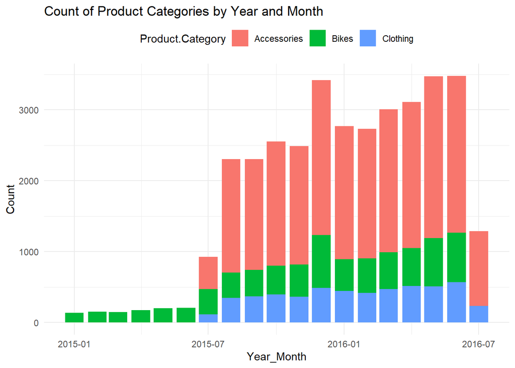

```r
ggplot(sales, aes(x = Year_Month, fill = Product.Category)) +
  geom_bar() +
  labs(title = "Count of Product Categories by Year and Month", x = "Year_Month", y = "Count") +
  theme_minimal() +
  theme(legend.position = "top")
```

Let’s check for insights from Sub category and Year_Month.

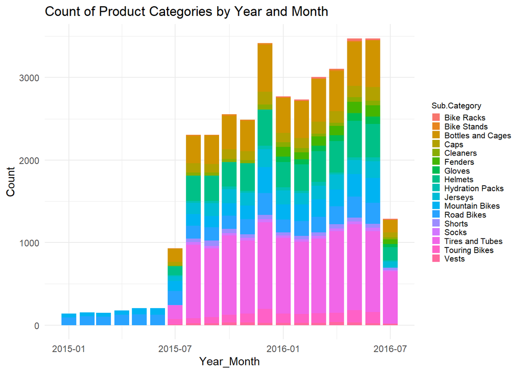

```r
ggplot(sales, aes(x = Year_Month, fill = Sub.Category)) +
  geom_bar() +
  labs(title = "Count of Product Categories by Year and Month", x = "Year_Month", y = "Count") +
  theme_minimal() +
  theme(legend.text = element_text(size = 8),
        legend.title = element_text(size = 8),
        legend.key.size = unit(0.3, "cm"))
```

Let’s see in which year_month most of the revenue is generated.

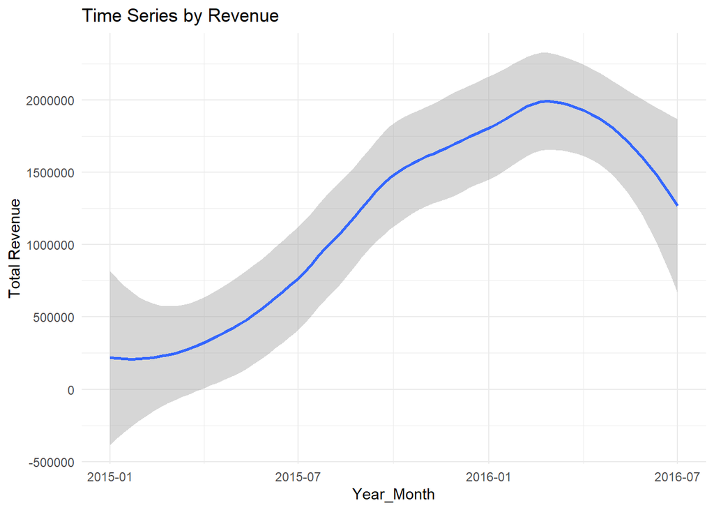

```r
total_revenue <- sales %>%
  group_by(Year_Month) %>%
  summarise(Total_Revenue = sum(Revenue, na.rm = TRUE))
ggplot(total_revenue, aes(x = Year_Month, y = Total_Revenue)) +
  geom_smooth(method = 'loess', formula = 'y ~ x') +
  labs(title = "Time Series by Revenue", x = "Year_Month", y = "Total Revenue") +
  theme_minimal()
```

Let’s see which age group people choose which product category.

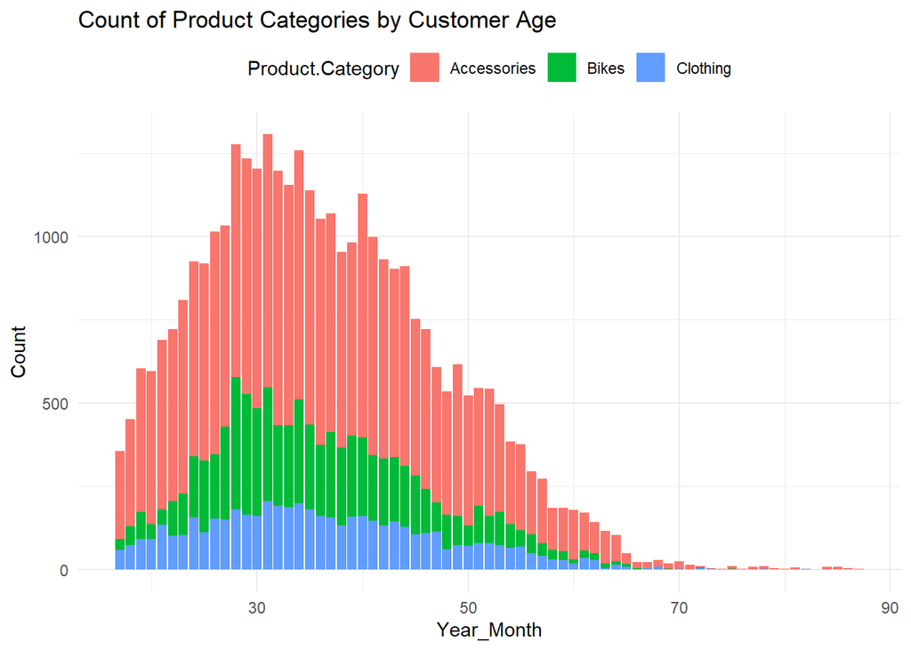

```r
ggplot(sales, aes(x = Customer.Age, fill = Product.Category)) +
  geom_bar() +
  labs(title = "Count of Product Categories by Customer Age", x = "Year_Month", y = "Count") +
  theme_minimal() +
  theme(legend.position = "top")
```

Let’s see which age group people choose which sub category.

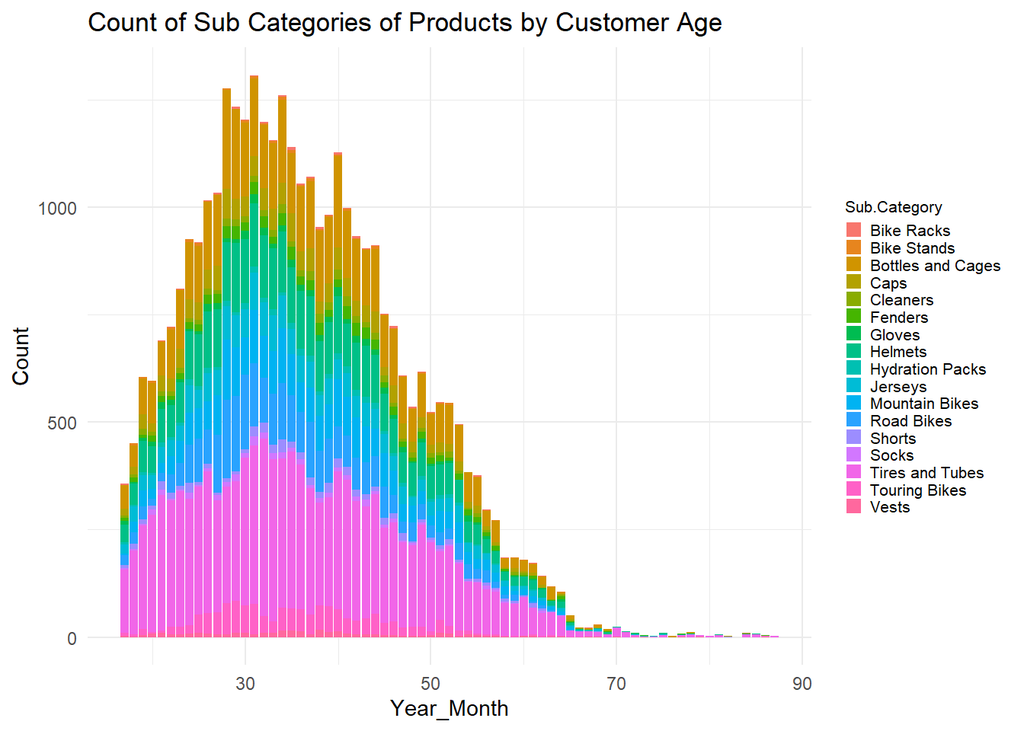

```r
ggplot(sales, aes(x = Customer.Age, fill = Sub.Category)) +
  geom_bar() +
  labs(title = "Count of Sub Categories of Products by Customer Age", x = "Year_Month", y = "Count") +
  theme_minimal() +
  theme(legend.text = element_text(size = 8),
        legend.title = element_text(size = 8),
        legend.key.size = unit(0.3, "cm"))
```

Let’s see from which group of people most of the revenue was generated.

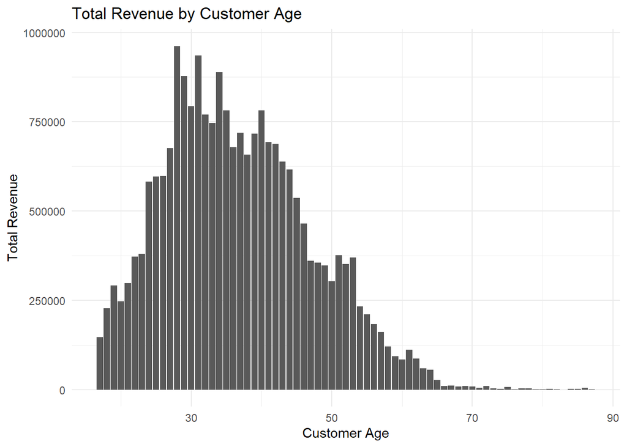

```r
total_revenue <- aggregate(Revenue ~ Customer.Age, data = sales, sum)
ggplot(total_revenue, aes(x = Customer.Age, y = Revenue)) +
  geom_bar(stat = "identity") +
  labs(title = "Total Revenue by Customer Age", x = "Customer Age", y = "Total Revenue") +
  theme_minimal()
```

Let’s see which gender of the customer choose which product category.

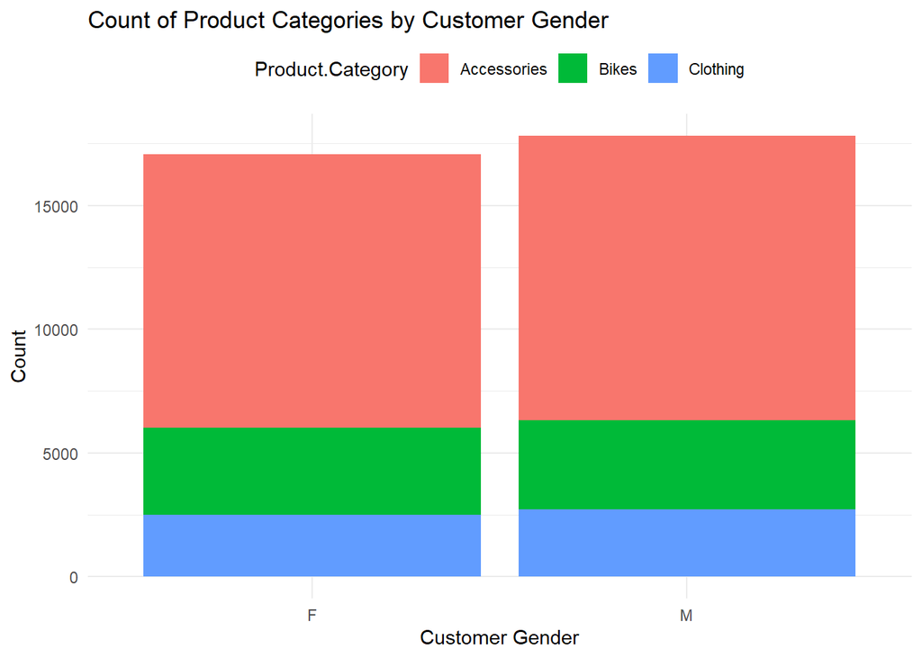

```r
ggplot(sales, aes(x = Customer.Gender, fill = Product.Category)) +
  geom_bar() +
  labs(title = "Count of Product Categories by Customer Gender", x = "Customer Gender", y = "Count") +
  theme_minimal() +
  theme(legend.position = "top")
```

Let’s see which gender of the customer choose which sub category.

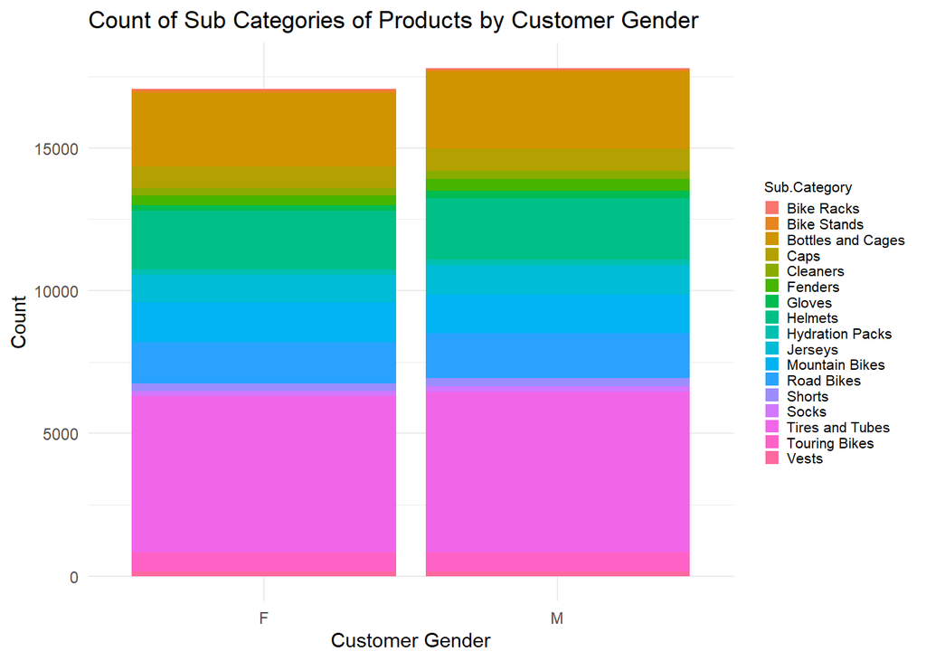

```r
ggplot(sales, aes(x = Customer.Gender, fill = Sub.Category)) +
  geom_bar() +
  labs(title = "Count of Sub Categories of Products by Customer Gender", x = "Customer Gender", y = "Count") +
  theme_minimal() +
  theme(legend.text = element_text(size = 8),
        legend.title = element_text(size = 8),
        legend.key.size = unit(0.3, "cm"))
```

Let’s see which country choose which product category and have the most revenue generated from it.

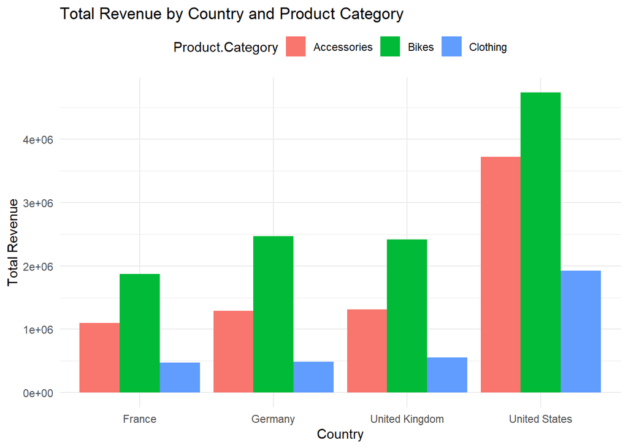

```r
total_revenue <- sales %>%
  group_by(Country, Product.Category) %>%
  summarise(Total_Revenue = sum(Revenue, na.rm = TRUE), .groups = "drop")
ggplot(total_revenue, aes(x = Country, y = Total_Revenue, fill = Product.Category)) +
  geom_col(position = "dodge") +
  labs(title = "Total Revenue by Country and Product Category",
       x = "Country",
       y = "Total Revenue") +
  theme_minimal() +
  theme(legend.position = "top")
```

Now let’s check for the same insights but with sub category.

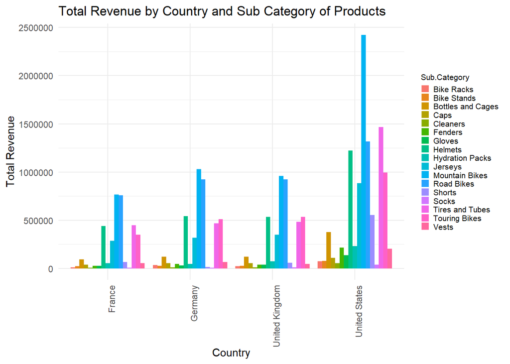

```r
total_revenue <- sales %>%
  group_by(Country, Sub.Category) %>%
  summarise(Total_Revenue = sum(Revenue, na.rm = TRUE), .groups = "drop")
ggplot(total_revenue, aes(x = Country, y = Total_Revenue, fill = Sub.Category)) +
  geom_col(position = "dodge") +
  labs(title = "Total Revenue by Country and Sub Category of Products",
       x = "Country",
       y = "Total Revenue") +
  theme_minimal() +
  theme(legend.text = element_text(size = 8),
        legend.title = element_text(size = 8),
        legend.key.size = unit(0.3, "cm")) +
  theme(axis.text.x = element_text(angle = 90, hjust = 1))
```

Let’s see which state of the country France got the revenue generated.

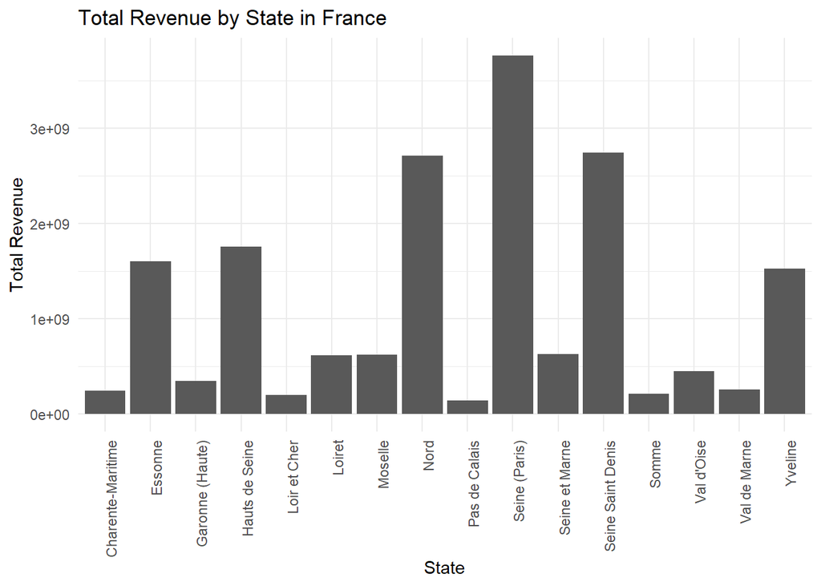

```r
filtered_sales <- subset(sales, Country == "France")
ggplot(filtered_sales, aes(x = State, y = sum(Revenue))) +
  geom_bar(stat = "identity") +
  labs(title = "Total Revenue by State in France", x = "State", y = "Total Revenue") +
  theme_minimal() +
  theme(axis.text.x = element_text(angle = 90, hjust = 1))
```

Let’s check for the same insights for the states of Germany.

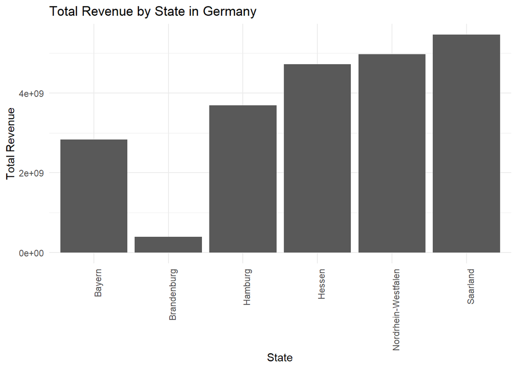

```r
filtered_sales <- subset(sales, Country == "Germany")
ggplot(filtered_sales, aes(x = State, y = sum(Revenue))) +
  geom_bar(stat = "identity") +
  labs(title = "Total Revenue by State in Germany", x = "State", y = "Total Revenue") +
  theme_minimal() +
  theme(axis.text.x = element_text(angle = 90, hjust = 1))
```

Let’s check for the same insights but for both UK and USA because there is only one state from UK.

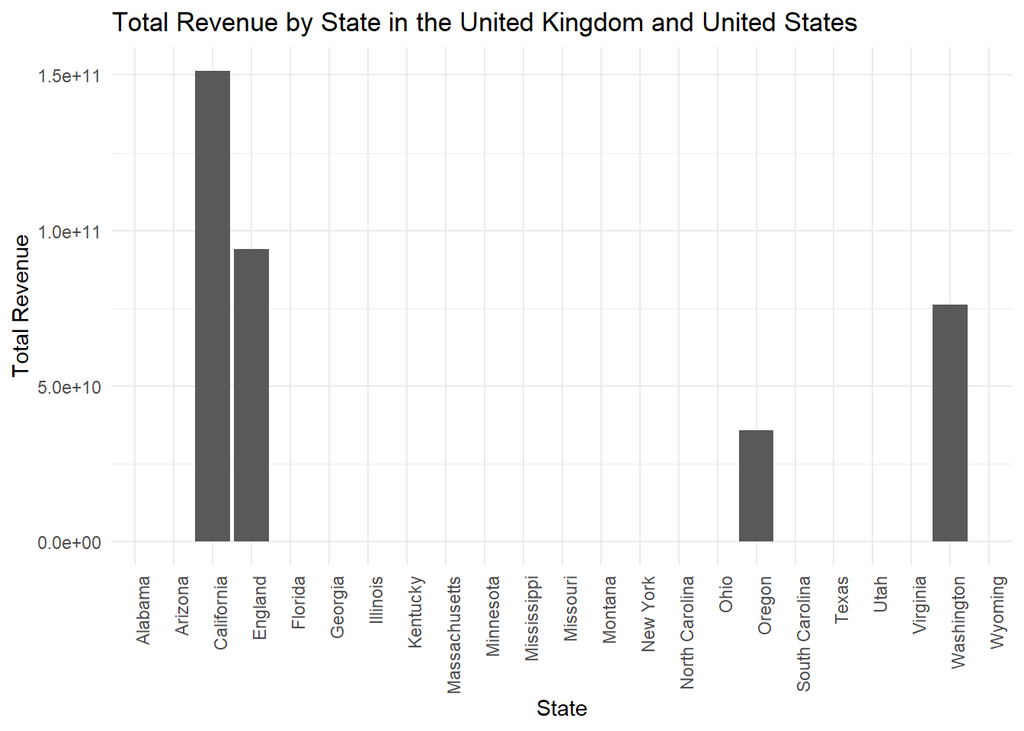

```r
filtered_sales <- subset(sales, Country %in% c("United Kingdom", "United States"))
ggplot(filtered_sales, aes(x = State, y = sum(Revenue))) +
  geom_bar(stat = "identity") +
  labs(title = "Total Revenue by State in the United Kingdom and United States", x = "State", y = "Total Revenue") +
  theme_minimal() +
  theme(axis.text.x = element_text(angle = 90, hjust = 1))
```

Let’s check for revenue distribution of prouct category in percentage values.

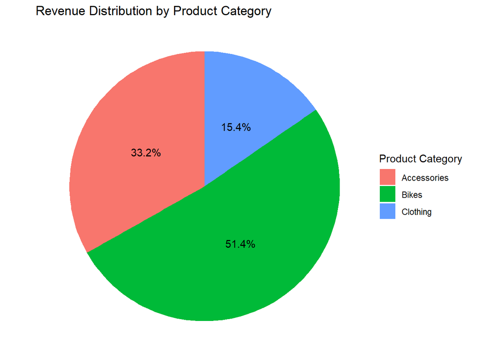

```r
total_revenue <- sales %>%
  group_by(Product.Category) %>%
  summarise(Total_Revenue = sum(Revenue, na.rm = TRUE))
total_revenue$Percentage <- total_revenue$Total_Revenue / sum(total_revenue$Total_Revenue) * 100
ggplot(total_revenue, aes(x = "", y = Total_Revenue, fill = Product.Category)) +
  geom_bar(stat = "identity") +
  coord_polar(theta = "y") +
  geom_text(aes(label = paste0(round(Percentage, 1), "%")), position = position_stack(vjust = 0.5)) +
  labs(title = "Revenue Distribution by Product Category", fill = "Product Category") +
  theme_void()
```

Let’s check for same insights but for sub category.

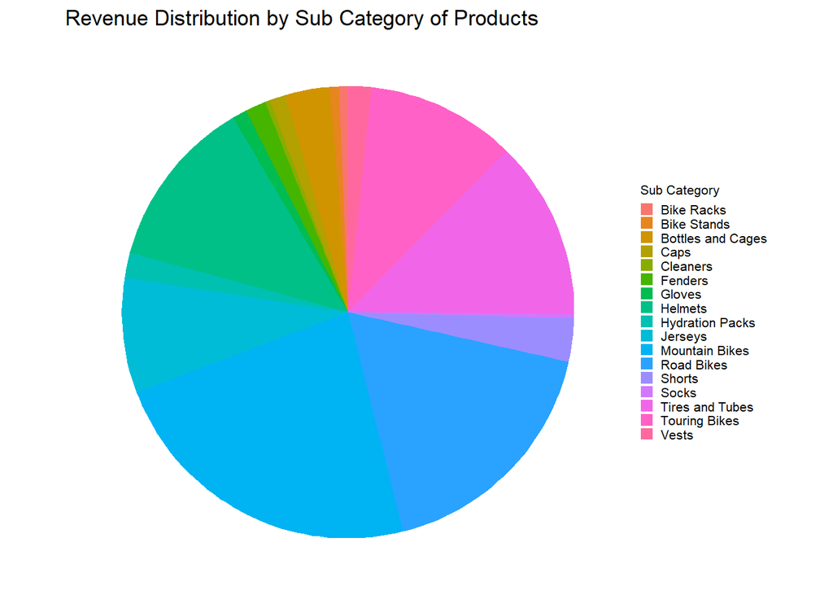

```r
total_revenue <- sales %>%
  group_by(Sub.Category) %>%
  summarise(Total_Revenue = sum(Revenue, na.rm = TRUE))
total_revenue$Percentage <- total_revenue$Total_Revenue / sum(total_revenue$Total_Revenue) * 100
ggplot(total_revenue, aes(x = "", y = Total_Revenue, fill = Sub.Category)) +
  geom_bar(stat = "identity") +
  coord_polar(theta = "y") +
  labs(title = "Revenue Distribution by Sub Category of Products", fill = "Sub Category") +
  theme_void() +
  theme(legend.text = element_text(size = 8),
        legend.title = element_text(size = 8),
        legend.key.size = unit(0.3, "cm"))
```

Let’s check which product category was should in most quantity.

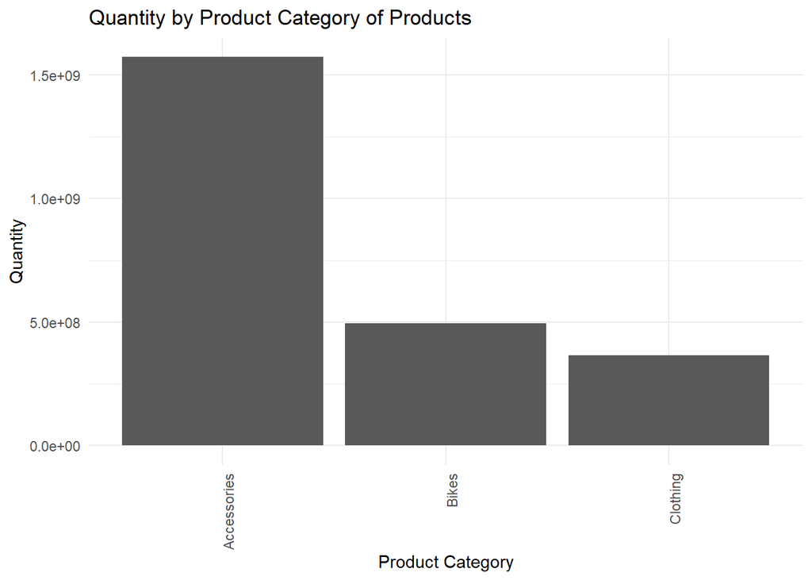

```r
ggplot(sales, aes(x = Product.Category, y = sum(Quantity))) +
  geom_bar(stat = "identity") +
  labs(title = "Quantity by Product Category of Products", x = "Product Category", y = "Quantity") +
  theme_minimal() +
  theme(axis.text.x = element_text(angle = 90, hjust = 1))
```

Let’s check for same insights but for sub category.

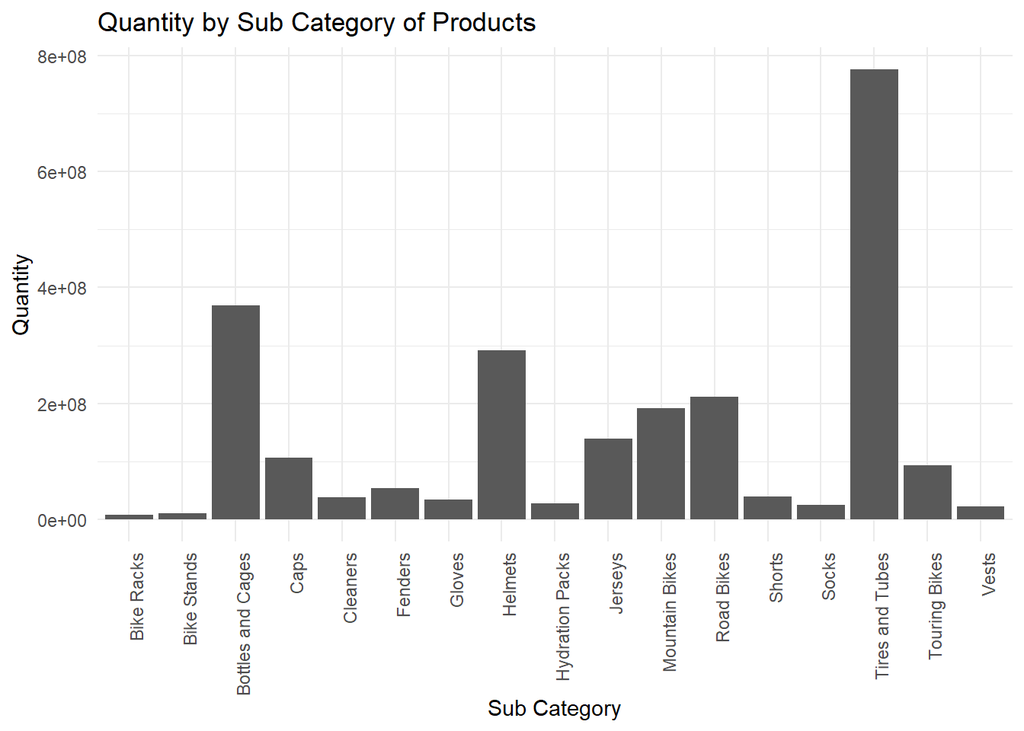

```r
ggplot(sales, aes(x = Sub.Category, y = sum(Quantity))) +
  geom_bar(stat = "identity") +
  labs(title = "Quantity by Sub Category of Products", x = "Sub Category", y = "Quantity") +
  theme_minimal() +
  theme(axis.text.x = element_text(angle = 90, hjust = 1))
```

Let’s check for product category distribution by quantity and revenue.

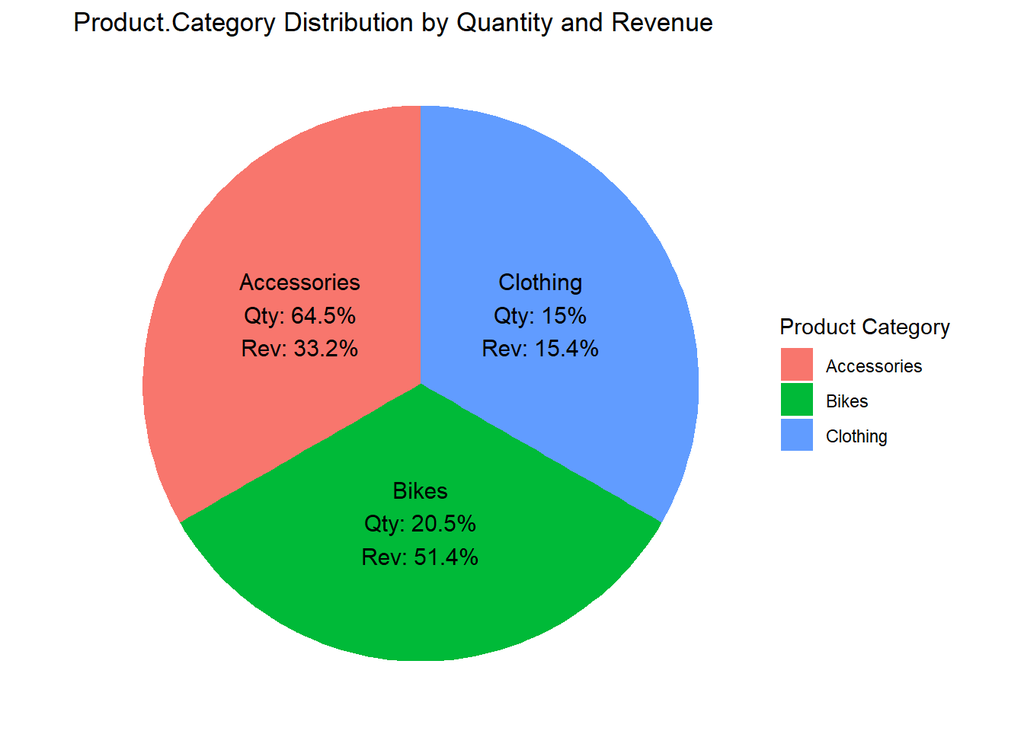

```r
total_data <- sales %>%
  group_by(Product.Category) %>%
  summarise(Total_Quantity = sum(Quantity, na.rm = TRUE),
            Total_Revenue = sum(Revenue, na.rm = TRUE))
total_data$Percentage_Quantity <- total_data$Total_Quantity / sum(total_data$Total_Quantity) * 100
total_data$Percentage_Revenue <- total_data$Total_Revenue / sum(total_data$Total_Revenue) * 100
ggplot(total_data, aes(x = "", y = 1, fill = Product.Category)) +
  geom_bar(stat = "identity", width = 1) +
  geom_text(aes(label = paste0(Product.Category, "\n",
                               "Qty: ", round(Percentage_Quantity, 1), "%\n",
                               "Rev: ", round(Percentage_Revenue, 1), "%")),
            position = position_stack(vjust = 0.5),
            size = 4) +
  coord_polar(theta = "y") +
  labs(title = "Product.Category Distribution by Quantity and Revenue",
       fill = "Product Category") +
  theme_void()
```

Let’s check for same insights but for sub category.

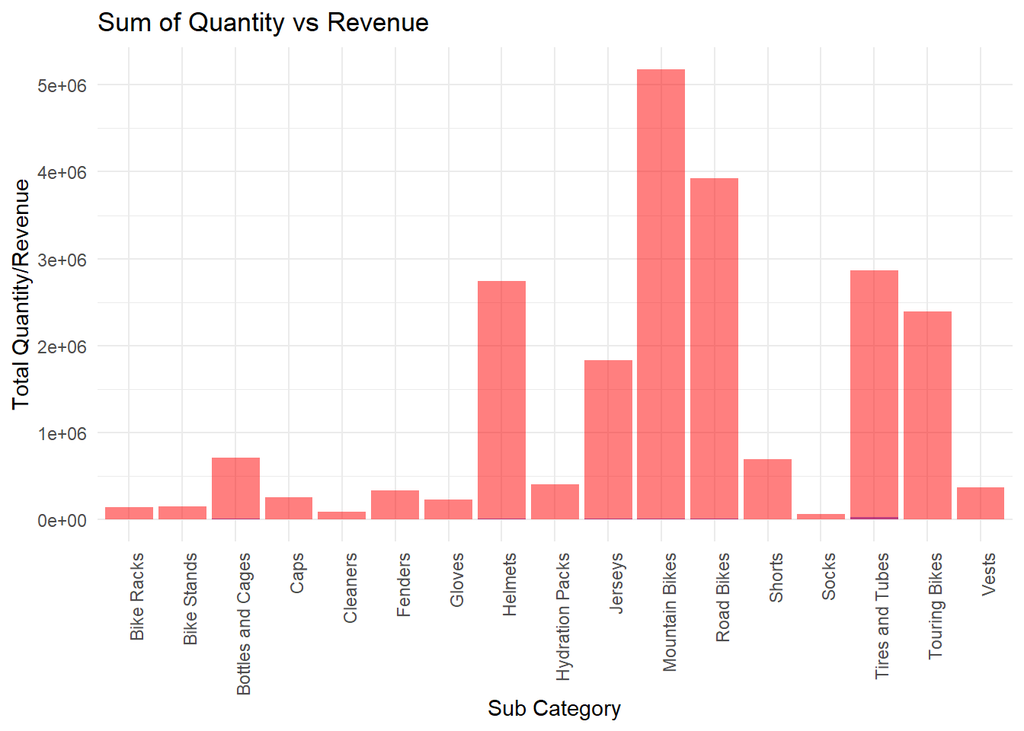

```r
total_data <- sales %>%
  group_by(Sub.Category) %>%
  summarise(Total_Quantity = sum(Quantity, na.rm = TRUE),
            Total_Revenue = sum(Revenue, na.rm = TRUE))
ggplot(total_data, aes(x = Sub.Category)) +
  geom_col(aes(y = Total_Quantity), fill = "blue", alpha = 0.5) +
  geom_col(aes(y = Total_Revenue), fill = "red", alpha = 0.5) +
  labs(title = "Sum of Quantity vs Revenue",
       x = "Sub Category",
       y = "Total Quantity/Revenue") +
  theme_minimal() +
  theme(legend.text = element_text(size = 8),
        legend.title = element_text(size = 8),
        axis.text.x = element_text(angle = 90, hjust = 1))
```

Let’s check which product category cost less and sold for more amount.

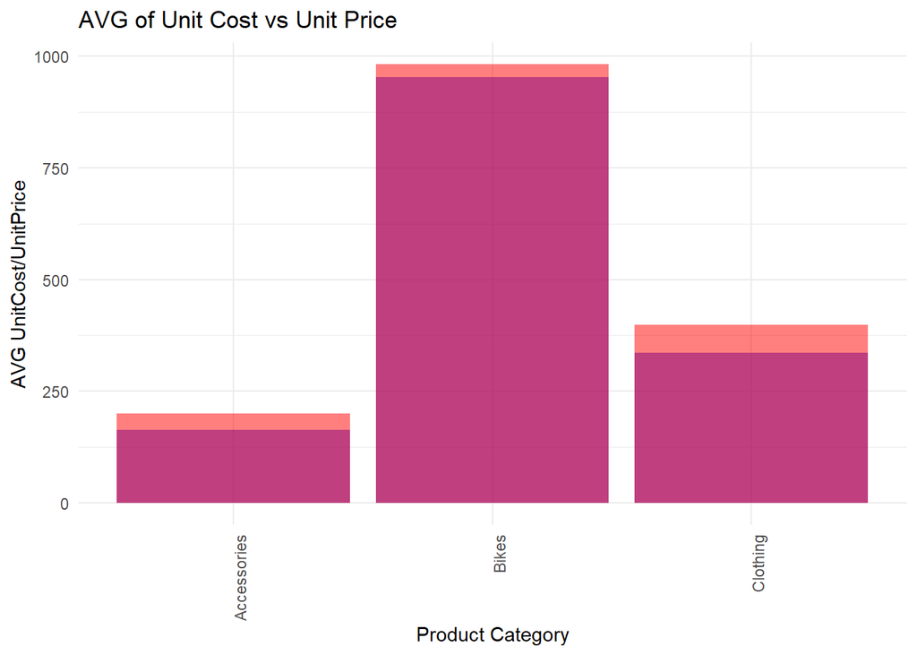

```r
total_data <- sales %>%
  group_by(Product.Category) %>%
  summarise(Mean_Cost = mean(Unit.Cost, na.rm = TRUE),
            Mean_Price = mean(Unit.Price, na.rm = TRUE))
ggplot(total_data, aes(x = Product.Category)) +
  geom_col(aes(y = Mean_Cost), fill = "blue", alpha = 0.5) +
  geom_col(aes(y = Mean_Price), fill = "red", alpha = 0.5) +
  labs(title = "AVG of Unit Cost vs Unit Price",
       x = "Product Category",
       y = "AVG UnitCost/UnitPrice") +
  theme_minimal() +
  theme(legend.text = element_text(size = 8),
        legend.title = element_text(size = 8),
        axis.text.x = element_text(angle = 90, hjust = 1))
```

Let’s check for same insights but for sub category.

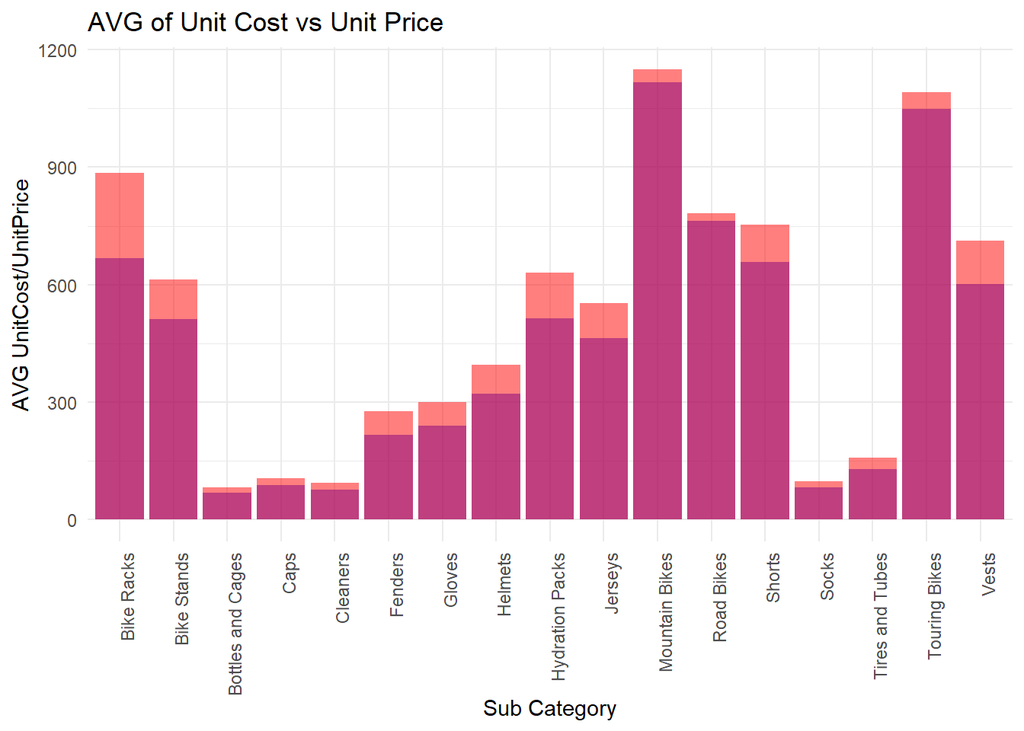

```r
total_data <- sales %>%
  group_by(Sub.Category) %>%
  summarise(Mean_Cost = mean(Unit.Cost, na.rm = TRUE),
            Mean_Price = mean(Unit.Price, na.rm = TRUE))
ggplot(total_data, aes(x = Sub.Category)) +
  geom_col(aes(y = Mean_Cost), fill = "blue", alpha = 0.5) +
  geom_col(aes(y = Mean_Price), fill = "red", alpha = 0.5) +
  labs(title = "AVG of Unit Cost vs Unit Price",
       x = "Sub Category",
       y = "AVG UnitCost/UnitPrice") +
  theme_minimal() +
  theme(legend.text = element_text(size = 8),
        legend.title = element_text(size = 8),
        axis.text.x = element_text(angle = 90, hjust = 1))
```

Let’s compare the average of cost and revenue by product category.

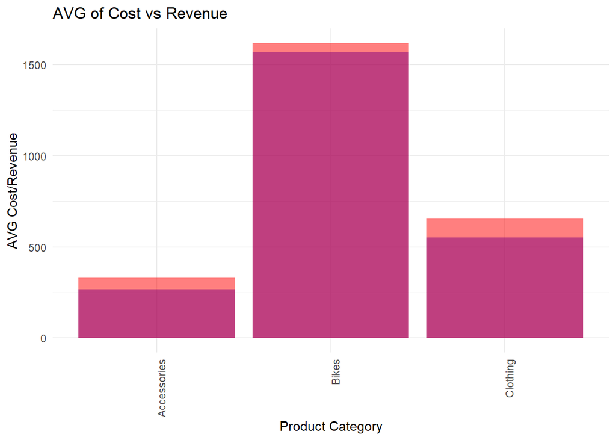

```r
total_data <- sales %>%
  group_by(Product.Category) %>%
  summarise(Mean_Cost = mean(Cost, na.rm = TRUE),
            Mean_Revenue = mean(Revenue, na.rm = TRUE))
ggplot(total_data, aes(x = Product.Category)) +
  geom_col(aes(y = Mean_Cost), fill = "blue", alpha = 0.5) +
  geom_col(aes(y = Mean_Revenue), fill = "red", alpha = 0.5) +
  labs(title = "AVG of Cost vs Revenue",
       x = "Product Category",
       y = "AVG Cost/Revenue") +
  theme_minimal() +
  theme(legend.text = element_text(size = 8),
        legend.title = element_text(size = 8),
        axis.text.x = element_text(angle = 90, hjust = 1))
```

Let’s check for the same insights but for sub category.

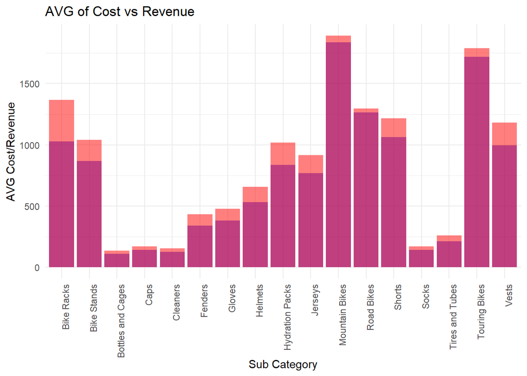

```r
total_data <- sales %>%
  group_by(Sub.Category) %>%
  summarise(Mean_Cost = mean(Cost, na.rm = TRUE),
            Mean_Revenue = mean(Revenue, na.rm = TRUE))
ggplot(total_data, aes(x = Sub.Category)) +
  geom_col(aes(y = Mean_Cost), fill = "blue", alpha = 0.5) +
  geom_col(aes(y = Mean_Revenue), fill = "red", alpha = 0.5) +
  labs(title = "AVG of Cost vs Revenue",
       x = "Sub Category",
       y = "AVG Cost/Revenue") +
  theme_minimal() +
  theme(legend.text = element_text(size = 8),
        legend.title = element_text(size = 8),
        axis.text.x = element_text(angle = 90, hjust = 1))
```

Let’s check for the country with most unit margin.

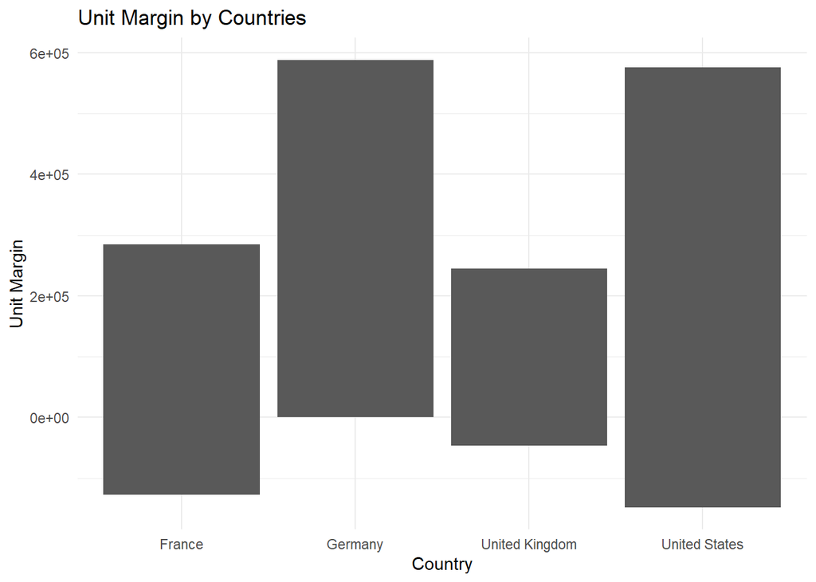

```r
ggplot(sales, aes(x = Country, y = Unit_Margin)) +
  geom_bar(stat = "identity") +
  labs(title = "Unit Margin by Countries", x = "Country", y = "Unit Margin") +
  theme_minimal()
```

Let’s check for the country with most unit margin percentage.

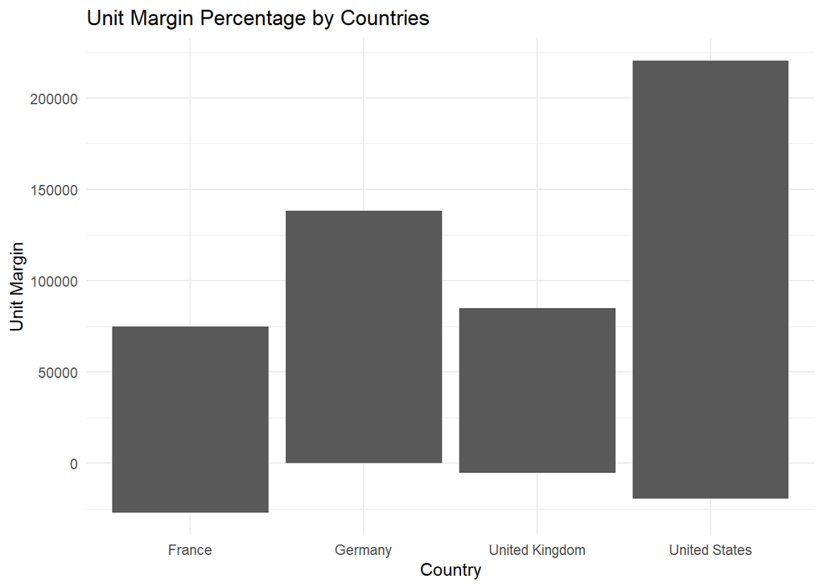

```r
ggplot(sales, aes(x = Country, y = Unit_Margin_percent)) +
  geom_bar(stat = "identity") +
  labs(title = "Unit Margin Percentage by Countries", x = "Country", y = "Unit Margin") +
  theme_minimal()
```

Let’s check for the country with most margin and margin percentage.

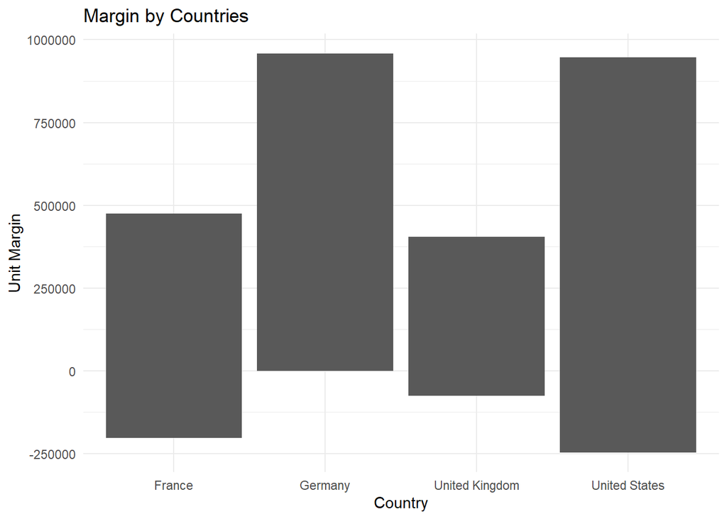

```r
ggplot(sales, aes(x = Country, y = Margin)) +
  geom_bar(stat = "identity") +
  labs(title = "Margin by Countries", x = "Country", y = "Unit Margin") +
  theme_minimal()
```

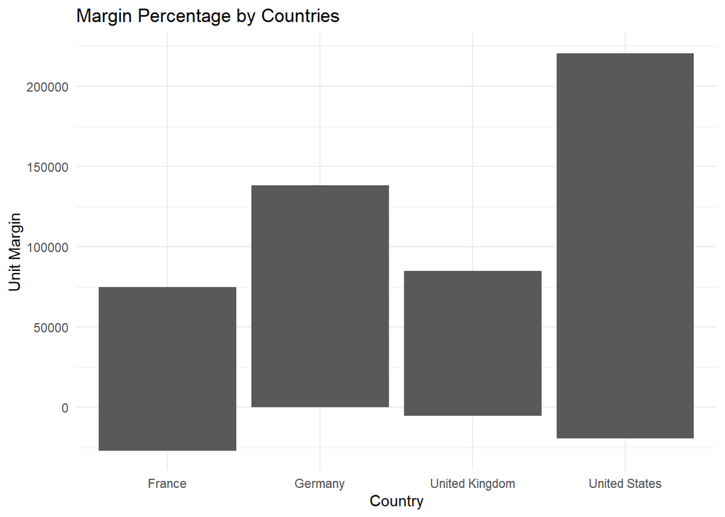

```r
ggplot(sales, aes(x = Country, y = Margin_percent)) +
  geom_bar(stat = "identity") +
  labs(title = "Margin Percentage by Countries", x = "Country", y = "Unit Margin") +
  theme_minimal()
```

Let’s check which product category has the most unit margin, unit margin percentage, margine and margine percentage.

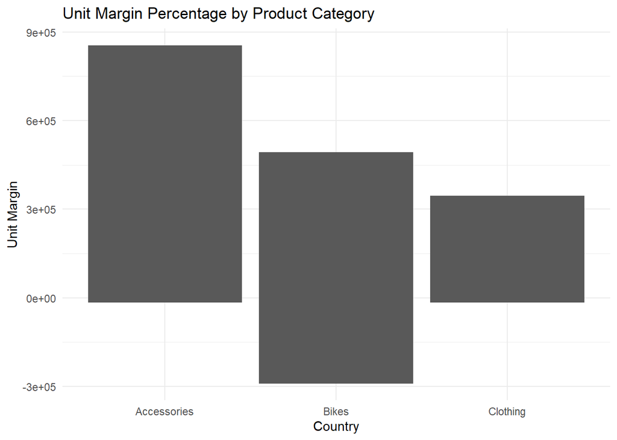

```r
ggplot(sales, aes(x = Product.Category, y = Unit_Margin)) +
  geom_bar(stat = "identity") +
  labs(title = "Unit Margin Percentage by Product Category", x = "Country", y = "Unit Margin") +
  theme_minimal()
```

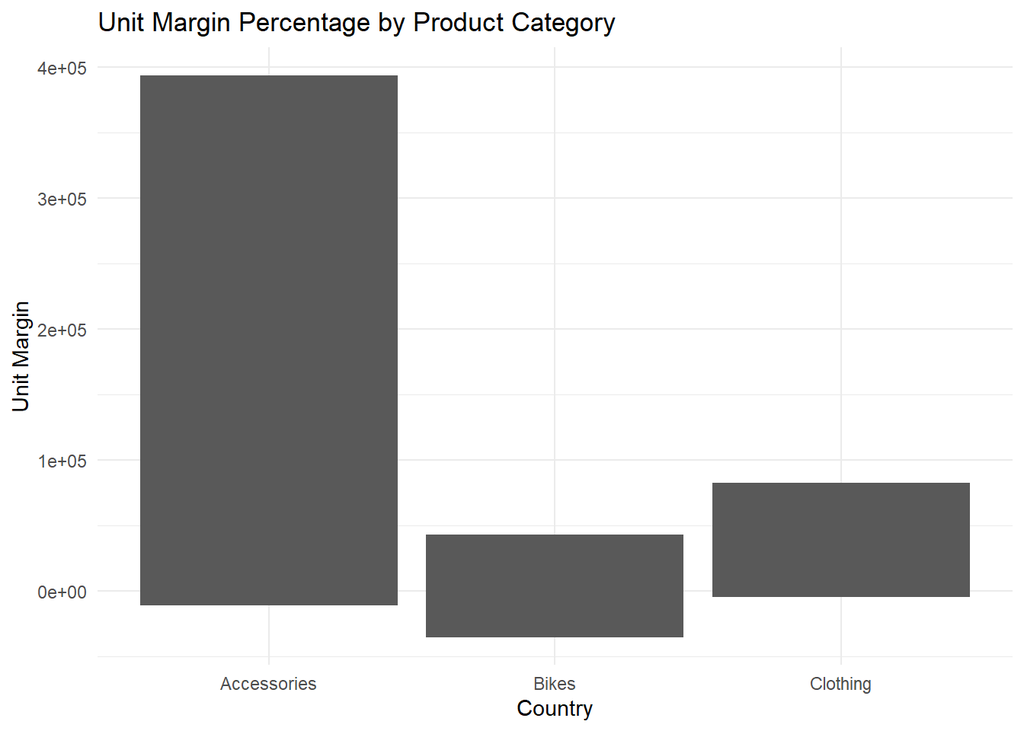

```r
ggplot(sales, aes(x = Product.Category, y = Unit_Margin_percent)) +
  geom_bar(stat = "identity") +
  labs(title = "Unit Margin Percentage by Product Category", x = "Country", y = "Unit Margin") +
  theme_minimal()
```